# No Gut Feelings Bank: positioning the balance sheet for the macro cycle

The public edition: what each macro outcome does to the balance sheet, how to reposition against the market, and how to measure the bank against its peers, with public SARB data

Author

Rossouw van Jaarsveld

Published

3 November 2026

R1,431 bn

NGFB total assets at 2026Q2, 15.5% of the reported sector

13.2%

NGFB baseline ROE, three-year average; net income R46.3 bn over three years

10.7% – 14.8%

NGFB ROE from the downside to the upside (net income R36.7 bn to R52.4 bn)

+21 bps

ROE recovered by positioning before the downside (+R849 m of net income); -48 bps if the upside arrives instead

-265 bps

NGFB baseline ROE once the hedge is priced off actual swap rates instead of a government-curve proxy

+202 bps

probability-weighted ROE from three further levers: ten-year hedge reinvestment, HQLA duration, excess capital returned

+290 bps

average ROE added across 61 historical macro episodes by seven macro-keyed rules stacked without a risk budget, at 20% of CET1 more EVE risk

+213 bps

average ROE added across the episodes by the risk-budgeted portfolio, beating the plan in every one, within 5% of CET1 of EVE risk and every capital and liquidity floor

+1.3 bps

baseline ROE effect of pricing off compounded ZARONIA + 16.19 bp after JIBAR’s last fixing; -32 bps if floating-rate borrowers negotiate the spread away

# 1 Summary

**No Gut Feelings Bank (NGFB)** is a fictional South African bank, the size of the average of the six largest banks: R1,431 bn of assets, or 15.5% of the BA900 sector at 2026Q2. It inherits its deposit franchise and structural hedge from the earlier NGFB posts, takes its asset mix from a draw on the six-bank population, and is added to the South African banking sector so that it competes for market share with real peer groups. This report asks four questions of it: *what does a macro scenario do to NGFB’s returns and earnings; how should the balance sheet be positioned before the scenario arrives; where, commercially, should NGFB grow through the cycle; and how should its performance be judged, given the macro environment?*

Those questions are the three everyday jobs a bank’s macro model can do beyond the annual stress test: say **what to expect** from every part of the balance sheet in each scenario, show **how to reposition** (ahead of a scenario, with levers that need no view, and commercially against the market), and judge **how the bank measures up** against its market and its peers once the macro tide is taken out. The question and the design sets them out; the rest of the report answers them.

The framework works top down. Macro variables are tied first to the **banking industry** (Stage 1: 22 sector models of volumes, spreads, deposit costs, credit losses, fees and costs), and only then is a bank tied to the **industry** (Stage 2: market-share dynamics by macro regime, pooled across banks). A quarterly engine turns the result into net interest income, credit losses, capital, liquidity, net income and ROE; an optimiser translates “scenario X is coming” into balance-sheet moves; and a risk-budgeted optimiser sets the treasury levers – the structural hedge, the liquidity book and the payout – together, across sixty historical macro paths and inside limits on earnings, capital, liquidity and interest-rate risk.

What it finds:

1. **Three scenarios.** Over the next three years NGFB’s ROE averages 13.2% in the **baseline** (net income R46.3 bn, about R15.4 bn a year), 14.8% in the **upside** (faster disinflation and a growth dividend; +R6.1 bn of net income) and 10.7% in the **downside** (a stagflationary shock with SARB hikes and a two-year contraction; -R9.6 bn).
2. **NGFB earns less than the industry, and moves against it.** NGFB’s ROE sits below the sector’s (15.7% in the baseline) because its unsecured-heavy book carries higher credit losses; its structural hedge adds 144 bps in the baseline. The unhedged industry gains from higher rates and loses from lower ones, so its ROE barely moves in the downside (+17 bps) and falls in the upside (-14 bps). NGFB’s hedge gives that rate exposure away: in the downside it loses 253 bps, 168 bps through credit losses and 93 bps through pricing, because the hedge more than offsets its deposit endowment (a 100 bps higher repo path costs hedged NGFB 21 bps of ROE and would add 130 bps unhedged).
3. **Credit is the largest single exposure.** GDP growth one point lower for three years costs 67 bps of ROE (R2,566 m of net income), almost all through credit losses.
4. **Positioning before the downside** cuts the receive-fixed hedge from 49.6% to 40.3% of non-maturity deposits, swaps 0.53% of assets of wholesale funding for retail deposits and trims unsecured lending by 0.46% of assets. It recovers 21 bps of ROE (R849 m of net income over three years) if the downside comes, and costs 21 bps if the baseline does and 48 bps if the upside does. **Before the upside** the moves reverse: extend the hedge to 55.8% and lean into unsecured lending (+9 bps if it comes).
5. **Being more aggressive moves the numbers more, in both directions.** Doubling the optimal moves at the same execution cost wipes out the gain even if the downside arrives and loses 138 bps if the upside does. A bank that can execute four times more cheaply can make 75 bps from the same view, but stands to lose 126 bps if it is wrong. The loss if wrong grows faster than the gain if right.
6. **The downside’s key judgement is the SARB’s response.** If the same contraction came with rate cuts (as in 2009 and 2020), the hedge would be NGFB’s protection rather than its cost, and the optimal hedge move flips sign (+9.1 instead of -9.2 points of NMD); cutting unsecured lending is right in both.
7. **The hedge was priced off the wrong curve, and is corrected.** The hedge’s swap rates came from a proxy inside the government curve that overstated actual ZAR swap rates by 0.3–2.0 pp, because South African bonds carry a fiscal premium over swaps. Priced off actual swap fixings, the hedge book’s fixed rate falls from 8.87% to 7.60%, and NGFB’s ROE by 265 bps in the baseline (R10.4 bn of net income over three years). Against a published bank’s NII sensitivity (3.5% of NII for 100 bps), unhedged NGFB is asset-sensitive (+6.4% for +100 bps) and hedged NGFB liability-sensitive (-1.2%): its hedge is large for deposits that reprice as fast as Stage 1 finds, and the rate-neutral ratio is 37% of non-maturity deposits, not 49.6%. Funding spreads show no macro relationship beyond the repricing lag.
8. **JIBAR’s cessation is now in the model, and it is level-neutral by design.** JIBAR is published until 31 December 2026 and new JIBAR contracts have been barred since 1 May 2026, so 10 of the twelve projected quarters are priced off its successor: compounded ZARONIA plus the 16.19 bp fallback spread, for floating-rate loans, wholesale funding and the hedge’s floating leg (cleared swaps convert to ZARONIA on 20–21 November with the spread on the floating leg). Because the spread is the long-run median of the JIBAR–ZARONIA basis, ROE moves by +1.3 bps. What changes is risk: the basis no longer floats in a stress, and if borrowers negotiate the 16.19 bp away when loans are re-papered, NGFB loses up to 32 bps of ROE.
9. **More levers pay than the balance-sheet mix.** Run through the engine in every scenario, a quarter of HQLA in ten-year government bonds adds 96 bps of probability-weighted ROE, earning the curve’s fiscal term premium at the cost of up to 1.1 pp of CET1 through OCI at the downside’s peak; reinvesting maturing hedge tranches at ten years instead of five adds 69 bps (the swap curve’s term premium, with 83% more PV01); returning capital above a 12.5% CET1 adds 30 bps; and passing rate rises to non-maturity deposits more slowly and cuts faster is worth up to 36 bps, an upper bound that ignores the volume response. The first three together add 202 bps and keep CET1 above the floor in every scenario, as long as the bonds are not marked through OCI: at fair value the downside’s peak would take CET1 to 10.9%, below the 11.5% floor. Two levers need no rate view at all: a quarter of the buffer in five-year bonds asset-swapped to floating collects the fiscal premium without the duration (+37 bps to +39 bps in every scenario, with no EVE risk and a fraction of the OCI risk), and releasing surplus Treasury bills to repay wholesale funding saves about nine basis points per R10 bn (+71 bps at an LCR of 160%, still far above the floor). The hedge ratio, by contrast, is a pure rate view: each ten points of non-maturity deposits received fixed adds 26 bps in the baseline and costs 12 bps in the downside (More levers).
10. **Across sixty historical macro episodes, the term premium, the curve’s slope and the spreads pay; timing the rate cycle does not.** Replayed from today’s starting point, every twelve-quarter episode since 2008 gives NGFB’s plan an average ROE of 12.8% (5th percentile 11.1%), and it earns its 14.5% cost of equity in only 1 of 61. Reinvesting the hedge at ten years adds +69 bps and beats the plan in every episode; holding HQLA duration in proportion to the government curve’s slope adds +138 bps, with a better capital trough than a fixed bond holding, though it gives some back through realised losses in hiking cycles; asset-swapped bonds (+38 bps) and a smaller buffer (+49 bps) beat the plan in every episode with no rate risk; a payout that follows growth and capital adds a little and raises the CET1 trough; a hedge ratio keyed on the level of rates adds nothing, though hindsight would have been worth +165 bps. Seven such rules stacked together add +290 bps, but at 20% of CET1 more EVE sensitivity to a 200 bps rise and with the CET1 trough at fair value down to 11.51% (Strategy lab).
11. **Chosen together under a risk budget, the levers add +213 bps across the histories, with every limit met.** A risk-budgeted optimiser scores all 25,200 combinations of the hedge ratio and tenor, the liquidity book (ten-year bonds, asset swaps, the buffer’s size) and the payout across the episodes, and keeps the best whose 5th-percentile ROE is no worse than the plan’s, whose CET1 at fair value stays above 11.5%, whose LCR and NSFR stay above their floors and whose change in EVE for ±200 bps stays within 5% of CET1. It keeps the hedge at the rate-neutral 37% reinvested at 7 years, puts 12.5% of earning HQLA in ten-year bonds and 50% in asset-swapped bonds, cuts the buffer to an LCR of 160% and pays out by R4: NGFB’s average ROE rises from 12.8% to 15.0% and it beats the plan in every episode. Two thirds of the gain is the two spread trades, which pay the same in every macro regime; the rest moves duration from swaps into bonds, so that the hedge and the bonds offset each other across the rate cycle. Of the macro rules only the payout rule survives the budget; the others are better used as risk triggers (Choosing the levers together). One lever was missing: the balance sheet’s own size. Asset-swapped government bonds funded in repo outside the buffer add about 10 bps of ROE per R25 bn; the leverage ratio does not stop them, the stagflationary downside does, at R50bn (+20 bps), and they need a credit-spread limit of their own (Using the balance sheet itself).
12. **NGFB under-participates in easing cycles.** When rates fall, the card, corporate-loan and vehicle-finance markets grow fastest and NGFB’s share of each falls, the card share going to the Challengers. Pushing cards pays even on wholesale funding; corporate lending clears the bar only narrowly on wholesale funding and vehicle finance barely at all, but both pay comfortably if they bring their own deposits. In a contraction NGFB *gains* card share while the market stalls, a guard case: the extra book pays only if it loses no more than 0.7 pp a year above the average card loss rate.
13. **Macro-adjusted scorecards separate the tide from the swimming.** Against the large-bank population, NGFB is near the frontier in cards in the downside (78% percentile) but below par in home loans (34%), because a typical large bank gains mortgage share in a contraction; in the upside it is below par in cards, corporate loans and vehicle finance – exactly where the upside’s growth is.

Finding 11, lever by lever: where the two points of ROE come from.

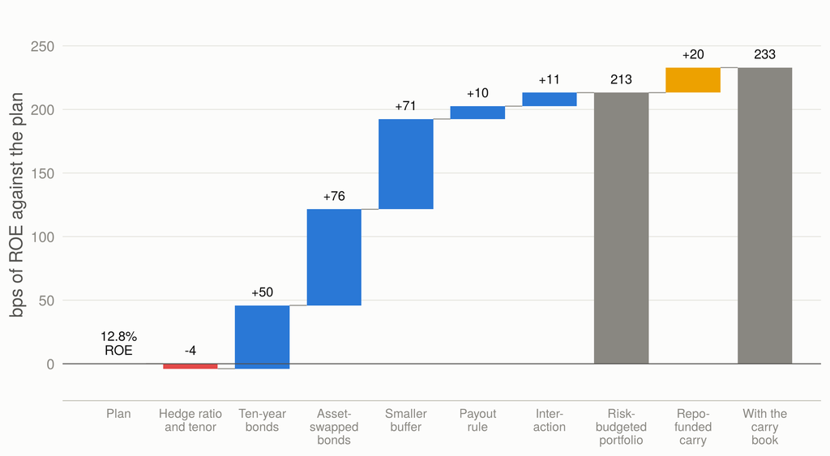

Where two points of ROE come from. Each bar is a lever’s contribution to NGFB’s three-year average ROE against its plan, averaged over the replayed histories, at the central risk budget; the repo-funded carry is the lever the optimiser was missing. The two spread trades (asset-swapped bonds and the smaller buffer) need no view on rates.

Three-year averages (net income: totals), 2026Q3 to 2029Q2. The sector is the BA900 industry run through the same engine without a structural hedge. The downside with cuts is a model-risk variant, not a fourth scenario.

| Scenario | NGFB ROE | vs baseline | NGFB net income, 3 years | vs baseline | NGFB, unhedged ROE | Sector ROE | NGFB NIM | NGFB credit-loss ratio | CET1 trough |
| --- | --- | --- | --- | --- | --- | --- | --- | --- | --- |
| Baseline | 13.2% | +0 bps | R46.3 bn | +R0.0 bn | 11.8% | 15.7% | 3.16% | 1.39% | 12.6% |
| Upside | 14.8% | +157 bps | R52.4 bn | +R6.1 bn | 12.1% | 15.6% | 3.21% | 1.22% | 12.7% |
| Downside | 10.7% | -253 bps | R36.7 bn | -R9.6 bn | 11.1% | 15.9% | 3.04% | 1.62% | 12.4% |
| Downside with cuts | 11.8% | -144 bps | R40.8 bn | -R5.5 bn | 8.5% | 12.8% | 3.17% | 1.58% | 12.7% |

**About this edition**

This is the public edition of the complete technical write-up on No Gut Feelings Bank. It carries every chapter except the industry models’ internals: the Stage 1 models are described in one paragraph, and their specification, estimates and tests, the monthly-frequency comparison and the back-test of the industry models are left out, as is the list of banks in each peer group. No Gut Feelings Bank does not exist. Real banks appear only pooled into peer groups of at least four, and nothing here ranks, names or reverse-engineers an individual institution. Nothing here is financial advice.

# 2 The question and the design

Every quarter an ALCO gets a macro pack (the house view, an upside, a downside, sometimes a scenario the regulator has asked for) and asks the same three questions of it: *how exposed are we*, *what does each scenario do to our returns*, and *what should we do before it arrives*. There is a fourth question that rarely makes the pack, because it is uncomfortable: *what should we do when we do not know which scenario is coming?* Which is always.

Most banks own the machinery to answer them, and point it at something else. Macro models in a bank usually live with the stress-testing team: they turn the regulator’s adverse scenario into a capital ratio for the internal capital adequacy assessment (ICAAP) and supply the forward-looking scenarios behind the IFRS 9 credit provisions. Once a year they prove that the bank survives something unpleasant, and then they go back in the cabinet with the good crockery. That undersells them. A model that can say what a recession does to capital can say what any macro path does to every line of the balance sheet, which makes it useful every quarter, for three jobs a stress test never asks of it:

- **What to expect.** What each economic outcome does to every book, margin and ratio, and so what the card book, the home loans or the deposit franchise can reasonably deliver in each scenario: the scenarios and the sensitivities.
- **How to reposition.** Which balance-sheet and commercial decisions depend on a macro view and which do not, and what each is worth either way: positioning before a scenario, where NGFB should lean in, the further levers, the strategy lab and the risk-budgeted optimiser.
- **How the bank measures up.** A business that grew its book 8% while its market grew 12% lost ground, however well 8% presents at bonus time. Take the market out of each segment’s growth and what is left is what management actually did, and how that compares with competitors: macro-adjusted performance.

Answering any of them from public data needs a chain from macro variables to a bank’s balance sheet. The weak link in most attempts is the last one: a single bank’s history is short, noisy and full of idiosyncratic events (acquisitions, strategy changes, one-off provisions, a curatorship), so regressing a bank’s metrics directly on macro variables tends to produce elasticities that are unstable and sometimes the wrong sign. It is like judging a flyhalf’s form by the rand–dollar exchange rate: there will be a correlation, and you will regret acting on it.

The design here estimates the macro relationships **once, on the industry**, where they are best identified, and then models a bank **relative to the industry**. For any product $p$ the identity

$$g^{\text{bank}}_{p,t} = g^{\text{sector}}_{p,t} + \Delta \log s_{p,t}$$

splits a bank’s growth into the sector’s growth, which Stage 1 explains with macro variables, and the change in its market share, which Stage 2 explains with the macro *regime* and the sector cycle. The macro elasticities the bank inherits are therefore the sector’s; the bank layer only has to say whether the bank gains or loses ground, and when.

Growth $g$ is measured in logs so that the pieces add rather than multiply, and $s_{p,t}$ is the bank’s market share of product $p$ in quarter $t$. The first piece is how fast the whole market grew; the second is how much faster or slower than the market the bank grew, which is exactly the change in its market share. Being an identity, it cannot be wrong. What it does is split one hard problem into two tractable ones: how the industry responds to the economy is where the macro lives, and whether this bank gains or loses ground, and when, is where the bank lives. The same split later judges performance: the first piece is the tide and the second is the swimming.

The chain runs top to bottom. A macro path – one of the scenarios, or one of sixty historical episodes replayed from today – goes through the industry models and NGFB’s share dynamics into a quarterly engine. The engine prices NGFB’s balance sheet under the levers an ALCO sets, each either fixed today or moved by a rule that reads last quarter’s macro data. Every quarter it reports what the levers earn and the risks they take, and the optimiser chooses the levers together inside a risk budget.

One design choice matters for everything that follows. **Nothing in this report forecasts the economy.** Every macro path, whether a scenario or a slice of history, is taken as given, and the only question is what it does to the bank. That is deliberate. An ALCO will argue about which scenario is coming whatever any model says; the model’s job is to make sure everyone is arguing about the same consequences.

On one page, the system and its three uses look like this; the detailed chain from the data to the ALCO decision follows.

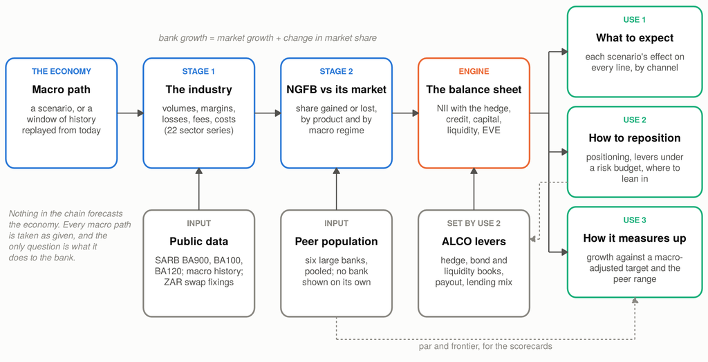

The system on one page. A macro path, either a scenario or a replayed slice of history, runs through the industry models and NGFB’s market-share dynamics into a quarterly engine that prices the balance sheet under the levers the ALCO sets. The results serve three uses: what to expect, how to reposition, and how the bank measures up against its peers.

[output not shown]

# 3 Data

Everything is public. The SARB’s BA returns come through its web API (`custom.resbank.co.za/SarbWebApi`), with the existing pull harness in this project; macro series come from the SARB’s key-indicator releases and from FRED.

Data sources.

| Source | What it gives | Coverage used |
| --- | --- | --- |
| **BA900** (economic return), per bank | balance sheet by product and counterparty; deposits by depositor and contractual bucket | 75 periods, Mar 2008 to Jul 2026; 21 institutions including the sector total |
| **BA100 / BA120** (sector only) | balance sheet and income statement: interest by product, fees, costs, impairments, tax | monthly to Jun 2025 |
| **BA200 / BA700** (sector only) | credit risk-weighted exposure by asset class; capital adequacy, RWA, CET1 | to Jun 2025 |
| SARB key indicators | repo, prime, long bond yield, CPI, rand, JSE All Share, business-cycle indicators, private credit | to 2026Q3 |
| FRED (OECD, BIS, Stats SA via FRED) | real GDP, unemployment, house prices, 3-month JIBAR, 10-year yield, household debt | real GDP to 2026Q1 |
| Prudential Authority, *Selected South African banking sector trends* (June 2025) | sector LCR 149.59%, NSFR 117.29%, CET1 13.25% | calibration targets |
| rbond.co.za (CC BY 4.0) | daily JIBAR interest-rate swap fixings (SASW, 1, 2, 3, 5 and 10 years; floating leg 3-month JIBAR), 3-month JIBAR, ZARONIA, the repo rate, FRA and generic government yields (3, 5 and 10 years) | swaps from September 2023, government yields from September 2018, to October 2026 |
| SARB Market Practitioners Group; CME Group | JIBAR cessation: last fixing 31 December 2026, no new JIBAR contracts from 1 May 2026, fallback to compounded ZARONIA plus 16.19 bp; clearing-house conversion of JIBAR swaps (20–21 November 2026) | the floating benchmark from 2027Q1 |
| SARB Monetary Policy Committee statements | repo at 7.00% after May 2026 and 7.25% after 24 September 2026; inflation above 5% around the turn of the year, back at the 3% target by late 2027 | baseline policy and inflation path |

Three properties of the data shape everything that follows.

- **Only BA900 is published per bank.** Income statements, capital and liquidity exist only for the sector (BA1xx, BA200, BA700). This is the practical reason for the two-stage design: bank-level information is balance-sheet volumes; prices, losses and costs are sector-level.
- **The sector returns end in June 2025; BA900 runs to mid-2026.** Sector margins and losses are therefore projected through the four missing quarters along the realised macro path before any scenario starts, which is the models’ job: the macro data are known, the banking outcomes are not.
- **Real banks are only ever shown pooled.** Every peer group has at least 4 members in every quarter (k-anonymity of at least four), and the six large banks enter NGFB only through population hyperparameters and pooled averages.

BA900 is internally consistent: across all banks and periods the product lines reproduce reported total assets and total liabilities to within 2.6e-05 (relative). The depositor-by-bucket deposit matrix used for the liquidity proxies adds up exactly to the behavioural deposit lines.

## 3.1 Who is in each peer group

Real banks only ever appear pooled, in peer groups with at least four members in every quarter. The **Big Four** are the universal banks that have dominated South African banking for decades. The **Challengers** are the retail and digital banks that have taken share since 2008. The **Specialists** are business, private-client, Islamic and community banks, and everyone else is **Other**. This edition does not list the members of each group.

# 4 NGFB: the bank

## 4.1 What is canonical, and what is new

NGFB carries over everything the earlier posts fixed, and extends the bank to a full balance sheet with the same rule the deposit posts used: a typical large South African bank drawn from the population, never a copy of any one of them.

NGFB’s identity. The deposit block, leverage and hedge are checked against the canonical constants before anything is computed.

| Item | Value | Origin |
| --- | --- | --- |
| Seed | 20260622 | Post 1 |
| Deposit mix: operational / notice / savings / term | 41.7% / 10.8% / 7.5% / 39.9% | Post 1 canonical draw (`ngfb_composition_canonical.csv`) |
| Deposit betas (one-month slopes) | 0.463 / 0.625 / 0.463 / 0.245 | Post 1 |
| Interest-earning assets / equity | 12.36 | Post 3 BA100 bridge |
| All deposits / interest-earning assets | 0.893 | Post 3 BA100 bridge |
| Structural hedge | 49.6% of NMD, receive-fixed, 5-year rolling boxcar at an average fixed rate of 7.60% (actual ZAR swap rates) | Post 3 optimum |
| Size | mean total assets of the six large banks: R1,431 bn | new |
| Asset composition | business-line draw from the six-bank population | new |
| Other funding | the population’s mix of repo, wholesale and other liabilities | new |

**A note on Post 2’s weights**

Post 2 loaded `post1_betas.rds`, whose weights (23.9 / 8.9 / 23.4 / 43.7) are an older draw. The canonical composition is the one Post 1 published and Post 4 used (41.7 / 10.8 / 7.5 / 39.9), and that is what NGFB carries here.

## 4.2 The asset draw

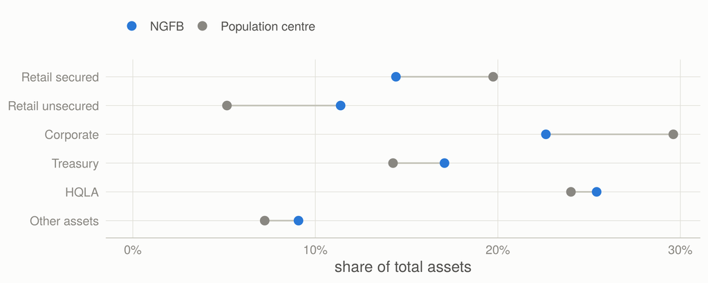

NGFB’s business-line mix against the population centre. The draw lands on the unsecured-heavy side of the six banks: inside the truncation radius, but more than twice the centre’s unsecured share.

**Table view**

| Business line | NGFB | Population centre |
| --- | --- | --- |
| Retail secured | 14.4% | 19.7% |
| Retail unsecured | 11.4% | 5.2% |
| Corporate | 22.6% | 29.6% |
| Treasury | 17.1% | 14.3% |
| HQLA | 25.4% | 24.0% |
| Other assets | 9.1% | 7.2% |

Balance-sheet shares are awkward objects to draw. They are positive and they add up to one, so a normal distribution cannot be put on them directly: a normal draw would happily produce negative mortgages. The standard fix is the additive log-ratio transform (Aitchison 1986). Divide every share $w_k$ by a reference share $w_K$ and take logs,

$$z_k \;=\; \log\frac{w_k}{w_K}, \qquad k = 1,\dots,K-1,$$

which turns $K$ shares that must add to one into $K-1$ unconstrained numbers. Fit a multivariate normal to the banks’ $z$’s, draw from it, and transform back: every draw is then a valid balance sheet, and the shares follow a logistic-normal distribution. The draw is truncated by its Mahalanobis distance from the population centre,

$$d \;=\; \sqrt{(z-\mu)^{\top}\,\Sigma^{-1}\,(z-\mu)} \;\le\; r ,$$

which measures how far a draw sits from the centre in units that allow for the spread and correlation of the population: in one dimension, $d = 1$ is one standard deviation.

Six banks cannot identify an eleven-dimensional covariance of product shares, so the draw is made over six business lines (five dimensions in additive log-ratio space) from a logistic-normal fitted to the six banks’ average compositions over the last eight quarters, and products are split within each line at the population’s average within-line mix. The draw is truncated to the same central probability mass as Post 1’s composition draw (radius 1 in three dimensions keeps the central 19.9%; the equivalent radius in five dimensions is 1.53). NGFB’s draw sits at Mahalanobis distance 0.95.

The seed puts NGFB on the unsecured side of the population: retail unsecured lending is 11.4% of assets against the centre’s 5.2%. That is a legitimate member of the population (one of the six is an unsecured specialist), and it is kept because the seed is canonical, but it colours every result: NGFB’s credit-loss ratio is higher than the sector’s, and it is more exposed to the credit cycle.

## 4.3 The balance sheet

NGFB’s jump-off balance sheet at 2026Q2 against the BA900 sector.

| Line | Side | NGFB, R bn | NGFB, % of assets | Sector, % of assets | NGFB share of augmented sector |
| --- | --- | --- | --- | --- | --- |
| Residential mortgages | asset | 141 | 9.9% | 15.3% | 9.1% |
| Vehicle and asset finance | asset | 65 | 4.5% | 7.6% | 8.5% |
| Credit cards | asset | 69 | 4.8% | 2.1% | 26.0% |
| Personal and other retail | asset | 94 | 6.5% | 3.3% | 23.4% |
| Corporate loans | asset | 199 | 13.9% | 18.5% | 10.5% |
| Overdrafts | asset | 40 | 2.8% | 3.3% | 11.6% |
| Commercial mortgages | asset | 85 | 5.9% | 6.5% | 12.3% |
| Interbank | asset | 69 | 4.8% | 4.8% | 13.5% |
| Reverse repo | asset | 130 | 9.1% | 7.3% | 16.2% |
| Other securities | asset | 45 | 3.1% | 2.3% | 17.2% |
| HQLA (cash, central bank, government) | asset | 364 | 25.4% | 21.7% | 15.4% |
| Other assets | asset | 130 | 9.1% | 7.2% | 16.4% |
| Operational deposits | funding | 485 | 33.9% | 34.9% | 13.1% |
| Notice deposits | funding | 125 | 8.8% | 4.9% | 21.7% |
| Savings deposits | funding | 88 | 6.1% | 6.5% | 12.7% |
| Term deposits | funding | 464 | 32.4% | 22.2% | 18.5% |
| Repo funding | funding | 32 | 2.2% | 3.6% | 8.7% |
| Wholesale and other funding | funding | 85 | 6.0% | 15.1% | 5.8% |
| Other liabilities | funding | 47 | 3.3% | 5.3% | 8.7% |
| Equity | equity | 105 | 7.4% | 7.4% | 13.3% |

## 4.4 NGFB in the industry

NGFB is **added** to the industry rather than carved out of existing banks, following the Post 1 convention of adding a bank the size of the average large bank. Reported banks keep their own books; market shares are measured against the augmented industry, the reported sector plus NGFB. NGFB’s history is back-cast from its jump-off book with its drawn share-dynamics parameters (Stage 2) and the realised regimes and sector growth, so it “lives through” 2008–2026 the way a bank with those parameters would have.

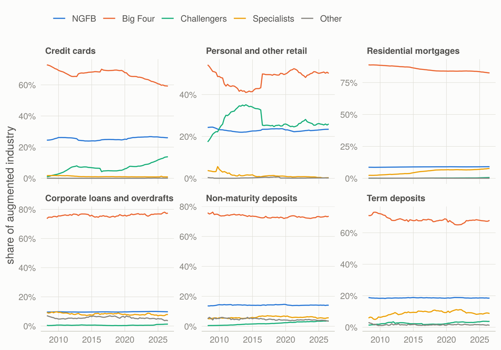

Market shares of the augmented industry (reported sector plus NGFB). NGFB’s line is its back-cast; the peer groups are reported BA900 data.

**Table view**

| product | entity | 2008Q2 | 2016Q2 | 2026Q2 |
| --- | --- | --- | --- | --- |
| Corporate loans and overdrafts | Big Four | 74.6% | 75.3% | 77.4% |
| Corporate loans and overdrafts | Challengers | 0.3% | 0.5% | 1.3% |
| Corporate loans and overdrafts | NGFB | 9.6% | 9.7% | 9.8% |
| Corporate loans and overdrafts | Other | 6.7% | 6.2% | 3.6% |
| Corporate loans and overdrafts | Specialists | 8.8% | 8.4% | 7.9% |
| Credit cards | Big Four | 72.6% | 70.0% | 59.2% |
| Credit cards | Challengers | 1.1% | 4.3% | 13.8% |
| Credit cards | NGFB | 24.5% | 24.7% | 26.0% |
| Credit cards | Other | 0.0% | 0.0% | 0.1% |
| Credit cards | Specialists | 1.7% | 1.0% | 0.9% |
| Non-maturity deposits | Big Four | 75.0% | 72.4% | 73.4% |
| Non-maturity deposits | Challengers | 0.5% | 1.7% | 3.5% |
| Non-maturity deposits | NGFB | 13.6% | 14.2% | 14.0% |
| Non-maturity deposits | Other | 6.0% | 4.9% | 3.3% |
| Non-maturity deposits | Specialists | 5.0% | 6.9% | 5.7% |
| Personal and other retail | Big Four | 53.4% | 49.8% | 50.1% |
| Personal and other retail | Challengers | 18.4% | 25.4% | 26.0% |
| Personal and other retail | NGFB | 24.4% | 23.4% | 23.4% |
| Personal and other retail | Other | 0.3% | 0.5% | 0.2% |
| Personal and other retail | Specialists | 3.6% | 0.9% | 0.3% |
| Residential mortgages | Big Four | 88.8% | 85.3% | 82.6% |
| Residential mortgages | Challengers | 0.1% | 0.2% | 0.6% |
| Residential mortgages | NGFB | 8.7% | 9.0% | 9.1% |
| Residential mortgages | Other | 0.1% | 0.2% | 0.0% |
| Residential mortgages | Specialists | 2.3% | 5.4% | 7.7% |
| Term deposits | Big Four | 70.9% | 68.4% | 67.9% |
| Term deposits | Challengers | 1.4% | 1.7% | 3.7% |
| Term deposits | NGFB | 18.7% | 18.7% | 18.5% |
| Term deposits | Other | 2.6% | 1.3% | 1.2% |
| Term deposits | Specialists | 6.4% | 9.9% | 8.7% |

At the jump-off NGFB holds 26% of the augmented industry’s credit cards and 23% of personal loans, against 9% of residential mortgages. A bank the size of the average large bank with an unsecured-heavy mix is necessarily a large card and personal lender; this is the consequence of the canonical seed noted above, not a forecast.

## 4.5 Calibration to the sector

The engine prices loans and deposits with the sector’s own BA120 yields and costs (projected by Stage 1), applies the sector’s credit-loss ratio through relative loss multipliers by product, and the sector’s fee and cost ratios. The remaining free parameters are pinned to the sector at the last BA120 quarter, 2025Q2:

Calibration to the sector.

| Parameter | Value | How it is set |
| --- | --- | --- |
| Credit risk-weight scale | 1.131 | BA900 sector book × BA200 asset-class risk weights reproduces BA200 credit RWA |
| Non-credit RWA | 11.6% of assets | BA700 total RWA less BA200 credit RWA |
| CET1 / book equity | 0.809 | BA700 CET1 over BA100 ordinary equity |
| Effective tax rate | 22.0% | BA120, last three years |
| HQLA earning share | 80.2% | 1 − cash and central-bank balances / HQLA (BA100) |
| Wholesale spread over the 3-month benchmark | 1.17 pp | solved: engine NII = BA120 NII over 2024Q3–2025Q2 (R249 bn), when the benchmark was JIBAR |
| LCR run-off scalar | 0.798 | solved: sector LCR proxy = 149.6% (Prudential Authority, June 2025) |
| NSFR required-funding scalar | 0.924 | solved: sector NSFR proxy = 117.3% |

Two checks are worth stating plainly. First, the engine’s *gross* interest income and expense on the BA900 balance sheet come out 12% and 20% above BA120’s, while NII matches with a plausible wholesale spread. BA900 carries trading-book positions on both sides of the balance sheet whose interest BA120 books in trading revenue (its own “allocated to trading” lines are R41 bn of expense and R10 bn of income over the window), so the excess is close to net-neutral and is reported rather than calibrated away. Second, one quarter of BA120 call-deposit cost (2025Q2, 10.5%) is a one-off outlier; it is replaced by the window median before calibrating. Left in, it drives the solved wholesale spread to -0.26 pp over JIBAR (see What didn’t work).

### 4.5.1 Liquidity

Depositor-weighted Basel III factors by behavioural deposit line, before the sector scalars. Depositor shares are the sector’s at the calibration date.

| Line | Financial depositors | Retail depositors | 30-day run-off, sector | 30-day run-off, NGFB pool | ASF, sector | ASF, NGFB pool |
| --- | --- | --- | --- | --- | --- | --- |
| Operational deposits | 23% | 31% | 32.8% | 33.6% | 56% | 56% |
| Savings deposits | 2% | 75% | 18.5% | 18.8% | 79% | 79% |
| Notice deposits | 28% | 21% | 50.8% | 48.9% | 44% | 46% |
| Term deposits | 59% | 28% | 8.9% | 9.1% | 65% | 64% |

BA900 crosses depositors with contractual buckets, and the Basel III run-off and stable-funding factors depend on both, so each behavioural deposit line carries the balance-weighted factor of the depositors who hold it: fund managers’ call money runs off at 100% inside 30 days, household savings at 10%. Unadjusted, these proxies put the sector’s LCR at 112% and NSFR at 108% against the published 150% and 117%; one scalar each absorbs what BA900 cannot see (the 30-day slice of term deposits, operational status, committed facilities, derivatives). NGFB, with more HQLA and less wholesale funding than the sector, starts at an LCR of 190% and an NSFR of 132%.

# 5 Stage 1: macro to the industry

Stage 1 maps a macro path to the industry: the growth of each loan and deposit book, lending spreads over prime and the three-month benchmark, deposit costs, the credit-loss ratio, fees and operating costs. That is 22 series in all, built on the SARB’s BA900 and BA100/BA120 returns. The workhorse is a sign-restricted ARDL model, and that is all this edition says about it: its specification, its estimates, its tests and how it was chosen stay in the drawer, like any koeksister recipe worth having. Here it is a black box with a simple contract: hand it a macro path, and it hands back the industry’s volumes, margins and losses along that path. The scenarios show what it hands back.

# 6 Stage 2: banks relative to the industry

## 6.1 Regimes and the share model

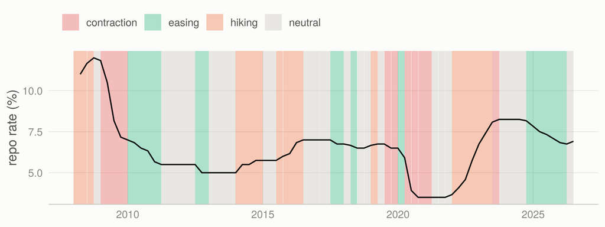

The repo rate with the macro regimes used in Stage 2. Contraction takes priority (real GDP down on a year earlier), then hiking or easing (the repo rate up or down at least 25 bps over two quarters).

For each peer group (and, internally, each large bank) and product, the annualised change in log market share is

$$400\,\Delta \log s_{t} = a + \delta_{\text{contr}}\, C_t + \delta_{\text{hike}}\, H_t + \delta_{\text{ease}}\, E_t + \kappa\,(g^{\text{sector}}_t - \bar g) + e_t ,$$

Read it left to right. The 400 turns a quarterly change in log share into percentage points a year: four quarters, times a hundred. $a$ is the structural drift, how fast the group gains or loses share in an ordinary quarter, which for some groups is a decade-long march summarised in one number. $C_t$, $H_t$ and $E_t$ are switches that turn on in contraction, hiking and easing quarters, so each $\delta$ is the extra drift in that regime compared with a neutral quarter, the base. The $\kappa$ term asks whether the group grows faster than the market when the market is booming, meaning sector growth $g^{\text{sector}}_t$ above its average $\bar g$, and slower when it is not: $\kappa > 0$ is a pro-cyclical share, growing faster than the market in booms and shrinking faster in busts. $e_t$ is everything else: a new app, a new chief executive, a weekend the core banking system spent offline.

The regimes are defined mechanically, with contraction taking priority. A quarter is a contraction if real GDP is lower than a year earlier. Otherwise it is hiking or easing if the repo rate has moved up or down by at least 25 bps over two quarters, and otherwise it is neutral. The sample has 11 contraction, 18 hiking, 17 easing and 28 neutral quarters from 2008Q1.

Structural share drift a by peer group: percent a year of share growth, HAC t-statistics in brackets (— where a group’s share is too small to model).

| product | Big Four | Challengers | Specialists | Other |
| --- | --- | --- | --- | --- |
| Credit cards | -1.1 (-2.8) | +14.6 (2.7) | -5.5 (-2.2) | — |
| Personal and other retail | -1.1 (-0.7) | +2.9 (1.2) | -18.8 (-1.4) | +26.4 (1.9) |
| Residential mortgages | -0.3 (-4.0) | +11.0 (4.0) | +5.3 (4.0) | -8.1 (-1.0) |
| Corporate loans and overdrafts | +0.4 (1.0) | -1.7 (-0.1) | -2.2 (-0.6) | -3.4 (-0.9) |
| Non-maturity deposits | -0.1 (-0.2) | +13.4 (3.6) | -0.8 (-0.3) | -1.8 (-0.3) |
| Retail deposits (households) | -0.5 (-2.9) | +11.8 (5.2) | -0.8 (-0.4) | +1.0 (0.1) |
| Term deposits | +0.4 (0.6) | +0.1 (0.0) | -2.5 (-0.6) | -5.3 (-0.5) |

**All share-model coefficients (percent a year; HAC t in brackets; kappa per point of sector growth)**

| Product | Group | Drift a | Contraction | Hiking | Easing | Cycle kappa |
| --- | --- | --- | --- | --- | --- | --- |
| Corporate loans and overdrafts | Big Four | +0.4 (1.0) | +1.2 (2.1) | -0.4 (-0.5) | -0.9 (-1.2) | +0.0 (0.4) |
| Corporate loans and overdrafts | Challengers | -1.7 (-0.1) | +36.1 (2.1) | 0.0 (0.0) | +9.4 (0.6) | -1.0 (-1.8) |
| Corporate loans and overdrafts | Other | -3.4 (-0.9) | -11.3 (-1.7) | +1.6 (0.2) | +4.6 (0.6) | +0.4 (1.5) |
| Corporate loans and overdrafts | Specialists | -2.2 (-0.6) | -4.1 (-0.8) | +4.1 (0.7) | +4.4 (0.8) | -0.3 (-1.7) |
| Credit cards | Big Four | -1.1 (-2.8) | -0.5 (-0.7) | +1.3 (1.3) | -0.6 (-1.1) | +0.0 (0.7) |
| Credit cards | Challengers | +14.6 (2.7) | +12.1 (1.4) | -12.0 (-0.9) | +4.9 (0.6) | -0.6 (-0.9) |
| Credit cards | Specialists | -5.5 (-2.2) | +3.3 (1.0) | +4.4 (1.4) | +1.7 (0.2) | -0.5 (-1.8) |
| Non-maturity deposits | Big Four | -0.1 (-0.2) | -0.2 (-0.2) | -0.5 (-0.9) | +0.3 (0.6) | +0.0 (0.1) |
| Non-maturity deposits | Challengers | +13.4 (3.6) | -2.5 (-0.5) | -6.6 (-1.4) | -0.4 (-0.1) | -0.8 (-5.8) |
| Non-maturity deposits | Other | -1.8 (-0.3) | +6.6 (0.4) | +0.6 (0.1) | -6.9 (-0.8) | +0.6 (1.6) |
| Non-maturity deposits | Specialists | -0.8 (-0.3) | -2.4 (-0.4) | +7.1 (1.5) | +0.6 (0.1) | -0.4 (-3.4) |
| Personal and other retail | Big Four | -1.1 (-0.7) | -1.1 (-0.6) | +2.6 (1.2) | +0.5 (0.2) | -0.5 (-2.4) |
| Personal and other retail | Challengers | +2.9 (1.2) | +0.9 (0.3) | -3.3 (-0.9) | -0.6 (-0.2) | +0.8 (2.3) |
| Personal and other retail | Other | +26.4 (1.9) | -101.8 (-1.8) | -59.6 (-1.2) | -7.4 (-0.3) | -0.7 (-0.8) |
| Personal and other retail | Specialists | -18.8 (-1.4) | +12.2 (0.5) | +16.5 (1.1) | -3.4 (-0.1) | -0.3 (-0.4) |
| Residential mortgages | Big Four | -0.3 (-4.0) | +0.2 (1.3) | -0.1 (-0.7) | -0.2 (-2.0) | +0.0 (1.3) |
| Residential mortgages | Challengers | +11.0 (4.0) | -9.0 (-2.4) | +4.0 (0.9) | +4.6 (0.7) | +0.2 (0.3) |
| Residential mortgages | Other | -8.1 (-1.0) | -10.6 (-0.7) | +5.1 (0.3) | +6.6 (0.8) | 0.0 (0.0) |
| Residential mortgages | Specialists | +5.3 (4.0) | +0.2 (0.1) | +3.0 (1.2) | +2.9 (1.8) | -1.0 (-2.3) |
| Retail deposits (households) | Big Four | -0.5 (-2.9) | -0.5 (-1.7) | -0.7 (-1.8) | -0.5 (-1.6) | -0.1 (-1.9) |
| Retail deposits (households) | Challengers | +11.8 (5.2) | +5.4 (1.4) | -4.2 (-1.2) | +4.9 (1.0) | +0.3 (0.9) |
| Retail deposits (households) | Other | +1.0 (0.1) | -32.0 (-1.5) | +0.7 (0.1) | -10.4 (-0.8) | -0.1 (-0.1) |
| Retail deposits (households) | Specialists | -0.8 (-0.4) | +7.8 (1.0) | +9.8 (2.1) | +4.4 (1.0) | +0.2 (0.4) |
| Term deposits | Big Four | +0.4 (0.6) | -1.1 (-1.2) | 0.0 (0.0) | -1.9 (-2.3) | +0.1 (2.8) |
| Term deposits | Challengers | +0.1 (0.0) | +21.5 (3.6) | -5.6 (-0.7) | +14.7 (2.3) | -0.5 (-1.8) |
| Term deposits | Other | -5.3 (-0.5) | -19.9 (-1.1) | +3.6 (0.2) | +10.9 (0.6) | 0.0 (0.0) |
| Term deposits | Specialists | -2.5 (-0.6) | +9.6 (1.0) | +3.3 (0.5) | +10.5 (1.8) | -0.4 (-2.6) |

The structural drifts carry the clearest message: over 2008–2026 the Challengers took share at double-digit rates in cards, retail deposits and non-maturity deposits (all with $t > 2.5$), and the Big Four ceded it slowly but significantly in cards, retail deposits and mortgages. Regime effects are mostly imprecise, as is to be expected with only 11 contraction quarters, which is why they are pooled across banks and then truncated before they reach NGFB.

## 6.2 Who takes share from whom

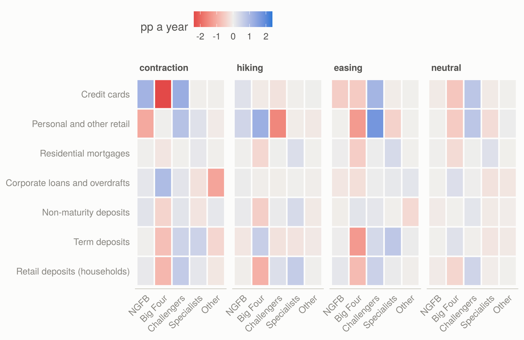

Average change in market share by regime, percentage points a year, with NGFB in the mix. Positive (blue) is a gain.

**Table view (pp a year)**

| product | entity | contraction | easing | hiking | neutral |
| --- | --- | --- | --- | --- | --- |
| Corporate loans and overdrafts | Big Four | +0.98 | -0.25 | -0.02 | +0.31 |
| Corporate loans and overdrafts | Challengers | +0.20 | +0.06 | -0.04 | +0.03 |
| Corporate loans and overdrafts | NGFB | +0.18 | -0.14 | +0.07 | +0.00 |
| Corporate loans and overdrafts | Other | -1.14 | +0.19 | -0.03 | -0.14 |
| Corporate loans and overdrafts | Specialists | -0.21 | +0.13 | +0.02 | -0.20 |
| Credit cards | Big Four | -2.39 | -0.56 | -0.07 | -0.63 |
| Credit cards | Challengers | +1.26 | +1.12 | -0.20 | +0.78 |
| Credit cards | NGFB | +1.14 | -0.51 | +0.27 | -0.08 |
| Credit cards | Other | -0.01 | 0.00 | +0.02 | +0.00 |
| Credit cards | Specialists | -0.01 | -0.05 | -0.01 | -0.08 |
| Non-maturity deposits | Big Four | -0.42 | +0.21 | -0.50 | +0.00 |
| Non-maturity deposits | Challengers | +0.21 | +0.17 | +0.10 | +0.19 |
| Non-maturity deposits | NGFB | +0.23 | -0.03 | +0.11 | -0.07 |
| Non-maturity deposits | Other | +0.15 | -0.34 | -0.09 | -0.05 |
| Non-maturity deposits | Specialists | -0.17 | -0.01 | +0.39 | -0.08 |
| Personal and other retail | Big Four | +0.01 | -1.30 | +1.24 | -0.55 |
| Personal and other retail | Challengers | +0.86 | +1.74 | -1.57 | +0.78 |
| Personal and other retail | NGFB | -1.06 | +0.00 | +0.49 | 0.00 |
| Personal and other retail | Other | -0.07 | +0.00 | -0.10 | +0.06 |
| Personal and other retail | Specialists | +0.26 | -0.45 | -0.05 | -0.29 |
| Residential mortgages | Big Four | -0.15 | -0.52 | -0.36 | -0.31 |
| Residential mortgages | Challengers | +0.00 | +0.06 | +0.02 | +0.02 |
| Residential mortgages | NGFB | +0.02 | +0.05 | +0.02 | +0.01 |
| Residential mortgages | Other | -0.02 | +0.00 | +0.01 | -0.01 |
| Residential mortgages | Specialists | +0.14 | +0.40 | +0.31 | +0.28 |
| Retail deposits (households) | Big Four | -0.86 | -0.79 | -0.96 | -0.39 |
| Retail deposits (households) | Challengers | +0.68 | +0.56 | +0.30 | +0.50 |
| Retail deposits (households) | NGFB | +0.13 | +0.17 | -0.03 | -0.07 |
| Retail deposits (households) | Other | -0.13 | -0.03 | +0.02 | 0.00 |
| Retail deposits (households) | Specialists | +0.18 | +0.09 | +0.67 | -0.04 |
| Term deposits | Big Four | -0.73 | -1.31 | +0.62 | +0.26 |
| Term deposits | Challengers | +0.53 | +0.42 | -0.20 | -0.01 |
| Term deposits | NGFB | +0.02 | +0.05 | -0.14 | 0.00 |
| Term deposits | Other | -0.38 | +0.08 | -0.10 | -0.10 |
| Term deposits | Specialists | +0.55 | +0.75 | -0.18 | -0.15 |

Net share changes do not say who lost to whom: a two-point gain could come from one competitor or from all of them. The flow matrices below use a labelled convention, giving each gainer’s gain to the losers in proportion to their losses.

Credit cards in contractions: share gained (rows) from each loser (columns), pp a year.

| gains | Big Four | Challengers | NGFB | Other | Specialists |
| --- | --- | --- | --- | --- | --- |
| Challengers | 1.25 | 0 | 0 | 0.01 | 0 |
| NGFB | 1.13 | 0 | 0 | 0.01 | 0 |

Non-maturity deposits in hiking regimes: share gained (rows) from each loser (columns), pp a year.

| gains | Big Four | Challengers | NGFB | Other | Specialists |
| --- | --- | --- | --- | --- | --- |
| Challengers | 0.08 | 0 | 0 | 0.01 | 0 |
| NGFB | 0.09 | 0 | 0 | 0.02 | 0 |
| Specialists | 0.33 | 0 | 0 | 0.06 | 0 |

In contractions the Big Four lose card share to the Challengers and to NGFB; in hiking regimes non-maturity deposits move from the Big Four towards the Specialists, with NGFB and the Challengers smaller gainers. NGFB’s rows follow from its drawn parameters below, so they describe the kind of bank NGFB is, not data about any real bank.

## 6.3 NGFB’s share parameters

Random-effects (DerSimonian–Laird) pooling across the six large banks and NGFB’s posterior-predictive draw (seed 20260622), truncated at the same central probability mass as Post 1. Only pooled hyperparameters are shown.

| Product | Parameter | Population mean | Between-bank s.d. | s.e. of mean | Banks | NGFB |
| --- | --- | --- | --- | --- | --- | --- |
| Credit cards | (Intercept) | -1.55 | 3.44 | 1.79 | 5 | -4.90 |
| Credit cards | contraction | -1.36 | 6.01 | 3.16 | 5 | 3.79 |
| Credit cards | hiking | 1.21 | 0.00 | 1.07 | 5 | 1.43 |
| Credit cards | easing | -1.28 | 4.25 | 2.48 | 5 | -1.96 |
| Credit cards | kappa | -0.41 | 0.27 | 0.16 | 5 | -0.34 |
| Non-maturity deposits | (Intercept) | 0.77 | 2.26 | 1.22 | 6 | 1.94 |
| Non-maturity deposits | contraction | 0.48 | 0.00 | 1.14 | 6 | 0.41 |
| Non-maturity deposits | hiking | 0.22 | 0.12 | 1.12 | 6 | 0.60 |
| Non-maturity deposits | easing | -0.02 | 0.00 | 1.10 | 6 | -0.01 |
| Non-maturity deposits | kappa | -0.19 | 0.30 | 0.14 | 6 | -0.47 |
| Personal and other retail | (Intercept) | 0.39 | 5.59 | 2.79 | 6 | 1.25 |
| Personal and other retail | contraction | 0.70 | 9.96 | 4.98 | 6 | -6.16 |
| Personal and other retail | hiking | 2.85 | 0.00 | 1.93 | 6 | 2.17 |
| Personal and other retail | easing | 0.83 | 0.00 | 2.18 | 6 | 0.72 |
| Personal and other retail | kappa | -0.39 | 0.28 | 0.17 | 6 | -0.14 |

The bank layer needs more than peer-group averages, because NGFB has to be a plausible *single* bank. So the six large banks’ equations are also estimated one by one and pooled into a population with a random-effects estimator (DerSimonian and Laird 1986). Each bank’s estimate $\hat\theta_b$ of a parameter is treated as the population mean, plus the bank’s genuine difference from it, plus estimation noise:

$$\hat\theta_b \;=\; \mu \;+\; u_b \;+\; \varepsilon_b, \qquad u_b \sim N(0,\tau^2), \qquad \varepsilon_b \sim N(0,\mathrm{se}_b^2).$$

The noise variances are known, because every estimate comes with its standard error. So whatever spread between the banks’ estimates is left over beyond what noise can explain is genuine difference between banks, $\tau^2$. DerSimonian and Laird estimate it by the method of moments, and the population mean $\mu$ is then a weighted average that trusts the precisely estimated banks more than the noisy ones. A new member of the population, such as NGFB, draws its parameters from $N(\mu,\,\tau^2 + \mathrm{se}_\mu^2)$: the population mean, spread by both the genuine differences between banks and the uncertainty about the mean itself. The same population supplies the yardsticks for where NGFB should lean in and for its macro-adjusted scorecards: par (the mean) and the frontier (the 80th percentile of the predictive distribution).

Each parameter is pooled across the six large banks with a random-effects (DerSimonian–Laird) estimator, and NGFB’s vector is drawn from the posterior predictive $N(\mu, \tau^2 + \text{se}_\mu^2)$, truncated to the same central probability mass as Post 1 (radius 1.53 in five dimensions). Only pooled quantities with at least four banks are used. NGFB’s **structural drift is switched off** in all projections: a drawn drift of a few percent a year compounds into large, arbitrary share gains or losses over a horizon, and the question here is how NGFB responds to the *cycle*.

# 7 The engine

Each quarter the engine does what a bank’s planning model does, line by line. Every book grows with the industry’s growth for that product, adjusted by NGFB’s share dynamics from Stage 2, and wholesale funding balances the books, which is what a bank actually does at the margin. Then comes the income statement, starting with net interest income:

$$\text{NII}_t \;=\; \sum_{i\,\in\,\text{assets}} \bar B_{i,t}\,\frac{y_{i,t}}{4} \;-\; \sum_{j\,\in\,\text{liabilities}} \bar B_{j,t}\,\frac{c_{j,t}}{4} \;+\; H_t .$$

That is average balance $\bar B$ times rate, a quarter at a time, for every asset (at yield $y$) and every liability (at cost $c$), plus $H_t$, the structural hedge’s net settlement. Loans earn prime or the three-month benchmark plus the industry’s projected spreads, deposits cost the industry’s projected deposit costs, and HQLA earn roughly the Treasury bill rate. The hedge term deserves its own line, because it is where most of the rate risk is made and lost:

$$H_t \;=\; \sum_{i} N_i\,\frac{F_i - f_t}{4} .$$

Each tranche $i$ of the receive-fixed hedge earns its fixed rate $F_i$ and pays the floating benchmark $f_t$ on its notional $N_i$. In the plan one twentieth of the book matures every quarter and is replaced at the then five-year swap rate (or at the tenor a lever chooses), so the book’s average fixed rate drifts slowly while the floating rate moves at the speed of the Monetary Policy Committee. The gap between the two is the hedge carry, and it is the whole story of how a structural hedge makes or loses money.

Below NII the engine is plain accounting, the part nobody presents at conferences and every number depends on:

$$\text{NI}_t \;=\; (1-\tau)\big(\text{NII}_t + \text{NIR}_t - \text{Opex}_t - \text{Imp}_t\big), \qquad \text{ROE}_t \;=\; \frac{4\,\text{NI}_t}{\tfrac12\,(E_{t-1}+E_t)} .$$

Fees ($\text{NIR}$) and operating costs follow the industry’s ratios to assets. Impairments are the industry’s credit-loss ratio scaled up or down by product, unsecured highest and home loans lowest, because no return publishes losses by product. Net income is profit after tax at rate $\tau$. In the plan half of it is paid out and the rest retained, so equity rolls forward as $E_t = E_{t-1} + \text{NI}_t - \text{dividends}_t$, and ROE is annualised net income over average equity. The CET1 ratio is CET1 over risk-weighted assets, with the bond books’ OCI reserve when they are held at fair value; the LCR and NSFR are proxies built from BA900’s depositor-by-maturity matrix and calibrated to the ratios the Prudential Authority publishes for the sector (Calibration to the sector); the leverage ratio is CET1 over on-balance-sheet assets; and the PV01 of the hedge and bond books gives the change in the economic value of equity (EVE) for a parallel rate shock. Every ROE in this report is the average over the twelve quarters from 2026Q3 to 2029Q2 unless it says otherwise.

One more piece of plumbing has become topical. JIBAR, the three-month rate that floating loans, wholesale funding and the hedge’s floating leg have referenced for a generation, publishes its last fixing on 31 December 2026, so somebody in every treasury already knows how they are spending New Year’s Eve. From 2027Q1 the engine’s floating benchmark is compounded ZARONIA plus the fixed 16.19 bp fallback spread, so ten of the twelve projected quarters are priced off JIBAR’s successor. JIBAR’s end has what that does.

# 8 Scenarios

The three scenarios, and the downside’s policy-rate variant. Probabilities are judgemental and are used only for the probability-weighted positioning.

[output not shown]

The baseline starts from the realised data at 2026Q2 and follows the SARB’s own guidance for the next year: the repo rate at 7.25% after the September 2026 increase, inflation above 5% around the turn of the year and back at the 3% target (adopted with a one-point tolerance band in November 2025) by late 2027, after which the policy rate eases gradually to a 6.25% neutral level. Growth converges to about 1.6%. The upside and the downside are shocks layered on the baseline with build-up, hold and decay profiles; the derived variables (prime, the 3-month floating benchmark, curve slope, swap curve, real rates, rate changes and their partial sums) are recomputed from the shocked paths, so every scenario is internally consistent. The floating benchmark is 3-month JIBAR until its last fixing on 31 December 2026 and compounded ZARONIA plus the 16.19 bp fallback spread from 2027Q1 (JIBAR’s end), so ten of the twelve projected quarters are priced off ZARONIA.

The **downside** is deliberately stagflationary. The SARB’s own 2023 common scenario stress test built its domestic adverse scenario the same way: a higher country risk premium and a sharply weaker rand push inflation up, the SARB tightens, government bond yields reprice and the economy contracts. The alternative, a demand-led recession in which inflation falls and the SARB cuts (2009, 2020), is run as a **variant** with the same real shock, because for a hedged bank the policy response decides the sign of the rate effect.

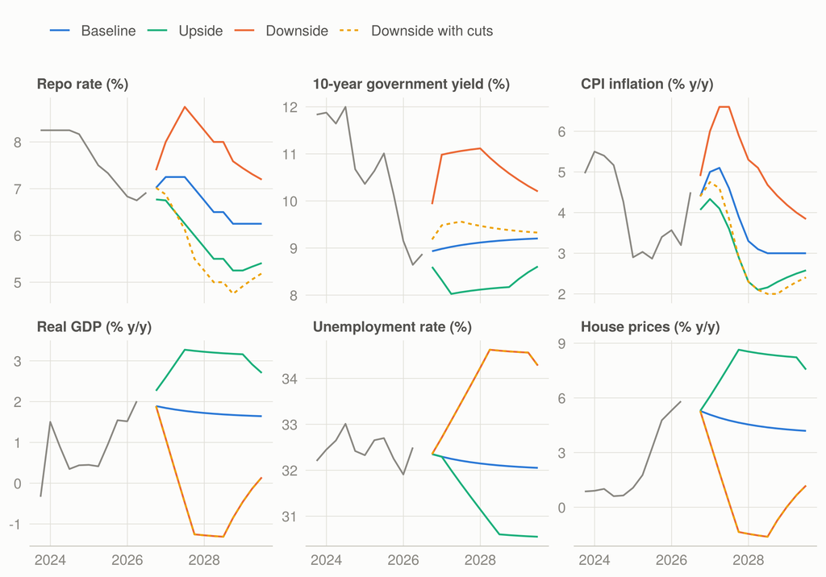

Macro paths by scenario (history in grey). The dashed line is the downside’s variant with rate cuts.

**Table view**

| Scenario | Repo, peak | Repo, end | GDP y/y, trough | GDP y/y, average | CPI y/y, peak | Unemployment, peak | House prices y/y, trough | 10-year, peak |
| --- | --- | --- | --- | --- | --- | --- | --- | --- |
| Baseline | 7.25 | 6.25 | 1.6 | 1.7 | 5.1 | 32.4 | 4.2 | 9.20 |
| Upside | 6.77 | 5.41 | 2.3 | 3.0 | 4.3 | 32.4 | 5.3 | 8.61 |
| Downside | 8.75 | 7.19 | -1.3 | -0.3 | 6.6 | 34.6 | -1.6 | 11.12 |
| Downside with cuts | 7.02 | 5.19 | -1.3 | -0.3 | 4.8 | 34.6 | -1.6 | 9.56 |

## 8.1 What the scenarios do to the industry and to NGFB

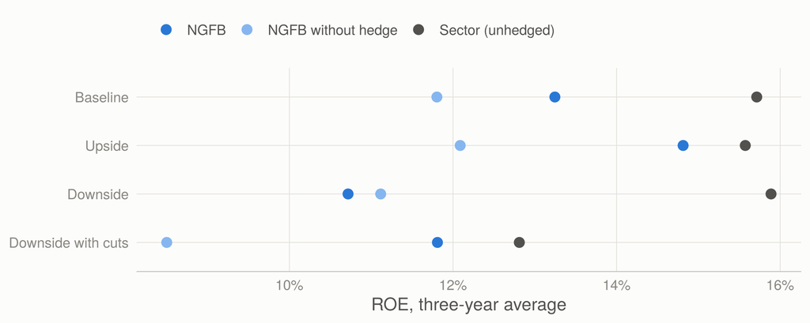

Three-year average ROE by scenario: NGFB with its hedge, NGFB without it, and the BA900 sector through the same engine (unhedged).

Change against the baseline, by channel: three-year average ROE and three-year net income. Each channel swaps one block of engine inputs from the scenario into the baseline run; the interaction is the residual.

| Scenario | Entity | Metric | Volume | Pricing (incl. hedge) | Credit | Fees and costs | Interaction | Total |
| --- | --- | --- | --- | --- | --- | --- | --- | --- |
| Upside | NGFB | ROE | -6 bps | +60 bps | +102 bps | +1 bps | -1 bps | +157 bps |
| Upside | NGFB | Net income, 3 years | -R0.2 bn | +R2.3 bn | +R4.0 bn | +R0.1 bn | +R0.0 bn | +R6.1 bn |
| Upside | Sector | ROE | +7 bps | -92 bps | +68 bps | +1 bps | +1 bps | -14 bps |
| Upside | Sector | Net income, 3 years | +R1.8 bn | -R23.7 bn | +R17.9 bn | +R0.3 bn | +R0.1 bn | -R3.6 bn |
| Downside | NGFB | ROE | +4 bps | -93 bps | -168 bps | +3 bps | +2 bps | -253 bps |
| Downside | NGFB | Net income, 3 years | +R0.1 bn | -R3.6 bn | -R6.4 bn | +R0.1 bn | +R0.1 bn | -R9.6 bn |
| Downside | Sector | ROE | -9 bps | +133 bps | -111 bps | +3 bps | +2 bps | +17 bps |
| Downside | Sector | Net income, 3 years | -R2.3 bn | +R35.0 bn | -R28.8 bn | +R0.7 bn | -R0.1 bn | +R4.6 bn |
| Downside with cuts | NGFB | ROE | +6 bps | +10 bps | -141 bps | -23 bps | +5 bps | -144 bps |
| Downside with cuts | NGFB | Net income, 3 years | +R0.2 bn | +R0.4 bn | -R5.4 bn | -R0.9 bn | +R0.2 bn | -R5.5 bn |
| Downside with cuts | Sector | ROE | -3 bps | -168 bps | -94 bps | -22 bps | -3 bps | -290 bps |
| Downside with cuts | Sector | Net income, 3 years | -R0.7 bn | -R43.3 bn | -R24.3 bn | -R5.7 bn | +R0.1 bn | -R73.9 bn |

The industry is an **endowment play**. Without a hedge, its deposits and capital earn more when rates rise, so in the downside the higher repo path adds +133 bps to the sector’s ROE and offsets the credit losses (-111 bps); in the upside the cuts take -92 bps away and the better credit picture only partly compensates. NGFB is a **credit play**, and in this version a slightly **liability-sensitive** one. Its unsecured-heavy book makes credit its largest channel (-168 bps in the downside, +102 bps in the upside), and its receive-fixed hedge, sized for slower deposit repricing than the refined models now find, more than offsets its endowment: higher rates cost it 93 bps in the downside, and lower rates add 60 bps in the upside. In net income the downside costs NGFB R9.6 bn over three years (R6.4 bn of it credit), while the sector, 7.9 times NGFB’s size in earnings, makes +R4.6 bn.

The **variant** shows how much rides on the policy response. With the same contraction but rate cuts, the hedge earns +10 bps for NGFB, which loses 144 bps in total, about half the stagflationary loss, while the unhedged sector loses 290 bps. A structural hedge protects against the downturns of 2009 and 2020; it does not protect against a downturn that comes with hikes.

NGFB’s *level* of ROE sits below the sector’s (13.2% against 15.7% in the baseline), because its unsecured-heavy book carries higher credit losses (1.39% of loans against 0.88%). The hedge narrows the gap: without it NGFB would earn 11.8%. Its receive-fixed book carries an average fixed rate of 7.60%, struck at actual swap rates over the past five years, against a floating leg averaging 6.73% over the horizon (JIBAR to December 2026, then compounded ZARONIA plus 16.19 bp, which is what the converted swaps pay), while new swaps are struck close to that benchmark (the 5-year JIBAR swap traded 0.03 pp above 3-month JIBAR on average in 2023–2026). The carry is the value of a position taken when rates were higher, not a free lunch: it is what the hedge pays for giving up the upside in a hiking cycle. In the previous version the hedge appeared to lift NGFB above the sector; that was a swap proxy that overstated the book’s rate (see Are the numbers right?).

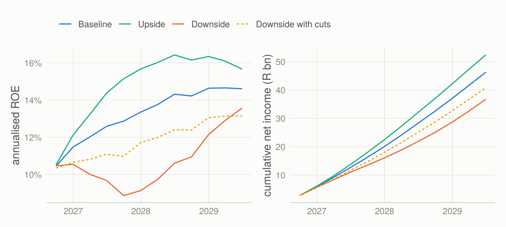

NGFB’s quarterly ROE and cumulative net income by scenario.

**Table view: quarterly ROE / cumulative net income**

| Quarter | Baseline | Upside | Downside | Downside with cuts |
| --- | --- | --- | --- | --- |
| 2026Q3 | 10.4% / R2.8 bn | 10.5% / R2.8 bn | 10.5% / R2.8 bn | 10.3% / R2.7 bn |
| 2026Q4 | 11.5% / R5.8 bn | 12.1% / R6.0 bn | 10.5% / R5.6 bn | 10.7% / R5.6 bn |
| 2027Q1 | 12.0% / R9.1 bn | 13.2% / R9.7 bn | 10.0% / R8.3 bn | 10.8% / R8.5 bn |
| 2027Q2 | 12.6% / R12.6 bn | 14.4% / R13.6 bn | 9.7% / R11.0 bn | 11.1% / R11.6 bn |
| 2027Q3 | 12.9% / R16.2 bn | 15.1% / R17.9 bn | 8.9% / R13.5 bn | 11.0% / R14.7 bn |
| 2027Q4 | 13.4% / R20.0 bn | 15.7% / R22.5 bn | 9.1% / R16.0 bn | 11.7% / R18.0 bn |
| 2028Q1 | 13.8% / R24.0 bn | 16.0% / R27.2 bn | 9.7% / R18.8 bn | 12.0% / R21.4 bn |
| 2028Q2 | 14.3% / R28.3 bn | 16.4% / R32.1 bn | 10.6% / R21.9 bn | 12.4% / R25.1 bn |
| 2028Q3 | 14.2% / R32.6 bn | 16.1% / R37.0 bn | 10.9% / R25.1 bn | 12.4% / R28.7 bn |
| 2028Q4 | 14.6% / R37.0 bn | 16.3% / R42.2 bn | 12.1% / R28.7 bn | 13.1% / R32.7 bn |
| 2029Q1 | 14.7% / R41.6 bn | 16.1% / R47.3 bn | 12.9% / R32.6 bn | 13.1% / R36.7 bn |
| 2029Q2 | 14.6% / R46.3 bn | 15.7% / R52.4 bn | 13.6% / R36.7 bn | 13.1% / R40.8 bn |

Capital and liquidity are not the constraint in any scenario: NGFB’s CET1 ratio never falls below 12.4% (management floor 11.5%), and its LCR proxy never below 182% (floor 120%).

## 8.2 Model risk in the scenarios

The level of credit losses is where the industry models carry the most model risk. Two alternative credit-model choices were run through the engine: they move the level of NGFB’s returns, by at most 152 bps of ROE in any scenario, but not the differences between scenarios, and not the positioning.

# 9 Sensitivities

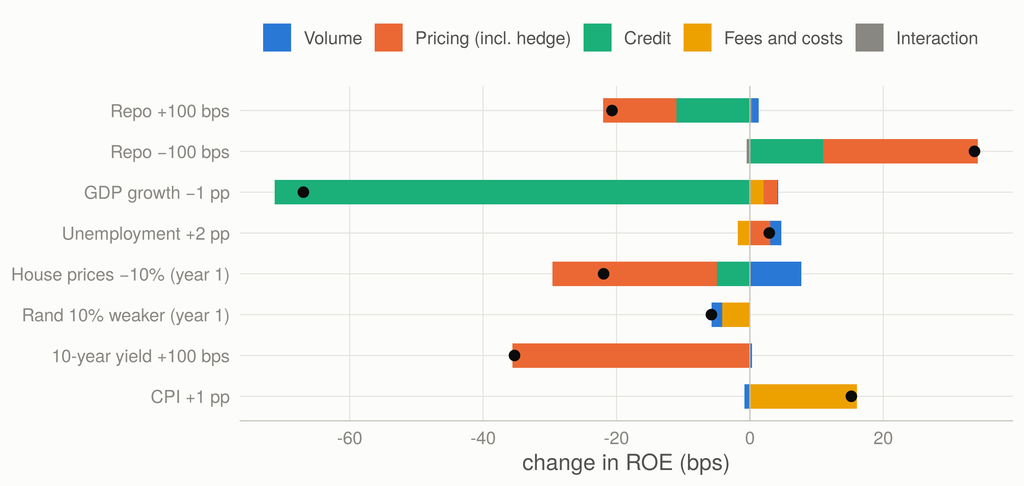

NGFB’s three-year average ROE response to one-variable shocks around the baseline, by channel. The dot is the total.

**Table view**

| Shock | Total | Net income, 3 years | Volume | Pricing | Credit | Fees and costs | NIM | Credit-loss ratio | CET1, end | Total without hedge |
| --- | --- | --- | --- | --- | --- | --- | --- | --- | --- | --- |
| Repo +100 bps | -21 bps | -R795 m | +1 bps | -11 bps | -11 bps | +0 bps | -1 bps | +1 bps | +6 bps | +130 bps |
| Repo −100 bps | +34 bps | +R1,301 m | +0 bps | +23 bps | +11 bps | +0 bps | +3 bps | -1 bps | +6 bps | -117 bps |
| GDP growth −1 pp | -67 bps | -R2,566 m | +0 bps | +2 bps | -71 bps | +2 bps | +0 bps | +11 bps | -7 bps | -68 bps |
| Unemployment +2 pp | +3 bps | +R112 m | +2 bps | +3 bps | +0 bps | -2 bps | +0 bps | -1 bps | +7 bps | +3 bps |
| House prices −10% (year 1) | -22 bps | -R843 m | +8 bps | -25 bps | -5 bps | +0 bps | -1 bps | +1 bps | +7 bps | -22 bps |
| Rand 10% weaker (year 1) | -6 bps | -R222 m | -2 bps | +0 bps | +0 bps | -4 bps | -1 bps | +0 bps | -3 bps | -6 bps |
| 10-year yield +100 bps | -35 bps | -R1,356 m | +0 bps | -36 bps | +0 bps | +0 bps | -4 bps | +0 bps | -6 bps | -36 bps |
| CPI +1 pp | +15 bps | +R587 m | -1 bps | +0 bps | +0 bps | +16 bps | +0 bps | +0 bps | -6 bps | +16 bps |

The sensitivities answer “how exposed are we” one variable at a time (one basis point of ROE is about R12 m of net income a year):

- **Rates.** ±100 bps on the repo path moves NGFB’s ROE by -21 bps / +34 bps (-R795 m / +R1,301 m of net income over three years). Without the hedge the same shocks would move it by +130 bps / -117 bps. The hedge, 49.6% of non-maturity deposits, was sized in Post 3 for slower deposit repricing than the refined Stage 1 models find, so it now more than neutralises the endowment and leaves NGFB modestly liability-sensitive; the ratio that would leave first-year NII unchanged by a parallel move is 37% (see Are the numbers right?). A rate rise also costs 11 bps through credit losses.
- **Growth.** One point less GDP growth for three years costs 67 bps (-R2,566 m), almost all of it through credit losses (-71 bps). This is NGFB’s largest single exposure.
- **House prices** matter through mortgage and VAF pricing and credit (-22 bps for a 10% fall in the first year).
- **Inflation** helps a little (+15 bps per point) because fee income tracks nominal activity.
- **Unemployment** has essentially no effect (+3 bps): no credit-loss specification with unemployment survives the sign and t-tests, so the engine has no unemployment channel. Unemployment is not harmless; the South African series is too slow-moving and too noisy, given GDP, to identify one.

# 10 Positioning before the scenario arrives

## 10.1 The optimisation problem

The decision is a set of balance-sheet moves made at the jump-off: transfers of one percent of total assets from HQLA (the liquidity numeraire) into a lending book, from wholesale funding into a deposit category, or a change in the receive-fixed hedge of one percent of the non-maturity deposit (NMD) base. The full engine is the source of truth; around the status quo it is close to linear in the moves, so for every scenario $s$ the ROE gradient $G_s$ and the gradients of the CET1 and LCR troughs and of net income come from central finite differences.

A naive optimiser would simply maximise the engine’s ROE. Even with the execution costs below it grows every lending book out of HQLA, pushes 4 of the six to their upper bound and claims 324 bps of probability-weighted ROE: the engine prices new volume at the book’s *average* yield, loss rate and cost ratio, and holds equity fixed, so any risk asset looks better than HQLA. That static attractiveness is a franchise and capacity question (marginal pricing, cost to serve, adverse selection) that public data cannot price. The positioning question is different: *what should change because scenario X is coming?*

The answer used here treats the status quo as optimal under the baseline (the balance sheet reflects the bank’s central plan). That reveals an implied marginal cost for every move, $c = G_{\text{baseline}}$, in the same way Black and Litterman back out implied returns from market weights. Positioning then trades on how a scenario changes each move’s value:

$$\max_x \; \sum_s w_s \big(R_s + (G_s - c)\,x\big) \;-\; \tfrac{\lambda}{2}\, \mathrm{Var}_w\!\big(R + G x\big) \;-\; \tfrac12\, x' K x$$

subject to the CET1 floor (11.5%), the LCR floor (120%) and move bounds, where $K$ is an execution cost: pricing concessions and acquisition costs to grow a book within a year, attrition to shrink it. With one scenario treated as certain ($w_X = 1$, $\lambda = 0$) and no constraint binding, the problem separates move by move and has a closed form:

$$x_k^{*} = \frac{G_{X,k} - c_k}{2\,\kappa_k}, \qquad \text{net gain} = \sum_k \frac{(G_{X,k} - c_k)^2}{4\,\kappa_k},$$

where $\kappa_k$ is the execution cost of a one-unit move. Every result is re-run through the full engine and reported net of $c'x$ and $\tfrac12 x'Kx$, in ROE and in net income (the implied cost in net-income terms is the net-income gradient under the baseline, so the status quo is optimal in both). The quadratic programme’s linear prediction and the engine agree to within 0.07 bps of ROE.

Moves, bounds and costs. The last two columns are what the engine says each move earns under the baseline before any marginal cost (net income over three years); the optimiser treats them as the move’s implied marginal cost.

| Move | From | Unit | Bounds | Execution cost of a 1-unit move | Engine ROE gain per unit, baseline (= implied cost) | Net income per unit, baseline |
| --- | --- | --- | --- | --- | --- | --- |
| Residential mortgages | HQLA | 1% of assets | -2.0 to +2.0 | 8.0 bps | +40.9 bps | +R1,576 m |
| Vehicle and asset finance | HQLA | 1% of assets | -2.0 to +1.5 | 8.0 bps | +42.4 bps | +R1,633 m |
| Credit cards | HQLA | 1% of assets | -1.5 to +1.0 | 15.0 bps | +58.4 bps | +R2,251 m |
| Personal loans | HQLA | 1% of assets | -1.5 to +1.0 | 15.0 bps | +60.9 bps | +R2,344 m |
| Corporate loans | HQLA | 1% of assets | -2.0 to +2.0 | 8.0 bps | +47.2 bps | +R1,819 m |
| Commercial property | HQLA | 1% of assets | -1.5 to +1.5 | 8.0 bps | +36.3 bps | +R1,396 m |
| Term deposits | Wholesale funding | 1% of assets | -2.0 to +2.0 | 4.0 bps | +7.3 bps | +R282 m |
| Savings deposits | Wholesale funding | 1% of assets | -1.0 to +1.0 | 8.0 bps | +17.0 bps | +R657 m |
| Transactional deposits | Wholesale funding | 1% of assets | -1.0 to +1.0 | 12.0 bps | +34.8 bps | +R1,341 m |
| Structural hedge | — | 1% of NMD | -25.0 to +25.0 | 0.2 bps | +2.9 bps | +R111 m |

The hedge is bounded by policy (a hedge ratio of roughly 25–75% of NMD) and penalised for deviating from Post 3’s variance-optimal ratio rather than for transaction costs, which are negligible for swaps.

In plain terms: $x$ is the vector of moves, $R_s$ the ROE in scenario $s$ if nothing moves, $w_s$ the scenario probabilities, and $(G_s - c)$ the extra value one unit of each move adds in scenario $s$ over and above the baseline. The middle term penalises spreading the outcomes across scenarios, with $\lambda$ setting how much; a bank that cares only about the average sets $\lambda = 0$. The last term is the execution cost, and it is quadratic, so a two-unit move costs four times a one-unit move, which is roughly how franchises behave when you try to rush them. With one scenario treated as certain, each move’s problem is to maximise $(G_{X,k} - c_k)\,x_k - \kappa_k x_k^2$: the benefit rises in a straight line and the cost in a parabola, and the best move is where one more unit adds exactly as much benefit as cost. Move in the direction the scenario shifts the move’s value, by an amount proportional to how far it shifts it, and inversely proportional to how expensive the move is to execute. The implied cost $c$ is what keeps this honest: instead of asking the model what the balance sheet should be, it asks what the model must believe for the current balance sheet to be right, and trades only on departures from that.

Take the hedge, because it does most of the work. Under the baseline one more point of hedge earns +2.9 bps of ROE, so that is its implied cost. Under the downside it earns -0.8 bps, because the floating leg it pays reprices up with the hikes. The net gradient is -3.7 bps a point and the execution cost 0.2 bps per point squared, so the optimum is $-3.69 / (2 \times 0.2) = -9.2$ points of non-maturity deposits, taking the hedge from 49.6% to 40.3%.

## 10.2 How the problem is solved, step by step

For every scenario the same eight steps run, in `analysis/05_scenarios.R` and `analysis/06_optimise.R`:

1. **Project the scenario.** The macro path drives the Stage 1 sector models (volumes, spreads, deposit costs, credit losses, fees, costs) and the Stage 2 share models (NGFB’s growth relative to the sector, by regime).
2. **Run the status quo.** The engine projects NGFB’s balance sheet, P&L, capital and liquidity quarter by quarter: ROE $R_s$, net income, CET1 and LCR troughs.
3. **Measure the gradients.** Each move is made at ±0.5 units and the engine re-run: $G_{s,k} = (\text{ROE}^{+} - \text{ROE}^{-})/1$, and likewise for net income, CET1 and LCR.
4. **Back out the implied costs.** $c_k = G_{\text{baseline},k}$: the plan is built for the baseline, so at the margin no move adds value there.
5. **Net gradient.** $G_{s,k} - c_k$ is what scenario $s$ changes about the value of move $k$.
6. **Solve.** The quadratic programme (`quadprog`’s dual active-set method) maximises net gradient times moves less execution cost, subject to the bounds and the CET1 and LCR floors. When nothing binds the solution is the closed form above, one line per move.
7. **Re-run and bridge.** The engine is re-run with the moves, which captures everything the linear model misses (moves compound with growth, equity builds); each move’s contribution is measured sequentially, net of its implied and execution cost, so the bars add up to the total.
8. **Score the alternatives.** The same moves are evaluated under every other scenario: the cost of being wrong.

## 10.3 The baseline: what NGFB does in its plan

NGFB’s baseline plan by year. Amounts in R bn; flows are annual totals.

| Item | Year 1 (to 2027Q2) | Year 2 (to 2028Q2) | Year 3 (to 2029Q2) |
| --- | --- | --- | --- |
| Total assets, year end | 1,566 | 1,679 | 1,798 |
| Loans, year end | 977 | 1,047 | 1,121 |
| Deposits, year end | 1,242 | 1,319 | 1,399 |
| Net interest income | 41.0 | 46.9 | 52.1 |
| of which hedge carry | 1.2 | 2.5 | 3.2 |
| Non-interest revenue | 33.6 | 36.5 | 38.7 |
| Operating costs | 45.5 | 49.2 | 52.6 |
| Credit impairments | 13.0 | 14.1 | 15.1 |
| Profit before tax | 16.2 | 20.1 | 23.1 |
| Net income | 12.6 | 15.7 | 18.0 |
| ROE (average) | 11.6% | 13.6% | 14.5% |
| NIM (average) | 3.00% | 3.18% | 3.30% |
| Credit-loss ratio (average) | 1.39% | 1.40% | 1.39% |
| CET1 ratio, year end | 12.7% | 12.7% | 12.7% |
| LCR, trough | 188% | 187% | 185% |

In the baseline NGFB does not reposition; it runs its plan. The balance sheet grows about 8% a year, the sector’s projected growth plus NGFB’s regime-dependent share dynamics, line by line. Loans reprice with prime and the 3-month floating benchmark (JIBAR, then ZARONIA plus the fallback spread) plus the sector’s projected spreads; deposits reprice with the Stage 1 deposit costs. One twentieth of the receive-fixed hedge rolls off every quarter and is replaced at the then five-year swap rate, so the hedge’s average fixed rate drifts down slowly from 7.60% while the floating benchmark it pays falls faster, and the hedge carry grows from R1.2 bn in year one to R3.2 bn in year three. Credit losses follow the sector’s loss ratio scaled by NGFB’s product mix (1.39% of loans against the sector’s 0.88%); fees and costs follow the sector’s ratios to assets. Half of net income is paid out, which holds the CET1 ratio close to its starting level (12.93% in the first quarter, 12.70% at the end) as the balance sheet grows, and ROE rises each year as the margin widens with the easing cycle, from 11.6% to 14.5%. The positioning for the baseline is zero by construction: the plan is optimal for the scenario it was built for.

## 10.4 The downside, step by step

**1. The macro path.** The repo rate rises from the baseline’s 7.25% peak to 8.75% by 2027Q2, inflation peaks at 6.6%, the long bond at 11.12%, and real GDP contracts for 8 quarters, troughing at -1.3% year on year; unemployment peaks at 34.6% and house prices fall.

**2. What the industry does (Stage 1).**

The sector’s projected paths in the downside against the baseline.

| Industry (Stage 1), three-year average | Baseline | Scenario | Change |
| --- | --- | --- | --- |
| Residential mortgages, growth (% a year) | 3.86 | 3.31 | -0.55 |
| Credit cards, growth | 8.47 | 6.40 | -2.07 |
| Personal loans, growth | 5.90 | 5.42 | -0.48 |
| Corporate loans, growth | 10.61 | 8.89 | -1.72 |
| Non-maturity deposits, growth | 7.56 | 6.54 | -1.02 |
| Credit-loss ratio (% of loans) | 0.88 | 1.05 | +0.16 |
| Cost of current accounts (%) | 2.66 | 3.23 | +0.57 |
| Cost of savings deposits (%) | 6.22 | 7.09 | +0.88 |
| Cost of fixed and notice deposits (%) | 7.02 | 8.44 | +1.42 |
| Home-loan yield less prime (pp) | -0.85 | -1.02 | -0.18 |
| Card yield less prime (pp) | 5.07 | 4.88 | -0.19 |
| Non-interest revenue (% of assets) | 2.24 | 2.18 | -0.06 |

The sector’s credit-loss ratio rises by 0.16 pp, deposit costs follow the repo rate up (savings by 0.88 pp), and loan and deposit growth slow.

**3. What NGFB’s share does (Stage 2).** The downside has 8 contraction, 3 hiking, 1 neutral quarters. In contractions NGFB gains card share (as the Challengers do) and loses personal-loan and vehicle-finance share:

Annualised growth over three years, percent: the sector and NGFB (Stage 2 share dynamics, drift switched off).

| Line | Sector growth | NGFB growth | NGFB share change (pp of growth) | Same, in the baseline |
| --- | --- | --- | --- | --- |
| Credit cards | 6.4 | 9.4 | +3.0 | -1.3 |
| Personal loans | 5.4 | 2.3 | -3.2 | +1.1 |
| Vehicle and asset finance | 5.9 | 3.8 | -2.1 | -0.8 |
| Residential mortgages | 3.3 | 3.7 | +0.4 | +0.4 |
| Corporate loans | 8.9 | 10.5 | +1.6 | -0.6 |
| Non-maturity deposits | 6.5 | 7.2 | +0.7 | -0.1 |

**4. NGFB without positioning.** ROE falls to 10.7% (-253 bps) and net income to R36.7 bn over three years (-R9.6 bn): credit -168 bps, pricing and hedge -93 bps, volumes, fees and costs close to zero.

**5–6. Gradients, implied costs and the solution.**

The downside positioning, move by move. Moves in percent of total assets (hedge: percent of NMD); G and c in basis points of ROE per unit of move; execution cost in basis points of ROE for a one-unit move (quadratic in the move). Contributions are full-engine, sequential and net of implied and execution cost, and add up to the total gain; for very small moves ROE and net income can differ in sign, because a move shifts profit between quarters while equity grows.

| Move | G: engine gain per unit (bps) | c: implied cost (bps) | G - c (bps) | Execution cost (bps) | Move = (G - c) / 2 cost | Bounds | Contribution: ROE (bps) | Contribution: net income (R m) |
| --- | --- | --- | --- | --- | --- | --- | --- | --- |
| Residential mortgages | +42.9 | +40.9 | +2.0 | 8.0 | +0.13 | -2.0 to +2.0 | +0.1 | -2 |
| Vehicle and asset finance | +43.2 | +42.4 | +0.8 | 8.0 | +0.05 | -2.0 to +1.5 | +0.0 | -2 |
| Credit cards | +51.8 | +58.4 | -6.6 | 15.0 | -0.22 | -1.5 to +1.0 | +0.7 | +47 |
| Personal loans | +53.8 | +60.9 | -7.1 | 15.0 | -0.24 | -1.5 to +1.0 | +0.9 | +54 |
| Corporate loans | +49.5 | +47.2 | +2.3 | 8.0 | +0.14 | -2.0 to +2.0 | +0.2 | -3 |
| Commercial property | +39.1 | +36.3 | +2.8 | 8.0 | +0.18 | -1.5 to +1.5 | +0.2 | +1 |
| Term deposits | +6.7 | +7.3 | -0.6 | 4.0 | -0.08 | -2.0 to +2.0 | +0.0 | +2 |
| Savings deposits | +21.1 | +17.0 | +4.1 | 8.0 | +0.25 | -1.0 to +1.0 | +0.5 | +14 |
| Transactional deposits | +41.3 | +34.8 | +6.5 | 12.0 | +0.27 | -1.0 to +1.0 | +0.9 | +22 |
| Structural hedge | -0.8 | +2.9 | -3.7 | 0.2 | -9.22 | -25.0 to +25.0 | +17.0 | +716 |

Reading across a row gives the whole optimisation for that move. Take the hedge: under the baseline, one more point of hedge earns +2.9 bps of ROE, so that is its implied cost; under the downside it earns only -0.8 bps, because the floating leg it pays reprices up with the hikes. The net gradient is -3.7 bps a point, the execution cost 0.2 bps a point squared, so the optimum is (-3.69 bps) / (2 × 0.20 bps) = -9.2 points of NMD, from 49.6% to 40.3%. Deposits gain value (their cost lags the policy rate), so wholesale funding is swapped for savings and transactional deposits; unsecured lending loses value (losses rise), so cards and personal loans are trimmed; secured lending gains slightly, because its losses rise little and its yield follows the full rise in prime, while HQLA, 20% of which earns nothing, captures only part of it. No bound or floor binds: the CET1 trough moves by +5.1 bps and the LCR trough by -0.4 points.

**7. Re-run and bridge.**

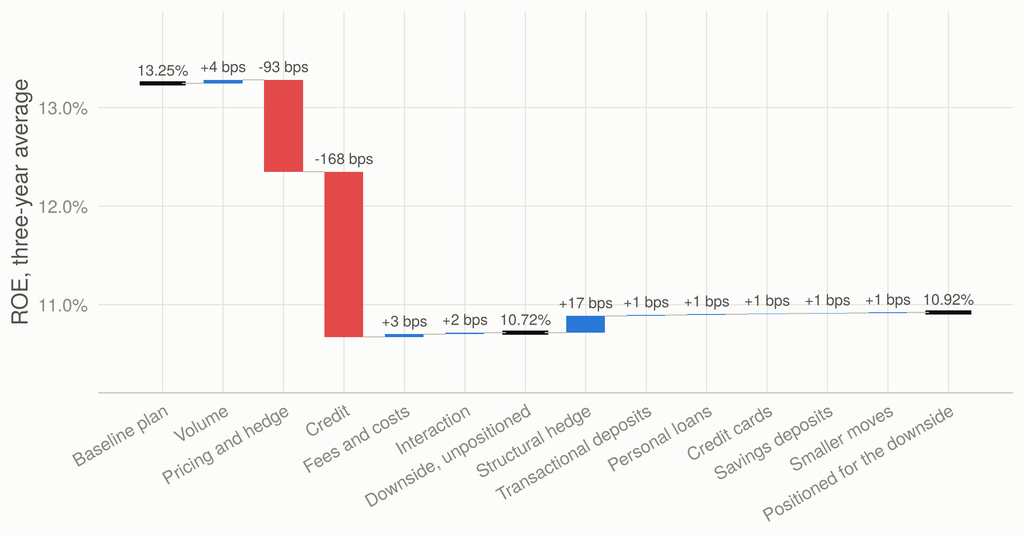

From the baseline plan to the downside, then to the downside positioned for it: three-year average ROE. Levels are marked with a bar; steps are labelled in basis points of ROE.

**Table view (1 bp of NIM-equivalent, pre-tax profit over interest-earning assets, = 9.9 bps of ROE)**

| Step | Kind | ROE | Net income, 3 years | NIM-equivalent |
| --- | --- | --- | --- | --- |
| Baseline plan | level | 13.25% | R46.3 bn | 133 bps |
| Volume | scenario | +3.6 bps | +R139 m | +0.4 bps |
| Pricing and hedge | scenario | -93.2 bps | -R3,565 m | -9.4 bps |
| Credit | scenario | -167.5 bps | -R6,373 m | -16.9 bps |
| Fees and costs | scenario | +2.7 bps | +R106 m | +0.3 bps |
| Interaction | scenario | +1.6 bps | +R137 m | +0.2 bps |
| Structural hedge | positioning | +17.0 bps | +R716 m | +1.7 bps |
| Transactional deposits | positioning | +0.9 bps | +R22 m | +0.1 bps |
| Personal loans | positioning | +0.9 bps | +R54 m | +0.1 bps |
| Credit cards | positioning | +0.7 bps | +R47 m | +0.1 bps |
| Savings deposits | positioning | +0.5 bps | +R14 m | +0.1 bps |
| Commercial property | positioning | +0.2 bps | +R1 m | +0.0 bps |
| Corporate loans | positioning | +0.2 bps | -R3 m | +0.0 bps |
| Residential mortgages | positioning | +0.1 bps | -R2 m | +0.0 bps |
| Term deposits | positioning | +0.0 bps | +R2 m | +0.0 bps |
| Vehicle and asset finance | positioning | +0.0 bps | -R2 m | +0.0 bps |
| Positioned for the downside | level | 10.92% | R37.6 bn | 110 bps |

Positioned, NGFB’s ROE in the downside is 10.9%: +21 bps better than unpositioned, or +R849 m of net income over three years, of which the hedge contributes +17 bps. That recovers 8% of the downside’s 253 bps hit: positioning cannot undo a credit cycle inside a year, and the bridge makes that visible, since the largest bar is credit and only the small unsecured trims are aimed at it.

**8. If the downside does not come.** The same moves cost 21 bps (-R718 m) if the baseline arrives instead and 48 bps (-R1,825 m) if the upside does.

**And if the SARB cuts instead?** In the variant with the same contraction but 150 bps of cuts, the optimal positioning reverses the hedge (+9.1 points of NMD instead of -9.2), shrinks deposits instead of growing them, and cuts every retail book, unsecured most (cards -0.33, personal loans -0.41). Positioning for the stagflationary downside when the cuts arrive costs 52 bps; positioning for the cuts when the hikes arrive costs 55 bps. The credit leg of a downside positioning is robust to the policy response; the rate leg is a bet on it.

## 10.5 The upside, step by step

**1. The macro path.** Inflation returns to the target sooner, the repo rate falls to 5.25% (1.00 pp below the baseline’s trough), growth averages 3.0% and house prices 7.7% a year.

**2–3. The industry and NGFB’s share.**

The sector’s projected paths in the upside against the baseline.

| Industry (Stage 1), three-year average | Baseline | Scenario | Change |
| --- | --- | --- | --- |
| Residential mortgages, growth (% a year) | 3.86 | 4.23 | +0.37 |
| Credit cards, growth | 8.47 | 9.82 | +1.35 |
| Personal loans, growth | 5.90 | 6.41 | +0.51 |
| Corporate loans, growth | 10.61 | 12.31 | +1.70 |
| Non-maturity deposits, growth | 7.56 | 8.34 | +0.79 |
| Credit-loss ratio (% of loans) | 0.88 | 0.78 | -0.10 |
| Cost of current accounts (%) | 2.66 | 2.15 | -0.52 |
| Cost of savings deposits (%) | 6.22 | 5.66 | -0.56 |
| Cost of fixed and notice deposits (%) | 7.02 | 6.09 | -0.93 |
| Home-loan yield less prime (pp) | -0.85 | -0.71 | +0.13 |
| Card yield less prime (pp) | 5.07 | 5.10 | +0.03 |
| Non-interest revenue (% of assets) | 2.24 | 2.28 | +0.04 |

Annualised growth over three years, percent, in the upside.

| Line | Sector growth | NGFB growth | NGFB share change (pp of growth) | Same, in the baseline |
| --- | --- | --- | --- | --- |
| Credit cards | 9.8 | 7.5 | -2.3 | -1.3 |
| Personal loans | 6.4 | 7.2 | +0.7 | +1.1 |
| Vehicle and asset finance | 9.1 | 8.2 | -0.9 | -0.8 |
| Residential mortgages | 4.2 | 4.5 | +0.3 | +0.4 |
| Corporate loans | 12.3 | 11.3 | -1.0 | -0.6 |
| Non-maturity deposits | 8.3 | 7.8 | -0.6 | -0.1 |

The upside has 8 easing, 4 neutral quarters. Lower rates cut deposit costs, credit losses fall by 0.10 pp of loans and volumes grow faster.

**4. NGFB without positioning.** ROE rises to 14.8% (+157 bps) and net income to R52.4 bn (+R6.1 bn): credit +102 bps, pricing and hedge +60 bps.

**5–6. Gradients and the solution.**

The upside positioning, move by move (units and conventions as for the downside).

| Move | G: engine gain per unit (bps) | c: implied cost (bps) | G - c (bps) | Execution cost (bps) | Move = (G - c) / 2 cost | Bounds | Contribution: ROE (bps) | Contribution: net income (R m) |
| --- | --- | --- | --- | --- | --- | --- | --- | --- |
| Residential mortgages | +39.8 | +40.9 | -1.1 | 8.0 | -0.07 | -2.0 to +2.0 | +0.1 | -1 |
| Vehicle and asset finance | +42.6 | +42.4 | +0.2 | 8.0 | +0.01 | -2.0 to +1.5 | 0.0 | +1 |
| Credit cards | +60.7 | +58.4 | +2.3 | 15.0 | +0.08 | -1.5 to +1.0 | +0.1 | +8 |
| Personal loans | +65.8 | +60.9 | +5.0 | 15.0 | +0.17 | -1.5 to +1.0 | +0.3 | +27 |
| Corporate loans | +45.9 | +47.2 | -1.3 | 8.0 | -0.08 | -2.0 to +2.0 | +0.1 | -1 |
| Commercial property | +34.0 | +36.3 | -2.3 | 8.0 | -0.14 | -1.5 to +1.5 | +0.2 | +2 |
| Term deposits | +7.1 | +7.3 | -0.2 | 4.0 | -0.03 | -2.0 to +2.0 | +0.0 | 0 |
| Savings deposits | +13.6 | +17.0 | -3.4 | 8.0 | -0.21 | -1.0 to +1.0 | +0.4 | +12 |
| Transactional deposits | +31.1 | +34.8 | -3.7 | 12.0 | -0.16 | -1.0 to +1.0 | +0.3 | +8 |
| Structural hedge | +5.4 | +2.9 | +2.5 | 0.2 | +6.27 | -25.0 to +25.0 | +7.8 | +359 |

The rows mirror the downside’s. The hedge is worth more than under the baseline (+5.4 bps against +2.9 bps a point), because its floating leg reprices down, so it is extended by 6.3 points, to 55.8% of NMD. Deposits are worth less as rates fall, so the bank lets 0.37% of assets of savings and transactional deposits go and funds with wholesale money; better credit makes unsecured lending worth more, so personal loans and cards grow by 0.24% of assets. Again no bound or floor binds.

**7–8. Re-run, bridge and the cost of being wrong.**

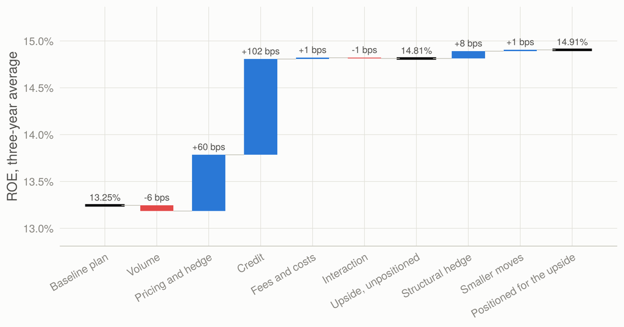

From the baseline plan to the upside, then to the upside positioned for it: three-year average ROE.

**Table view (1 bp of NIM-equivalent, pre-tax profit over interest-earning assets, = 9.9 bps of ROE)**

| Step | Kind | ROE | Net income, 3 years | NIM-equivalent |
| --- | --- | --- | --- | --- |
| Baseline plan | level | 13.25% | R46.3 bn | 133 bps |
| Volume | scenario | -6.1 bps | -R233 m | -0.6 bps |
| Pricing and hedge | scenario | +60.0 bps | +R2,323 m | +6.0 bps |
| Credit | scenario | +102.2 bps | +R3,966 m | +10.3 bps |
| Fees and costs | scenario | +1.4 bps | +R55 m | +0.1 bps |
| Interaction | scenario | -0.8 bps | +R0 m | -0.1 bps |
| Structural hedge | positioning | +7.8 bps | +R359 m | +0.8 bps |
| Personal loans | positioning | +0.3 bps | +R27 m | +0.0 bps |
| Savings deposits | positioning | +0.4 bps | +R12 m | +0.0 bps |
| Transactional deposits | positioning | +0.3 bps | +R8 m | +0.0 bps |
| Commercial property | positioning | +0.2 bps | +R2 m | +0.0 bps |
| Credit cards | positioning | +0.1 bps | +R8 m | +0.0 bps |
| Corporate loans | positioning | +0.1 bps | -R1 m | +0.0 bps |
| Residential mortgages | positioning | +0.1 bps | -R1 m | +0.0 bps |
| Term deposits | positioning | +0.0 bps | +R0 m | +0.0 bps |
| Vehicle and asset finance | positioning | +0.0 bps | +R1 m | 0.0 bps |
| Positioned for the upside | level | 14.91% | R52.8 bn | 150 bps |

Positioned, NGFB earns 14.9% in the upside, +9 bps more (+R415 m of net income). The same moves cost 9 bps if the baseline arrives and 37 bps (-R1,351 m) if the downside does.

## 10.6 The cost of being wrong

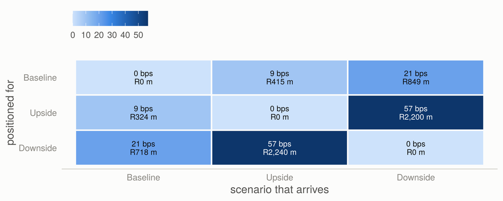

Regret: ROE given up (bps) by positioning for the scenario in the row when the scenario in the column arrives, against the best positioning for that column. Net of implied and execution costs, full engine.

The regret matrix is the honest companion to every positioning. The status quo’s worst regret is 21 bps (if the downside arrives); positioning for the downside and getting the upside instead costs 57 bps (R2,240 m of net income), and the reverse 57 bps. The two positionings are opposite bets on the same levers, so being wrong costs 2.3 times what being right earns for the downside positioning and 4.0 times for the upside’s.

## 10.7 When there is no strong view

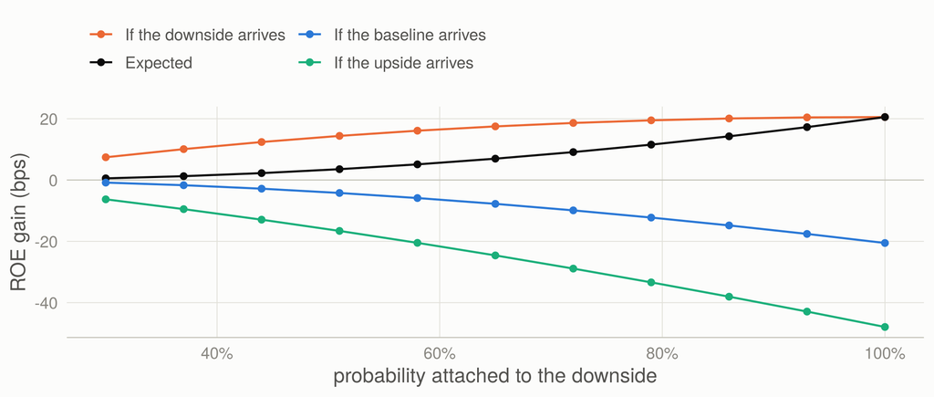

Positioning for the downside as conviction rises: the expected ROE gain (probability-weighted, net) and the gain or cost if the downside, the baseline or the upside arrives.

**Table view**

| P(downside) | Hedge, % of NMD | Unsecured lending, % of assets | Retail deposits, % of assets | Expected gain | If downside | If baseline | If upside |
| --- | --- | --- | --- | --- | --- | --- | --- |
| 30% | -1.8 | -0.10 | +0.10 | +0.6 bps | +7.4 bps | -0.8 bps | -6.3 bps |
| 37% | -2.6 | -0.14 | +0.15 | +1.3 bps | +10.1 bps | -1.7 bps | -9.5 bps |
| 44% | -3.4 | -0.18 | +0.19 | +2.3 bps | +12.4 bps | -2.8 bps | -12.9 bps |
| 51% | -4.2 | -0.21 | +0.24 | +3.5 bps | +14.4 bps | -4.2 bps | -16.6 bps |
| 58% | -4.9 | -0.25 | +0.28 | +5.1 bps | +16.1 bps | -5.9 bps | -20.5 bps |
| 65% | -5.7 | -0.29 | +0.32 | +7.0 bps | +17.5 bps | -7.8 bps | -24.6 bps |
| 72% | -6.4 | -0.32 | +0.36 | +9.1 bps | +18.6 bps | -9.9 bps | -28.9 bps |
| 79% | -7.1 | -0.36 | +0.40 | +11.5 bps | +19.5 bps | -12.2 bps | -33.4 bps |
| 86% | -7.8 | -0.39 | +0.45 | +14.3 bps | +20.1 bps | -14.8 bps | -38.1 bps |
| 93% | -8.5 | -0.42 | +0.49 | +17.3 bps | +20.4 bps | -17.6 bps | -42.9 bps |
| 100% | -9.2 | -0.46 | +0.53 | +20.5 bps | +20.5 bps | -20.5 bps | -47.9 bps |

With the scenario probabilities used here (baseline 50%, downside 30%, upside 20%), the probability-weighted positioning with variance aversion $\lambda = 4$ moves the hedge by -1.8 points of NMD and every other line by less than 0.06% of assets. The downside skew tilts it slightly defensive, but the upside and downside largely cancel, and when the bank does not know which is coming the best response is close to the plan. The framework’s value is in the other direction: it tells the ALCO what to do, and what it costs if wrong, **as conviction about a scenario builds**. Positioning scales almost linearly with conviction until a bound binds: at a 65% probability of the downside the moves are about 61% of the full-conviction positioning.

## 10.8 More aggressive?

Being more aggressive does move the numbers more, in both directions, and how much depends on what “more aggressive” means. There are two different dials.

**Bigger moves at the same cost.** Take the optimal downside positioning and scale it by a factor $\alpha$. The benefit if the downside arrives grows in proportion to $\alpha$, but the execution cost grows with its square, so the net gain is $(2\alpha - \alpha^2)$ times the optimum’s: it peaks at the optimum, is gone at twice the optimal size, and turns negative beyond. The loss if the scenario does not arrive keeps growing all the while.

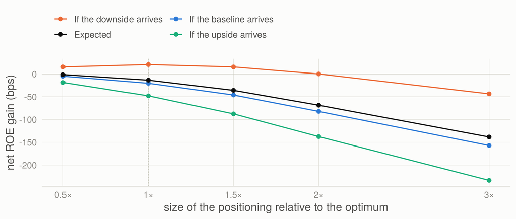

Scaling the optimal downside positioning up and down at the same execution cost: net ROE gain if each scenario arrives, and the probability-weighted expectation.

**Table view: net gain by size of the downside positioning**

| Size | If baseline arrives (ROE / net income) | If upside arrives (ROE / net income) | If downside arrives (ROE / net income) | Hedge |
| --- | --- | --- | --- | --- |
| 0.5× | -5 bps / -R179 m | -19 bps / -R731 m | +15 bps / +R600 m | -4.6 |
| 1× | -21 bps / -R718 m | -48 bps / -R1,825 m | +21 bps / +R849 m | -9.2 |
| 1.5× | -46 bps / -R1,615 m | -88 bps / -R3,283 m | +15 bps / +R745 m | -13.8 |
| 2× | -82 bps / -R2,871 m | -138 bps / -R5,103 m | +0 bps / +R290 m | -18.4 |
| 3× | -157 bps / -R5,483 m | -234 bps / -R8,577 m | -44 bps / -R1,093 m | -25.0 |

**A bank that can move faster or more cheaply.** A bank with spare deposit franchise, an underwriting machine ready to scale, or a longer runway can execute the same moves for less. The optimiser then chooses bigger moves: halve the execution costs and the moves, the gain if right and the loss if wrong all double, until a bound binds.

Positioning for the downside when execution is cheaper (and, in the last rows, the bounds are doubled, so the hedge may go from 0% to 100% of NMD): the moves and the net ROE gain if each scenario arrives.

| Execution cost | Bounds | Hedge (pp of NMD) | Unsecured lending (% of assets) | Retail deposits (% of assets) | If downside (bps) | If baseline (bps) | If upside (bps) | Expected (bps) | At a bound |
| --- | --- | --- | --- | --- | --- | --- | --- | --- | --- |
| 1× | as set | -9.2 | -0.46 | +0.53 | +21 | -21 | -48 | -13.8 | nothing |
| 0.5× | as set | -18.4 | -0.91 | +1.05 | +41 | -41 | -97 | -27.6 | nothing |
| 0.25× | as set | -25.0 | -1.82 | +2.00 | +75 | -45 | -126 | -25.2 | hedge, savings, transactional |
| 0.1× | as set | -25.0 | -3.00 | +2.00 | +107 | -26 | -114 | -4.1 | cards, personal loans, hedge, commercial property, savings, transactional |
| 0.25× | doubled | -36.9 | -1.82 | +2.10 | +82 | -83 | -194 | -55.7 | nothing |
| 0.1× | doubled | -50.0 | -4.56 | +4.00 | +167 | -79 | -246 | -38.7 | hedge, savings, transactional |

**Table view: the same in net income over three years**

| Execution cost | Bounds | If downside (R m) | If upside (R m) |
| --- | --- | --- | --- |
| 1× | as set | +849 | -1825 |
| 0.5× | as set | +1698 | -3650 |
| 0.25× | as set | +2983 | -4763 |
| 0.1× | as set | +4090 | -4380 |
| 0.25× | doubled | +3395 | -7300 |
| 0.1× | doubled | +6643 | -9271 |

At a quarter of the cost, the hedge hits its policy floor and the downside positioning earns +75 bps (+R2,983 m) if the downside comes, but loses 126 bps (-R4,763 m) if the upside comes. With a tenth of the cost and doubled bounds, which means taking the hedge off entirely, the numbers become +167 bps against -246 bps. The same pattern holds for the upside positioning (+36 bps if right, -146 bps if the downside arrives, at a quarter of the cost).

Three things stop aggressiveness from being free:

- **The loss if wrong grows faster than the gain if right.** The upside and the downside move the same levers in opposite directions, so a bigger downside bet loses more in the upside than it makes in the downside, and with a 30% chance of the downside the probability-weighted value of full-conviction positioning is negative at every size (-13.8 bps at the optimum); the probability-weighted positioning in the previous section is the one that adds value on average.
- **Bounds bind before capital or liquidity do.** Even the most aggressive setting leaves the CET1 trough above 12.2% and the LCR trough above 169%; what stops the moves is the hedge policy and the speed at which a franchise can grow or shrink a book.
- **The answer is only as good as the costs.** The execution costs are assumptions about franchise capacity, and the size of every lending move scales with them. Their direction does not depend on them; their size does.

The optimiser’s linear model stays close to the full engine for moderate settings (within 1.10 bps of ROE down to a quarter of the cost) but drifts at the extremes (up to 4.2 bps when the bounds are doubled and the hedge is pushed towards 0% or 100% of NMD), which is why every number above is the full engine’s, not the linear model’s.

# 11 Market share and market growth: where NGFB should lean in

The positioning chapter moved NGFB’s balance sheet ahead of a scenario. This chapter asks the commercial question underneath it: in which products, and in which phases of the cycle, does NGFB grow more slowly than its market and its peers – and is it worth fixing?

Two numbers place NGFB in each product and regime. The first is how fast the **market** grows in that regime, from the sector’s history (Stage 1’s territory: no bank controls it). The second is NGFB’s **share effect**, how much faster or slower than the market its book grows (Stage 2), compared with the population of large banks it was drawn from. That population gives a *par* (the typical large bank), a spread, and NGFB’s percentile in it; only population hyperparameters are used, never an individual bank’s estimate. NGFB’s structural share drift is left out throughout, so every comparison is about the cycle, not about trend share gains.

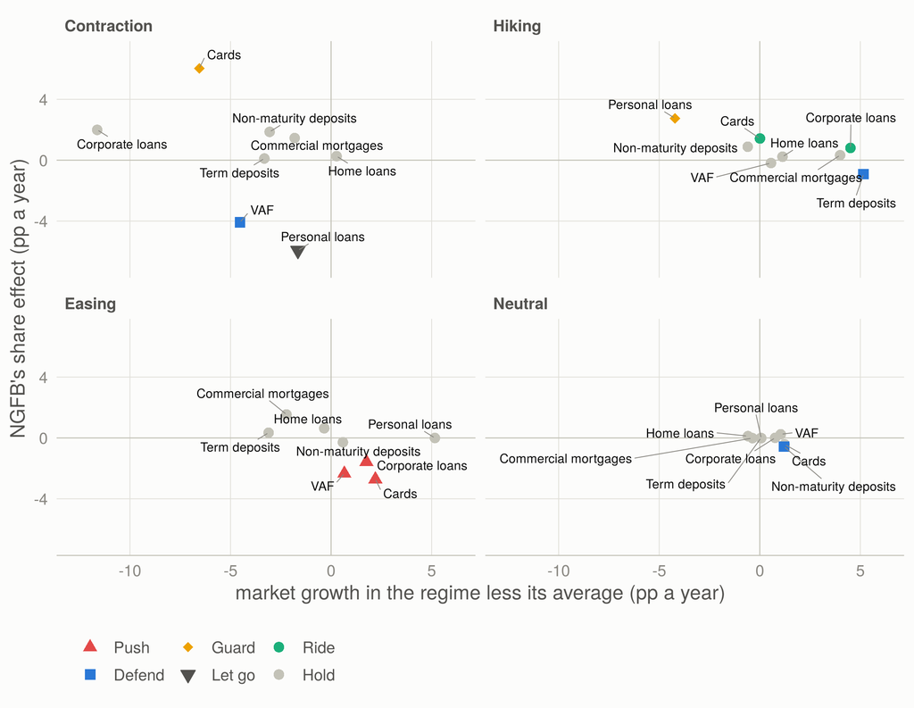

Market growth against NGFB’s share effect, by macro regime. Horizontal axis: how much faster the market grows in the regime than on average; vertical axis: NGFB’s growth relative to the market (percentage points a year). Bottom right: the market grows and NGFB loses share.

**Table view: every product and regime**

| Product | Regime | Market growth (% a year) | NGFB share effect (pp) | Par (pp) | Percentile | Action |
| --- | --- | --- | --- | --- | --- | --- |
| Term deposits | Contraction | 2.5 | +0.11 | -0.47 | 56% | Hold |
| Term deposits | Easing | 2.7 | +0.34 | +1.62 | 38% | Hold |
| Term deposits | Hiking | 11.0 | -0.92 | +0.57 | 29% | Defend |
| Term deposits | Neutral | 5.9 | -0.01 | 0.00 | 34% | Hold |
| Cards | Contraction | 0.3 | +6.03 | +1.30 | 75% | Guard |
| Cards | Easing | 9.1 | -2.71 | -2.18 | 46% | Push |
| Cards | Hiking | 6.9 | +1.43 | +1.20 | 58% | Ride |
| Cards | Neutral | 8.1 | -0.42 | -0.50 | 58% | Hold |
| Corporate loans | Contraction | -4.0 | +1.99 | +0.46 | 62% | Hold |
| Corporate loans | Easing | 9.4 | -1.57 | -0.34 | 34% | Push |
| Corporate loans | Hiking | 12.2 | +0.81 | -0.27 | 72% | Ride |
| Corporate loans | Neutral | 8.4 | +0.01 | -0.05 | 67% | Hold |
| Commercial mortgages | Contraction | 4.9 | +1.46 | +0.26 | 74% | Hold |
| Commercial mortgages | Easing | 4.5 | +1.54 | +1.48 | 52% | Hold |
| Commercial mortgages | Hiking | 10.7 | +0.33 | +0.28 | 51% | Hold |
| Commercial mortgages | Neutral | 6.4 | -0.01 | +0.02 | 33% | Hold |
| Home loans | Contraction | 4.1 | +0.26 | +0.70 | 21% | Hold |
| Home loans | Easing | 3.5 | +0.63 | +0.34 | 66% | Hold |
| Home loans | Hiking | 4.9 | +0.23 | +0.08 | 58% | Hold |
| Home loans | Neutral | 3.2 | +0.12 | +0.08 | 55% | Hold |
| Non-maturity deposits | Contraction | 4.1 | +1.86 | +1.05 | 70% | Hold |
| Non-maturity deposits | Easing | 7.7 | -0.29 | -0.13 | 45% | Hold |
| Non-maturity deposits | Hiking | 6.5 | +0.89 | +0.33 | 69% | Hold |
| Non-maturity deposits | Neutral | 8.3 | -0.57 | -0.23 | 19% | Defend |
| Personal loans | Contraction | 6.7 | -5.93 | +1.34 | 26% | Let go |
| Personal loans | Easing | 13.5 | 0.00 | -1.16 | 66% | Hold |
| Personal loans | Hiking | 4.2 | +2.75 | +4.47 | 24% | Guard |
| Personal loans | Neutral | 8.4 | -0.01 | -0.03 | 77% | Hold |
| VAF | Contraction | 1.2 | -4.08 | -2.33 | 18% | Defend |
| VAF | Easing | 6.4 | -2.34 | -1.23 | 40% | Push |
| VAF | Hiking | 6.3 | -0.19 | +0.24 | 41% | Hold |
| VAF | Neutral | 6.8 | +0.24 | +0.12 | 69% | Hold |

The rules that turn a cell into an action are economic, not statistical. A share **loss** in a regime where the market grows at or above its average is under-participation: the cheapest growth NGFB forgoes, so **push**. A share **gain** in unsecured lending while the market weakens is a warning: NGFB may be booking the business others decline, so **guard**. Ceding unsecured share in a contraction is the risk appetite working: **let go**. Losing share in a weak market for a secured or funding product means competitors are taking good-quality business: **defend**. Gains in a growing market: **ride**, with capacity and pricing discipline.

The share playbook: every product and regime where NGFB should act. Who gains: the peer groups that take the share NGFB loses in that regime (proportional convention; history with NGFB embedded).

| Action | Product | Regime | Market growth (% a year) | NGFB vs market (pp a year) | Typical large bank (pp) | Percentile | Who gains NGFB’s loss | Why |
| --- | --- | --- | --- | --- | --- | --- | --- | --- |
| Push | Cards | Easing | 9.1 | -2.7 | -2.2 | 46% | Challengers (100%) | Losing share when the market grows fastest: the cheapest growth NGFB forgoes. |
| Push | Corporate loans | Easing | 9.4 | -1.6 | -0.3 | 34% | Other (50%), Specialists (34%), Challengers (16%) | Losing share when the market grows fastest: the cheapest growth NGFB forgoes. |
| Push | VAF | Easing | 6.4 | -2.3 | -1.2 | 40% | Challengers (50%), Big Four (50%) | Losing share when the market grows fastest: the cheapest growth NGFB forgoes. |
| Defend | Term deposits | Hiking | 11.0 | -0.9 | +0.6 | 29% | Big Four (100%) | Losing deposit share in a growing deposit market: funding NGFB will later buy wholesale. |
| Defend | Non-maturity deposits | Neutral | 8.3 | -0.6 | -0.2 | 19% | Challengers (98%) | Losing deposit share in a growing deposit market: funding NGFB will later buy wholesale. |
| Defend | VAF | Contraction | 1.2 | -4.1 | -2.3 | 18% | Specialists (97%) | Losing share in a weak market: competitors are taking good-quality business. |
| Guard | Cards | Contraction | 0.3 | +6.0 | +1.3 | 75% | – | Gaining unsecured share while the market weakens: check it is not the business others decline. |
| Guard | Personal loans | Hiking | 4.2 | +2.8 | +4.5 | 24% | – | Gaining unsecured share while the market weakens: check it is not the business others decline. |
| Let go | Personal loans | Contraction | 6.7 | -5.9 | +1.3 | 26% | Challengers (76%), Specialists (23%) | Ceding unsecured share in a contraction is risk appetite working, not a weakness. |
| Ride | Cards | Hiking | 6.9 | +1.4 | +1.2 | 58% | – | Gaining share in a growing market: keep capacity and pricing discipline. |
| Ride | Corporate loans | Hiking | 12.2 | +0.8 | -0.3 | 72% | – | Gaining share in a growing market: keep capacity and pricing discipline. |

**The gap is in easing cycles.** When rates fall, the card market grows 9.1% a year against an average of 6.9%, yet NGFB’s card book grows 271 bps a year more slowly than the market (46% percentile). It is not alone: the typical large bank loses 218 bps a year of card growth in an easing cycle too, and the Challengers take 100% of what NGFB loses. Corporate loans (-1.6 pp a year, 34% percentile) and vehicle and asset finance (-2.3 pp, 40% percentile) follow the same pattern, in markets growing 9.4% and 6.4% a year. In hiking cycles the picture reverses: NGFB gains card share (+1.4 pp a year), so the pattern a bank might expect – losing cards when rates are high – is not NGFB’s problem; losing them when rates fall is.

## 11.1 Is it worth pushing?

Share is worth buying only if the extra business earns more than it costs at the margin. The scenario engine is the wrong tool for that question: it grows NGFB’s treasury and other assets along with its loan book, which is right for a scenario but not for a single-product decision. So each product’s marginal economics are built up directly, per rand of balance: the yield, less the funds-transfer price (the marginal wholesale rate), less the cost of the HQLA buffer that wholesale funding needs for its 30-day runoff, less expected losses at the product’s loss rate, after tax, less a charge for the capital it consumes at a 12.5% CET1 target and a 14.5% cost of equity. Deposits earn the funding they displace. The BA returns carry no costs by product, so the result is a contribution *before* operating costs: the most it could cost to originate and service the business before it destroys value (the headroom).

In symbols, per rand of balance and in percent a year,

$$\text{headroom} \;=\; r \;-\; f \;-\; \ell\,(f - r_{H}) \;-\; \text{EL} \;-\; \frac{k\,\rho\,\big(\text{CoE} - (1-\tau)\,f\big)}{1-\tau} .$$

A rand of new lending earns its rate $r$. It costs the marginal funding rate $f$, the funds-transfer price. It also costs the liquidity that funding needs: a quarter ($\ell$ = 25%) of a rand of wholesale funding must sit in HQLA earning $r_H$ rather than $f$. It loses its expected credit loss, EL. And it ties up capital: at a 12.5% CET1 target ($k$) and the product’s risk weight $\rho$, that capital costs the 14.5% cost of equity less the after-tax funding it saves, and dividing by $1-\tau$ grosses the charge up to a pre-tax rate like everything else. What is left is the most the business could cost to originate and service before it destroys value. In the table below every column is in percent a year of the balance, and the headroom is the rate less the other four.

Marginal economics in the baseline, percent a year of balance (three-year averages). Headroom: the rate less the other four columns, a pre-tax contribution before operating costs; the capital charge is grossed up to a pre-tax rate. ‘Own deposits’: the push brings matching deposits, funded at NGFB’s average cost of funds.

| Product | Rate (%) | FTP (%) | Liquidity buffer | Expected loss | Capital charge (pre-tax) | Headroom, wholesale funding | Headroom, own deposits |
| --- | --- | --- | --- | --- | --- | --- | --- |
| Home loans | 9.36 | 7.90 | 0.66 | 0.27 | 0.35 | +0.19 | +2.69 |
| Commercial mortgages | 9.16 | 7.90 | 0.66 | 0.38 | 0.72 | -0.49 | +1.94 |
| VAF | 10.68 | 7.90 | 0.66 | 1.29 | 0.78 | +0.05 | +2.46 |
| Cards | 15.28 | 7.90 | 0.66 | 4.31 | 0.71 | +1.70 | +4.13 |
| Personal loans | 18.21 | 7.90 | 0.66 | 7.00 | 0.78 | +1.87 | +4.29 |
| Corporate loans | 10.60 | 7.90 | 0.66 | 0.57 | 0.57 | +0.91 | +3.36 |
| Non-maturity deposits | 5.02 | 7.90 | 0.72 | 0.00 | 0.00 | +2.16 | – |
| Term deposits | 7.15 | 7.90 | 0.19 | 0.00 | 0.00 | +0.57 | – |

Cards clear the bar comfortably even on wholesale funding (+1.7 pp of headroom). Corporate lending clears it only narrowly (+0.9 pp) and vehicle and asset finance barely at all (+0.05 pp); with matching deposits both have 3.4 and 2.5 pp to spare. The commercial lesson is the same for every secured product: at NGFB’s margins, lending growth pays when it brings its own funding.

What closing each gap is worth: contribution over three years, before operating costs, if NGFB’s share effect in that regime moved to the typical large bank’s (par) or to a top-quintile bank’s (frontier). Only scenarios that contain the regime are shown.

| Strategy | Scenario | Extra book at the frontier (R bn) | To par, wholesale (R m) | To par, own deposits (R m) | To the frontier, wholesale (R m) | To the frontier, own deposits (R m) |
| --- | --- | --- | --- | --- | --- | --- |
| Term deposits, hiking | Baseline | 7.3 | +26 | – | +83 | – |
| Term deposits, hiking | Downside | 11.1 | +27 | – | +85 | – |
| Cards, easing | Baseline | 6.4 | +14 | +34 | +106 | +252 |
| Cards, easing | Upside | 8.8 | +30 | +59 | +223 | +436 |
| Corporate loans, easing | Baseline | 19.4 | +58 | +209 | +170 | +610 |
| Corporate loans, easing | Upside | 27.1 | +106 | +328 | +311 | +965 |
| VAF, contraction | Downside | 3.8 | -4 | +43 | -8 | +89 |
| VAF, easing | Baseline | 6.1 | +2 | +35 | +9 | +147 |
| VAF, easing | Upside | 8.5 | +9 | +57 | +36 | +240 |

Moving every push and defend cell to par adds +R101 m to +R278 m of contribution over three years in the baseline (+4 bps to +10 bps of ROE before operating costs), and +R145 m to +R444 m in the upside, whose eight easing quarters are where the gaps sit. These are modest because NGFB is a typical large bank by construction: the prize is in moving to the frontier, where corporate lending alone is worth +R965 m in the upside if the book brings its deposits.

**Defend: term deposits when rates rise.** In hiking cycles the term-deposit market grows 11.0% a year and NGFB’s share falls (-0.9 pp a year against a par of +0.6). Each rand of term deposits displaces wholesale funding with 0.6 pp of headroom, so price-matching term deposits in a hiking cycle pays as long as gathering them costs less than that.

**Caveats**

The positioning comes from NGFB’s drawn share parameters, which are a typical large bank’s behaviour plus a random deviation (seed 20260622); a real bank would use its own estimates. Share effects are averages over the regime’s history, with wide uncertainty for unsecured products. Contributions exclude operating costs and fee income, both of which the returns do not report by product, and the frontier is a statistical construct (the 80th percentile of the population’s predictive distribution), not a named competitor.

# 12 Macro-adjusted performance: could NGFB have done better?

A product’s growth is the market’s growth plus the bank’s share effect. The first part is the macro environment: Stage 1 says what the industry does in a scenario, and no bank controls it. The second is what management controls, and Stage 2 says what a typical large bank achieves in the same regimes. So performance can be judged against two macro-adjusted benchmarks: **par**, the share effect of the typical large bank, and the **frontier**, that of a top-quintile large bank (the 80th percentile of the population’s posterior predictive). NGFB’s percentile says how much better it could have done; the gap to the frontier says by how much. Over a scenario the benchmarks are summed quarter by quarter along its sequence of regimes and market growth, exactly as NGFB’s own share effect is.

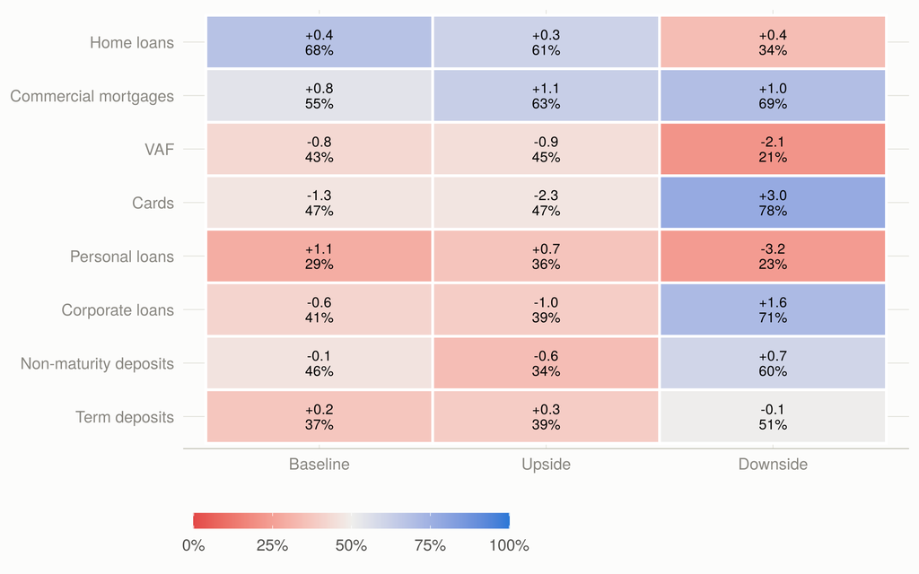

NGFB’s share performance by scenario against the large-bank population: percentile of NGFB’s share effect (blue above par, red below), labelled with the effect in percentage points a year.

**Table view: scorecards**

| Scenario | Product | Market growth (% a year) | NGFB growth | Share effect (pp) | Par (pp) | Frontier (pp) | Percentile | Verdict |
| --- | --- | --- | --- | --- | --- | --- | --- | --- |
| Baseline | Home loans | 3.9 | 4.2 | +0.35 | +0.18 | +0.49 | 68% | Above par |
| Baseline | Commercial mortgages | 6.7 | 7.5 | +0.84 | +0.77 | +1.29 | 55% | Above par |
| Baseline | VAF | 7.9 | 7.1 | -0.80 | -0.37 | +1.54 | 43% | Below par |
| Baseline | Cards | 8.5 | 7.2 | -1.29 | -1.10 | +1.02 | 47% | Below par |
| Baseline | Personal loans | 5.9 | 7.0 | +1.06 | +1.84 | +3.01 | 29% | Well below par |
| Baseline | Corporate loans | 10.6 | 10.0 | -0.64 | -0.30 | +1.05 | 41% | Below par |
| Baseline | Non-maturity deposits | 7.6 | 7.4 | -0.11 | -0.06 | +0.45 | 46% | Below par |
| Baseline | Term deposits | 4.0 | 4.2 | +0.21 | +0.96 | +2.83 | 37% | Below par |
| Upside | Home loans | 4.2 | 4.5 | +0.29 | +0.14 | +0.58 | 61% | Above par |
| Upside | Commercial mortgages | 7.9 | 9.1 | +1.13 | +0.85 | +1.55 | 63% | Above par |
| Upside | VAF | 9.1 | 8.2 | -0.90 | -0.48 | +2.06 | 45% | Below par |
| Upside | Cards | 9.8 | 7.5 | -2.32 | -2.06 | +0.81 | 47% | Below par |
| Upside | Personal loans | 6.4 | 7.2 | +0.75 | +1.31 | +2.64 | 36% | Below par |
| Upside | Corporate loans | 12.3 | 11.3 | -1.02 | -0.44 | +1.36 | 39% | Below par |
| Upside | Non-maturity deposits | 8.3 | 7.8 | -0.59 | -0.25 | +0.46 | 34% | Below par |
| Upside | Term deposits | 3.6 | 3.8 | +0.26 | +1.09 | +3.53 | 39% | Below par |
| Downside | Home loans | 3.3 | 3.7 | +0.43 | +0.61 | +0.98 | 34% | Below par |
| Downside | Commercial mortgages | 4.8 | 5.8 | +0.99 | +0.33 | +1.42 | 69% | Above par |
| Downside | VAF | 5.9 | 3.8 | -2.07 | -1.14 | -0.18 | 21% | Well below par |
| Downside | Cards | 6.4 | 9.4 | +3.04 | -0.42 | +3.40 | 78% | Near the frontier |
| Downside | Personal loans | 5.4 | 2.3 | -3.15 | +2.31 | +8.63 | 23% | Well below par |
| Downside | Corporate loans | 8.9 | 10.5 | +1.59 | -0.23 | +2.49 | 71% | Near the frontier |
| Downside | Non-maturity deposits | 6.5 | 7.2 | +0.70 | +0.48 | +1.18 | 60% | Above par |
| Downside | Term deposits | 4.7 | 4.6 | -0.11 | -0.16 | +2.00 | 51% | Above par |

**In the downside**, most of the slowdown in NGFB’s books is the market’s. Home-loan growth falls 47 bps a year against the baseline, all of it market (-0.55 pp) – but even so NGFB is below par in home loans (34% percentile), because a typical large bank *gains* mortgage share in a contraction as lenders retreat to secured credit, and NGFB gains less: in a downturn NGFB should lean into home loans, with deposit funding (the wholesale headroom is thin). Cards are near the frontier (78% percentile, 0.4 pp a year short of it), with corporate loans and commercial mortgages close behind (71%): on share, NGFB could hardly have done better – and in cards that is precisely the guard case of the previous chapter. Vehicle and asset finance and personal loans are well below par.

**In the upside**, the growth is in cards, corporate lending and vehicle and asset finance, and NGFB is below par in all three: in cards the market adds +1.4 pp a year to growth against the baseline and NGFB’s share takes -1.0 pp back. The upside’s message for management is to protect share where the growth is, not to bank the tide.

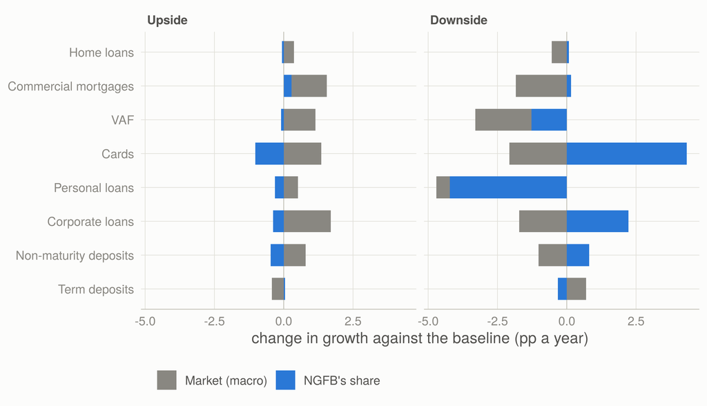

Change in NGFB’s annual growth against the baseline, split into the market (macro: no bank controls it) and NGFB’s share effect (management).

**Table view: attribution against the baseline**

| Scenario | Product | Change in growth (pp) | Market (pp) | Share (pp) |
| --- | --- | --- | --- | --- |
| Upside | Term deposits | -0.38 | -0.43 | +0.05 |
| Upside | Cards | +0.32 | +1.35 | -1.03 |
| Upside | Corporate loans | +1.32 | +1.70 | -0.38 |
| Upside | Commercial mortgages | +1.55 | +1.27 | +0.29 |
| Upside | Home loans | +0.32 | +0.37 | -0.06 |
| Upside | Non-maturity deposits | +0.31 | +0.79 | -0.48 |
| Upside | Personal loans | +0.20 | +0.51 | -0.31 |
| Upside | VAF | +1.04 | +1.14 | -0.10 |
| Downside | Term deposits | +0.37 | +0.69 | -0.32 |
| Downside | Cards | +2.26 | -2.07 | +4.33 |
| Downside | Corporate loans | +0.51 | -1.72 | +2.23 |
| Downside | Commercial mortgages | -1.68 | -1.84 | +0.15 |
| Downside | Home loans | -0.47 | -0.55 | +0.08 |
| Downside | Non-maturity deposits | -0.21 | -1.02 | +0.81 |
| Downside | Personal loans | -4.70 | -0.48 | -4.22 |
| Downside | VAF | -3.29 | -2.02 | -1.27 |

## 12.1 Using it to set and judge targets

The same split turns into a macro-adjusted target. For product $p$ in quarter $t$:

$$\text{target}_{p,t} = \underbrace{g^{\text{market}}_{p,t}}_{\text{realised, from the returns}} + \underbrace{\text{par}_{p}(\text{regime}_t)}_{\text{Stage 2}} + \text{ambition}_p,$$

and performance is actual growth less the target. The market term is measured after the fact, so a bank is neither punished for a recession nor rewarded for a boom; the par term adjusts for what a typical large bank does in that phase of the cycle; the ambition is management’s choice (for NGFB, the gap to the frontier). Set in advance, the scorecards above become scenario-contingent targets: in a downside, a home-loan share gain of at least par; in an upside, no loss of card or corporate share.

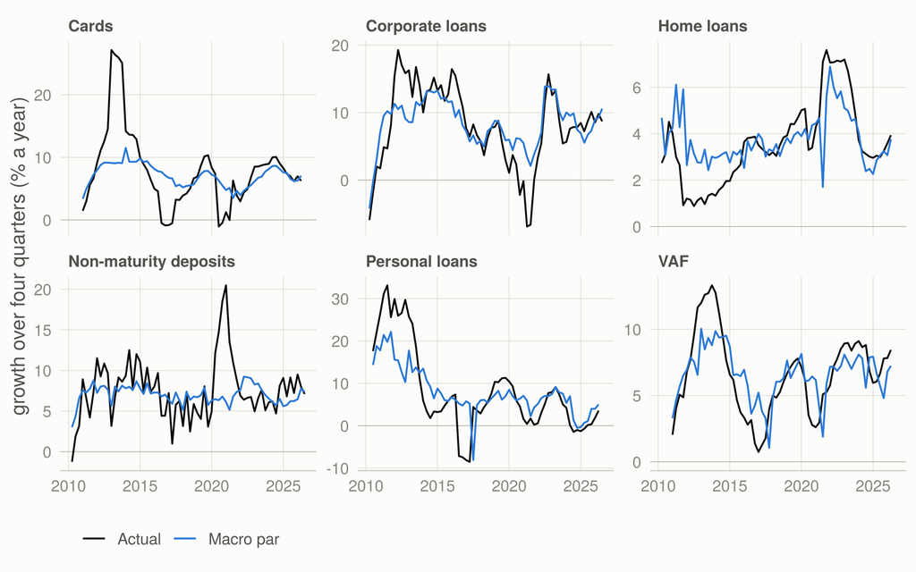

The industry against macro par: actual growth over four quarters against what each Stage 1 model implied from the realised macro path (simulated four quarters ahead from each quarter), selected products.

Over the last three years the industry beat macro par in cards (+0.6 pp a year), vehicle and asset finance and deposits, and fell short in personal loans by 2.2 pp a year: lenders tightened unsecured credit by more than growth, rates and unemployment alone explain. The same comparison, run for a bank’s own books, is the macro-adjusted scorecard: it separates the tide from the swimming.

# 13 Are the numbers right?

## 13.1 The hedge was priced off the wrong curve

The proxy that priced the hedge was

$$s^{\text{proxy}}_{5} \;=\; \text{JIBAR} \;+\; 0.55\,\big(y^{\text{gov}}_{10} - \text{JIBAR}\big)$$

that is, the three-month rate plus a fixed share of the ten-year bond’s spread over it. It looks innocent and is not: pricing a swap off the bond curve is like pricing a Polo’s insurance off a Range Rover’s quote. Same road, different risk.

Until this version the structural hedge’s swap rates came from a proxy inside the government curve, JIBAR plus 0.55 times the gap between the 10-year bond yield and JIBAR, because no free swap series was at hand. Daily JIBAR swap fixings are now published by rbond.co.za (from September 2023, with generic government yields from 2018), and against them the proxy fails:

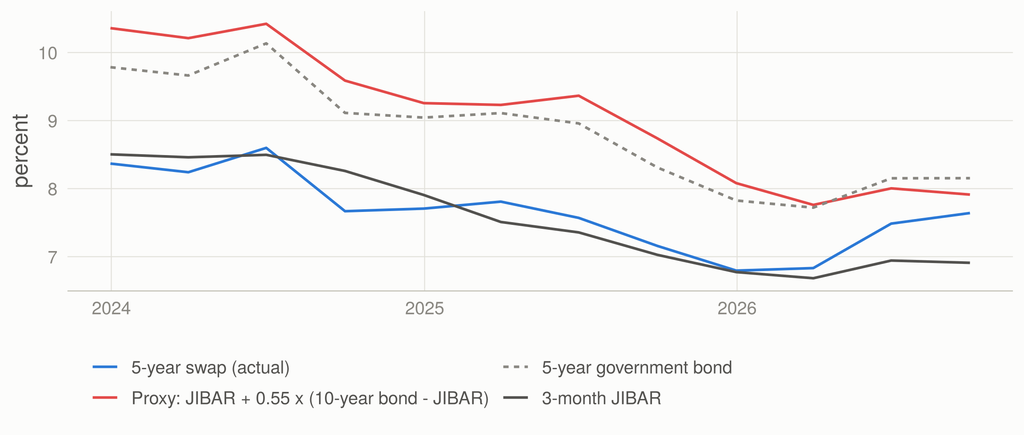

The 5-year JIBAR swap rate (quarterly average of daily fixings) against the proxy that priced the hedge up to the previous version, with 3-month JIBAR and the 5-year government yield. Source: rbond.co.za (CC BY 4.0), SARB, FRED.

**Table view**

| Quarter | 3-month JIBAR | 5-year swap | Proxy | Proxy error | 5-year government |
| --- | --- | --- | --- | --- | --- |
| 2023Q4 | 8.50 | 8.37 | 10.36 | 1.99 | 9.78 |
| 2024Q1 | 8.46 | 8.24 | 10.21 | 1.97 | 9.66 |
| 2024Q2 | 8.50 | 8.60 | 10.42 | 1.82 | 10.14 |
| 2024Q3 | 8.26 | 7.67 | 9.59 | 1.92 | 9.11 |
| 2024Q4 | 7.91 | 7.71 | 9.26 | 1.55 | 9.04 |
| 2025Q1 | 7.51 | 7.81 | 9.23 | 1.42 | 9.11 |
| 2025Q2 | 7.36 | 7.57 | 9.37 | 1.80 | 8.96 |
| 2025Q3 | 7.03 | 7.16 | 8.74 | 1.58 | 8.31 |
| 2025Q4 | 6.77 | 6.80 | 8.08 | 1.29 | 7.83 |
| 2026Q1 | 6.68 | 6.83 | 7.76 | 0.93 | 7.72 |
| 2026Q2 | 6.94 | 7.49 | 8.00 | 0.52 | 8.15 |
| 2026Q3 | 6.91 | 7.64 | 7.91 | 0.27 | 8.15 |

The proxy overstated the 5-year swap rate in every quarter, by 0.3 to 2.0 percentage points (1.4 pp on average). The reason is structural, not noise: South African government bonds carry a fiscal risk premium over swaps, and the 5-year bond traded 0.5–1.6 pp above the 5-year swap over 2023–2026, the gap narrowing as the bond rally of 2025–26 compressed the premium. A curve built inside the bond curve inherits that premium. The swap curve itself is close to flat out to five years and rises after it:

Swap rates less 3-month JIBAR, 2023Q4-2026Q2 (quarterly averages; what the scenarios use), and two candidate drivers of each tenor’s spread, tested on 36 monthly averages with HAC standard errors: the government curve’s slope and, under perfect foresight, the change in the repo rate over the following twelve months (25 months).

| Tenor | Mean spread over JIBAR (pp) | Range | Gov. slope: coefficient (HAC t) | Coming year’s policy path: coefficient (HAC t) |
| --- | --- | --- | --- | --- |
| 1 year | -0.18 | -0.57 to 0.31 | -0.09 (-0.7) | 0.54 (2.8) |
| 2 years | -0.30 | -0.85 to 0.37 | -0.15 (-0.8) | 0.44 (1.3) |
| 3 years | -0.27 | -0.88 to 0.40 | -0.13 (-0.7) | 0.40 (1.0) |
| 5 years | 0.03 | -0.59 to 0.54 | -0.02 (-0.1) | 0.43 (1.0) |
| 10 years | 1.01 | 0.47 to 1.39 | 0.29 (3.0) | 0.48 (1.0) |

The relationship the scenarios now use is the simplest one the data support: each swap rate is the floating benchmark plus its tenor’s average spread over JIBAR, so a scenario’s policy path (which it fixes) fixes the whole curve. From 2027 the benchmark is compounded ZARONIA plus 16.19 bp and the swap rates are on the same JIBAR-equivalent basis: a new receive-fixed hedge is then a ZARONIA overnight-index swap struck at about the JIBAR swap rate less 16.19 bp, paying ZARONIA, which earns the same carry as receiving the JIBAR-equivalent rate against ZARONIA plus 16.19 bp. Neither candidate driver is significant at the three- and five-year points where the hedge is struck; the coming year’s policy path explains the one-year spread ($t$ = 2.8) and the government slope the ten-year ($t$ = 3.0), which matter only for the tenor lever in More levers.

The hedge book’s fixed rate is the average 5-year swap rate over the twenty quarters in which its tranches were struck: actual fixings for the 11 quarters from 2023Q4, and for the 9 earlier quarters the 5-year government yield less the average swap spread to it (1.24 pp). Two other back-casts raise the result by at most 0.14 pp, against the proxy’s 1.28.

The 5-year boxcar’s average fixed rate at the jump-off: 11 quarters of actual swap fixings and 9 back-cast.

| Book’s fixed rate | Percent | Against the proxy (pp) |
| --- | --- | --- |
| Actual swaps, back-cast with the average swap-bond spread (used) | 7.60 | -1.28 |
| Actual swaps, back-cast with a regression on the 5-year bond and JIBAR | 7.68 | -1.20 |
| Actual swaps, back-cast with the last year’s swap-bond spread | 7.73 | -1.14 |
| Previous version: the government-curve proxy | 8.87 | 0.00 |

What the correction does: NGFB’s three-year results with the hedge priced off the government-curve proxy (fixed rate and reinvestment) and off actual swaps, everything else as in this version.

| Scenario | ROE, proxy curve | ROE, actual swaps | Change | Net income, 3 years: change | NIM, actual swaps | Hedge carry, 3 years | ROE without a hedge |
| --- | --- | --- | --- | --- | --- | --- | --- |
| Baseline | 15.9% | 13.2% | -265 bps | -R10.4 bn | 3.16% | R6.8 bn | 11.8% |
| Upside | 17.4% | 14.8% | -255 bps | -R10.3 bn | 3.21% | R13.1 bn | 12.1% |
| Downside | 13.7% | 10.7% | -299 bps | -R11.3 bn | 3.04% | R-1.7 bn | 11.1% |

**The correction lowers NGFB’s ROE by 265 bps in the baseline** (R10.4 bn of net income over three years) and by similar amounts in the other scenarios. It is the largest single change in this version, and it changes the story of the previous one: NGFB’s returns above the sector’s were mostly the proxy’s excess carry, not the hedge.

## 13.2 A broken equity series

Equity-price growth is a candidate driver of several sector models, standing in for household wealth and corporate confidence. Until this version it came from the SARB’s series of the FTSE/JSE All Share index (JLE2001M), which has three level breaks that are not market moves: -42% in March 2017, -39% in October 2021 and +43% in March 2023, months in which the OECD’s all-share price index for South Africa moved by -0.6%, +2.6% and -4.1%. In annual growth the breaks became gaps of up to 60 points between the two series: the models saw equity crashes of 40–55% through 2017–18 and 2021–22, and a 50% boom in 2023, that never happened. Between the breaks the series also drifts from the OECD index, by up to 20 points of annual growth in 2019.

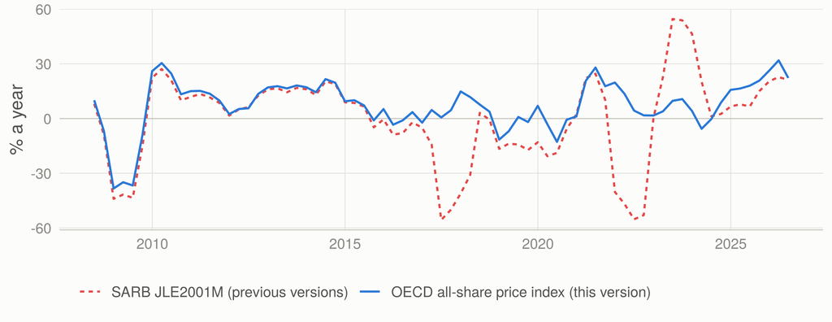

Annual growth of South African equity prices (log, quarterly averages): the SARB’s all-share series, which the models used up to the previous version, and the OECD all-share price index (FRED SPASTT01ZAM661N) used now.

**Table view**

| Quarter | SARB series | OECD index | Gap |
| --- | --- | --- | --- |
| 2008Q2 | 8.0 | 10.0 | -2.0 |
| 2008Q3 | -9.0 | -6.9 | -2.1 |
| 2008Q4 | -44.0 | -38.4 | -5.7 |
| 2009Q1 | -41.7 | -34.9 | -6.8 |
| 2009Q2 | -43.5 | -36.7 | -6.8 |
| 2009Q3 | -15.1 | -9.0 | -6.1 |
| 2009Q4 | 22.4 | 26.0 | -3.6 |
| 2010Q1 | 27.2 | 30.4 | -3.3 |
| 2010Q2 | 21.0 | 24.7 | -3.7 |
| 2010Q3 | 10.0 | 13.3 | -3.3 |
| 2010Q4 | 11.9 | 15.0 | -3.2 |
| 2011Q1 | 13.5 | 15.2 | -1.7 |
| 2011Q2 | 11.6 | 13.6 | -2.0 |
| 2011Q3 | 8.5 | 9.8 | -1.3 |
| 2011Q4 | 1.6 | 2.5 | -0.8 |
| 2012Q1 | 5.0 | 5.2 | -0.2 |
| 2012Q2 | 6.3 | 5.6 | 0.6 |
| 2012Q3 | 12.5 | 13.5 | -0.9 |
| 2012Q4 | 16.0 | 17.1 | -1.1 |
| 2013Q1 | 16.6 | 17.8 | -1.1 |
| 2013Q2 | 14.4 | 16.5 | -2.1 |
| 2013Q3 | 16.8 | 18.2 | -1.3 |
| 2013Q4 | 16.0 | 17.1 | -1.1 |
| 2014Q1 | 12.9 | 14.4 | -1.6 |
| 2014Q2 | 20.4 | 21.6 | -1.2 |
| 2014Q3 | 19.0 | 19.6 | -0.7 |
| 2014Q4 | 8.9 | 9.5 | -0.6 |
| 2015Q1 | 8.6 | 10.0 | -1.5 |
| 2015Q2 | 6.6 | 7.2 | -0.6 |
| 2015Q3 | -4.8 | -1.0 | -3.8 |
| 2015Q4 | -0.5 | 5.2 | -5.7 |
| 2016Q1 | -8.8 | -3.4 | -5.4 |
| 2016Q2 | -8.0 | -1.0 | -7.0 |
| 2016Q3 | -2.1 | 3.5 | -5.6 |
| 2016Q4 | -5.1 | -2.2 | -2.8 |
| 2017Q1 | -14.2 | 4.7 | -18.9 |
| 2017Q2 | -55.6 | 0.6 | -56.2 |
| 2017Q3 | -50.0 | 4.6 | -54.6 |
| 2017Q4 | -41.1 | 14.9 | -56.0 |
| 2018Q1 | -30.9 | 11.8 | -42.7 |
| 2018Q2 | 3.1 | 7.7 | -4.6 |
| 2018Q3 | -0.6 | 3.8 | -4.4 |
| 2018Q4 | -16.6 | -11.5 | -5.1 |
| 2019Q1 | -13.8 | -7.0 | -6.8 |
| 2019Q2 | -14.2 | 0.9 | -15.1 |
| 2019Q3 | -17.3 | -1.9 | -15.4 |
| 2019Q4 | -13.0 | 7.0 | -20.0 |
| 2020Q1 | -20.6 | -3.1 | -17.5 |
| 2020Q2 | -18.8 | -12.8 | -6.1 |
| 2020Q3 | -5.7 | -0.6 | -5.1 |
| 2020Q4 | 2.3 | 1.2 | 1.1 |
| 2021Q1 | 22.2 | 20.8 | 1.4 |
| 2021Q2 | 24.6 | 28.0 | -3.4 |
| 2021Q3 | 10.2 | 17.7 | -7.5 |
| 2021Q4 | -40.3 | 19.7 | -60.0 |
| 2022Q1 | -46.8 | 13.6 | -60.4 |
| 2022Q2 | -55.2 | 4.4 | -59.6 |
| 2022Q3 | -52.9 | 1.7 | -54.7 |
| 2022Q4 | 0.4 | 1.7 | -1.3 |
| 2023Q1 | 22.9 | 4.0 | 18.9 |
| 2023Q2 | 54.6 | 9.7 | 44.9 |
| 2023Q3 | 53.9 | 10.7 | 43.2 |
| 2023Q4 | 46.5 | 4.2 | 42.3 |
| 2024Q1 | 20.2 | -5.6 | 25.9 |
| 2024Q2 | 1.3 | -0.3 | 1.7 |
| 2024Q3 | 2.5 | 8.7 | -6.2 |
| 2024Q4 | 6.6 | 15.7 | -9.1 |
| 2025Q1 | 7.8 | 16.5 | -8.7 |
| 2025Q2 | 6.6 | 18.0 | -11.4 |
| 2025Q3 | 15.1 | 20.8 | -5.7 |
| 2025Q4 | 20.4 | 26.3 | -5.8 |
| 2026Q1 | 22.7 | 31.9 | -9.2 |
| 2026Q2 | 21.2 | 22.3 | -1.1 |

From this version equity growth comes from the OECD index, with the SARB series only where the OECD’s is missing (growth is never taken across a switch between the two), and the panel build stops if annual equity growth exceeds 45% again. Every industry model was re-estimated on the clean series. Every number in this report was recomputed; what the fix does to NGFB’s results is in What changed.

## 13.3 How rate-sensitive is NGFB’s net interest income?

Banks publish the effect of a parallel rate move on their next twelve months’ net interest income. The engine’s equivalent moves every rate by 100 bps on the static balance sheet: deposit costs and loan spreads follow their Stage 1 pass-through, volumes, credit and fees stay as in the baseline.

First-year NII sensitivity to a parallel 100 bps move. Published: a large South African bank’s 2025 results, ‘NII sensitivity for 1% change in interest rates: R1.5bn’ on NII of R42.9bn, with endowment hedging of R14bn implemented to date.

| Entity | NII, first year | +100 bps | -100 bps |
| --- | --- | --- | --- |
| NGFB with its hedge | R41.0 bn | -R0.5 bn (-1.2%) | +R0.5 bn (+1.2%) |
| NGFB without a hedge | R39.9 bn | +R2.6 bn (+6.4%) | -R2.6 bn (-6.4%) |
| Sector (unhedged) | R272.3 bn | +R17.1 bn (+6.3%) | -R16.5 bn (-6.1%) |
| Published: a large South African bank (2025) | R42.9 bn | ±R1.5 bn (3.5%) | — |

Unhedged, NGFB is asset-sensitive like the sector and like the published bank (+6.4% of NII for +100 bps, against +6.3% for the sector and 3.5% published). With its hedge it is **liability-sensitive** (-1.2%), and that is not what large South African banks report: the published bank hedges R14bn of its endowment, NGFB hedges R346 bn. The canonical hedge ratio, 49.6% of non-maturity deposits, was sized in the earlier posts for a deposit beta of 0.49; the refined Stage 1 models make NGFB’s deposits reprice faster, and with them the ratio at which a 100 bps move leaves first-year NII unchanged falls to 37%. NGFB is over-hedged by that yardstick, a finding about the canonical bank that the hedge-ratio lever prices.

## 13.4 Does the engine reproduce the sector’s margin?

Sector NII: BA120’s last four quarters against the engine’s first projected year, unhedged and with a structural hedge of 49.6% of non-maturity deposits at the actual-swap fixed rate (the engine’s balance sheet is larger, so its NII is also shown scaled to BA120’s average assets).

| Run | NII, first year, R bn | On BA120’s balance sheet, R bn | NIM |
| --- | --- | --- | --- |
| BA120, last four quarters | 249.0 | 249.0 | — |
| Engine, sector unhedged | 272.3 | 230.5 | 3.04% |
| Engine, sector with a hedge at real swap rates | 279.5 | 236.6 | 3.12% |

On BA120’s balance-sheet size, the engine’s unhedged sector earns 7% less net interest income than BA120 reports. Two things explain most of it. The policy rate averages 0.52 pp less in the engine’s first year than over BA120’s last four quarters, worth about 3.2% of NII at the unhedged sector’s sensitivity. And real banks hedge: their structural hedges, struck when rates were higher, carried positively as the SARB cut through 2024–2025, and a sector-wide hedge at NGFB’s ratio and actual swap rates closes 33% of the gap. The engine’s sector therefore slightly understates reported margins, which is conservative for the industry view and does not touch NGFB, whose hedge is modelled.

## 13.5 Funding spreads: is there a macro channel?

The engine prices wholesale funding at the 3-month floating benchmark plus a calibrated spread, and NCDs through a Stage 1 model of their cost. A recession could widen bank funding spreads beyond what the benchmark captures – and from 2027, with the benchmark tied to an overnight rate, any such widening shows up only in funding spreads. The test regresses the sector’s NCD cost less JIBAR on its own lag, the repo change (the repricing lag) and, one at a time, each candidate macro driver:

NCD cost less 3-month JIBAR, 2008Q2-2025Q2 (68 quarters).

| Driver | Coefficient | HAC t | Repo change: coefficient (t) | BIC |
| --- | --- | --- | --- | --- |
| Repricing lag only | — | — | -0.71 (-3.1) | 149.2 |
| Real GDP growth | 0.004 | 0.3 | -0.72 (-2.7) | 153.4 |
| Change in unemployment (4 quarters) | 0.031 | 1.1 | -0.70 (-3.1) | 146.5 |
| Contraction kink (GDP growth below zero) | -0.010 | -0.5 | -0.69 (-2.5) | 153.4 |
| Curve slope | -0.042 | -0.7 | -0.65 (-2.7) | 152.5 |
| Change in the 10-year yield | -0.188 | -0.8 | -0.69 (-3.2) | 152.4 |

None of the macro drivers is significant. What moves the measured spread is the repricing lag: when the SARB cuts, the average cost of the NCD book lags JIBAR down, and the spread widens for a few quarters (as in 2009 and 2020). The industry models already reproduce that repricing lag. The genuine spread shock in the sample, the global funding squeeze of late 2008, came before South Africa’s GDP turned and is not explained by domestic macro variables. A funding shock is therefore a stress overlay, not a scenario relationship: 100 bps on wholesale funding and the NCD share of term deposits costs NGFB 151 bps of ROE in the baseline (R5.8 bn over three years).

## 13.6 JIBAR’s end: the switch to ZARONIA

JIBAR has not ceased yet, but almost all of the projection lies beyond it. The SARB’s Market Practitioners Group set the timetable on 3 December 2025:

The JIBAR transition. Loans follow the Market Practitioners Group’s conventions: ZARONIA compounded in arrears with a five-business-day lookback, plus the CAS and the contractual margin.

[output not shown]

10 of the twelve projected quarters (2027Q1 to 2029Q2) therefore fall after the last fixing, and from this version the engine prices them that way. Its 3-month floating benchmark – the reference for corporate term loans, interbank lending, floating-rate securities, wholesale funding and the hedge’s floating leg – is JIBAR to 2026Q4 and compounded ZARONIA plus 16.19 bp from 2027Q1. ZARONIA follows the policy rate at the median spread of the last eight quarters of daily data (-0.14 pp), and a quarter’s average of daily ZARONIA is its compounded rate up to convexity well under a basis point. At a given policy rate the successor sits 0.7 bps above JIBAR (+0.02 pp over the policy rate in the panel), and against a run that keeps JIBAR to 2029, NGFB’s ROE moves by +1.3 bps in the baseline (+R64 m of NII over three years) and by no more than 1.4 bps in any scenario. That is no accident: the CAS is the long-run median of the basis it replaces. Over the 36 months of daily data, 3-month JIBAR traded 0.17 pp above ZARONIA on average, between 0.06 and 0.27 pp, and the CAS sits at the median:

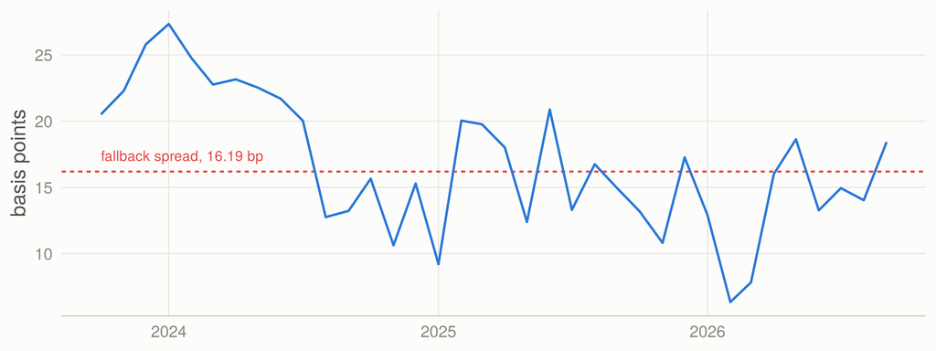

3-month JIBAR less ZARONIA, monthly averages of daily fixings, against the fixed fallback spread of 16.19 bp. Source: rbond.co.za (CC BY 4.0), SARB Market Practitioners Group.

**Table view**

| Month | JIBAR less ZARONIA (bp) |
| --- | --- |
| Oct 2023 | 20.5 |
| Nov 2023 | 22.3 |
| Dec 2023 | 25.8 |
| Jan 2024 | 27.3 |
| Feb 2024 | 24.7 |
| Mar 2024 | 22.8 |
| Apr 2024 | 23.2 |
| May 2024 | 22.5 |
| Jun 2024 | 21.7 |
| Jul 2024 | 20.0 |
| Aug 2024 | 12.8 |
| Sep 2024 | 13.2 |
| Oct 2024 | 15.7 |
| Nov 2024 | 10.6 |
| Dec 2024 | 15.3 |
| Jan 2025 | 9.2 |
| Feb 2025 | 20.0 |
| Mar 2025 | 19.8 |
| Apr 2025 | 18.0 |
| May 2025 | 12.4 |
| Jun 2025 | 20.9 |
| Jul 2025 | 13.3 |
| Aug 2025 | 16.7 |
| Sep 2025 | 14.9 |
| Oct 2025 | 13.2 |
| Nov 2025 | 10.8 |
| Dec 2025 | 17.3 |
| Jan 2026 | 12.9 |
| Feb 2026 | 6.3 |
| Mar 2026 | 7.8 |
| Apr 2026 | 16.0 |
| May 2026 | 18.6 |
| Jun 2026 | 13.3 |
| Jul 2026 | 14.9 |
| Aug 2026 | 14.0 |
| Sep 2026 | 18.4 |

What the transition changes is risk, not level:

- **The basis stops floating.** A 3-month term rate carries the market’s expected policy move over the coming quarter and the banks’ term and credit premium; over 2008–2026 3-month JIBAR’s quarterly spread over the policy rate ranged from -1.00 to 0.67 pp (median 0.09). ZARONIA compounded in arrears carries neither, and the CAS is fixed. Floating-rate assets will no longer reprice ahead of an expected hike, nor pick up a widening bank-credit premium in a stress; nor will floating funding or the hedge’s floating leg pay it. NGFB pays the benchmark on net – floating assets of R313 bn against floating funding of R85 bn and a hedge notional of R346 bn – so each 10 bp of basis widening cost it about R118 m of annual NII under JIBAR, and costs nothing from 2027. Funding stress does not disappear: it moves into the spreads at which NCDs and notes are issued over the overnight rate.
- **The spread is at risk on the asset side.** Converted and fallback contracts keep the 16.19 bp, but loans that are re-papered onto ZARONIA are priced in negotiation, and a borrower quoted “ZARONIA plus the old margin” has gained the CAS. If NGFB lost it on every floating-rate asset from 2027Q1, ROE would fall by 32 bps in the baseline (R1.6 bn of NII over three years), and by 20 bps if its floating funding were re-priced the same way. Pricing new ZARONIA business at all-in parity – ZARONIA plus the CAS plus the margin – is worth that much.
- **The hedge is unaffected.** The clearing houses keep each swap’s fixed rate and pay ZARONIA plus 16.19 bp on the floating leg, so the book’s carry is unchanged. A new receive-fixed hedge is a ZARONIA swap, struck about 16.19 bp below the JIBAR swap rate while the basis trades at the CAS, and earns the same carry against ZARONIA as the engine’s JIBAR-equivalent quote against ZARONIA plus 16.19 bp.

The spread at risk: 16.19 bp off the rate of every floating-rate asset (corporate term loans, interbank lending, floating-rate securities) from 2027Q1, and off floating funding (wholesale funding) as well. An upper bound: converted and fallback contracts keep the spread.

| Scenario | Floating assets lose the CAS: ROE | NII, 3 years | Assets and floating funding lose it: ROE | NII, 3 years |
| --- | --- | --- | --- | --- |
| Baseline | -32 bps | -R1.6 bn | -20 bps | -R1.0 bn |
| Upside | -31 bps | -R1.6 bn | -18 bps | -R0.9 bn |
| Downside | -33 bps | -R1.6 bn | -22 bps | -R1.0 bn |

# 14 More levers: what else ties in with the macro view

The optimiser in Positioning moves the balance sheet’s mix. A bank’s ALCO has more levers than that, and most of them are rate, spread, liquidity and capital decisions that a macro view should drive directly. This chapter runs each through the full engine in every scenario (and the downside’s variant with cuts), against NGFB’s plan, with the swap curve corrected in Are the numbers right?, in the order an ALCO sets them: the **structural hedge** that converts the deposit franchise’s rate sensitivity (how much of it, and at what tenor maturing swaps are reinvested); the **liquidity book** (whether the buffer sits in bills, ten-year bonds or asset-swapped bonds, and how large it is); **capital** (payout and distribution); and deposit pricing. The macro paths are known in each scenario; the question is which settings pay in which world, and which pay across them, using the same judgemental probabilities as the robust positioning (baseline 50%, upside 20%, downside 30%). The strategy lab then replays every lever across sixty historical macro paths, and the risk-budgeted optimiser sets them together.

## 14.1 A strategy map: which macro signal drives which lever

```
flowchart LR
  subgraph SIG["Macro signal, last quarter"]
    direction TB
    M1["Policy rate against<br/>its 6.25% neutral"]
    M2["Government curve's slope:<br/>10-year less the benchmark"]
    M3["5-year bond–swap spread:<br/>the fiscal premium"]
    M4["Stress: GDP contracting,<br/>or the rand down 15% y/y"]
    M5["GDP growth and<br/>the CET1 ratio"]
    M6["Unemployment<br/>and GDP growth"]
  end
  subgraph LEV["Lever (rule)"]
    direction TB
    L1["Hedge ratio (R1)"]
    L2["Reinvestment tenor (R2)"]
    L3["10-year bonds in HQLA (R3)"]
    L4["Asset-swapped bonds (R6)"]
    L5["Size of the buffer (R7)"]
    L6["Payout (R4)"]
    L7["Unsecured growth (R5)"]
  end
  ENG["<b>Engine</b>, every quarter<br/>NII and profit<br/>OCI reserve and CET1<br/>LCR, NSFR (HQLA at market)<br/>EVE for ±200 bps"]
  M1 --> L1
  M1 --> L2
  M2 --> L3
  M3 --> L4
  M4 --> L5
  M5 --> L6
  M6 --> L7
  LEV --> ENG
  ENG --> OPT["<b>Risk-budgeted optimiser</b><br/>the best average ROE<br/>within limits on the ROE tail,<br/>CET1, LCR, NSFR and EVE"]
```

The strategy map. Each rule reads the previous quarter’s data with parameters set in advance as round numbers (Strategy lab). Payout and unsecured growth also have static settings; every lever’s static settings are in the tables below.

| Lever | Decision | Premium it earns | Macro signal (rule) | Risk it takes | Where the risk shows |
| --- | --- | --- | --- | --- | --- |
| Hedge ratio | share of non-maturity deposits received fixed | fixed over floating: a view on the policy path | policy rate against neutral (R1) | rates rise | NII, EVE |
| Reinvestment tenor | tenor of the swaps that replace maturing tranches | the swap curve’s term premium | policy rate against neutral (R2) | today’s rates locked in for longer | EVE |
| 10-year bonds in HQLA | share of the buffer’s bills in 10-year government bonds | the term premium and the fiscal premium | the curve’s slope (R3) | the 10-year yield rises | OCI and CET1, HQLA at market, EVE |
| Asset-swapped bonds | share in 5-year government bonds swapped to floating | the fiscal premium alone | the 5-year bond–swap spread (R6) | the spread widens | OCI and CET1, HQLA at market |
| Size of the buffer | Treasury bills released to repay wholesale funding | wholesale funding’s cost over the bills’ yield | stress: GDP or the rand (R7) | less liquidity going into a stress | LCR, NSFR |
| Payout | share of profit paid out | equity returned: a smaller ROE denominator | growth and CET1 (R4) | a thinner cushion into a downturn | CET1 |
| Unsecured growth | card and personal-loan growth | volume and margin | the labour market (R5) | credit losses | profit, CET1 |

Read down, the map is the order of an ALCO’s decisions: first how much of the deposit franchise’s rate sensitivity to convert to fixed, then how to hold the liquidity that regulation requires and how much of it to hold, then how much capital to keep. Read across, it says why each lever has its own macro signal: each earns a different premium, and a premium is worth collecting when it is large. A receive-fixed hedge pays when the policy rate falls below the swap rate struck, so its signal is the policy rate against neutral; a ten-year bond earns the term premium, largest when the curve is steep; an asset-swapped bond earns only the fiscal premium, largest when sovereign stress has widened the bond–swap spread; surplus liquidity is insurance, worth most going into a stress; retained capital is worth most going into a downturn. And it says why the levers have to be chosen under limits: every setting that earns more takes a risk the three-year ROE does not price, and the risks land in different places – the hedge and the bond book in the economic value of equity, the bond books in OCI and CET1 and in the market value of the buffer, a smaller buffer in the LCR and NSFR, a higher payout in CET1. The risk-budgeted optimiser puts one limit on each.

Change in NGFB’s three-year average ROE against the plan, by lever and scenario. Probability-weighted: baseline, upside and downside at the judgemental weights (the variant carries no weight). CET1 trough: the lowest quarter across the three weighted scenarios.

| Lever | Setting | Baseline | Upside | Downside | Downside with cuts | Probability-weighted | Net income, weighted, 3 years | CET1 trough |
| --- | --- | --- | --- | --- | --- | --- | --- | --- |
| Hedge ratio | 80% | +77 bps | +153 bps | -35 bps | +186 bps | +59 bps | +R2.3 bn | 12.3% |
| Hedge ratio | 65% | +39 bps | +78 bps | -18 bps | +95 bps | +30 bps | +R1.2 bn | 12.4% |
| Hedge ratio | 35% | -37 bps | -74 bps | +17 bps | -91 bps | -28 bps | -R1.1 bn | 12.5% |
| Hedge ratio | 25% | -63 bps | -126 bps | +28 bps | -153 bps | -48 bps | -R1.9 bn | 12.4% |
| Hedge ratio | 0% | -127 bps | -256 bps | +57 bps | -313 bps | -98 bps | -R3.8 bn | 12.2% |
| Reinvestment tenor | 10 years | +69 bps | +67 bps | +72 bps | +70 bps | +69 bps | +R2.7 bn | 12.5% |
| Reinvestment tenor | 7 years | +28 bps | +27 bps | +29 bps | +28 bps | +28 bps | +R1.1 bn | 12.5% |
| Reinvestment tenor | 5 years | +0 bps | +0 bps | +0 bps | +0 bps | +0 bps | +R0.0 bn | 12.4% |
| Reinvestment tenor | 3 years | -21 bps | -20 bps | -22 bps | -21 bps | -21 bps | -R0.8 bn | 12.4% |
| Equity hedge | Half of equity, 5 years | +19 bps | +38 bps | -9 bps | +46 bps | +15 bps | +R0.6 bn | 12.4% |
| HQLA duration | A quarter of HQLA in 10-year bonds | +104 bps | +139 bps | +53 bps | +157 bps | +96 bps | +R3.7 bn | 12.5% |
| Asset swap | A quarter of HQLA in asset-swapped 5-year bonds | +38 bps | +37 bps | +39 bps | +38 bps | +38 bps | +R1.5 bn | 12.5% |
| Liquidity buffer | LCR 160% at the jump-off | +71 bps | +69 bps | +74 bps | +71 bps | +71 bps | +R2.7 bn | 12.5% |
| Liquidity buffer | LCR 170% at the jump-off | +49 bps | +48 bps | +51 bps | +49 bps | +50 bps | +R1.9 bn | 12.5% |
| Liquidity buffer | LCR 180% at the jump-off | +26 bps | +26 bps | +27 bps | +26 bps | +26 bps | +R1.0 bn | 12.5% |
| Payout | 70% of earnings | +32 bps | +46 bps | +15 bps | +27 bps | +30 bps | -R0.7 bn | 11.6% |
| Payout | 50% of earnings | +0 bps | +0 bps | +0 bps | +0 bps | +0 bps | +R0.0 bn | 12.4% |
| Payout | 30% of earnings | -30 bps | -42 bps | -14 bps | -25 bps | -28 bps | +R0.7 bn | 12.8% |
| Distribution | Capital above a 12.5% CET1 returned at the jump-off | +33 bps | +43 bps | +17 bps | +31 bps | +30 bps | -R1.0 bn | 11.9% |
| Deposit pricing | 10% less of rises, 10% more of cuts | +20 bps | +52 bps | +50 bps | +68 bps | +36 bps | +R1.4 bn | 12.5% |
| Combined | Ten-year reinvestment, HQLA duration and the distribution | +213 bps | +256 bps | +147 bps | +265 bps | +202 bps | +R5.4 bn | 12.0% |

## 14.2 The hedge ratio is a rate view

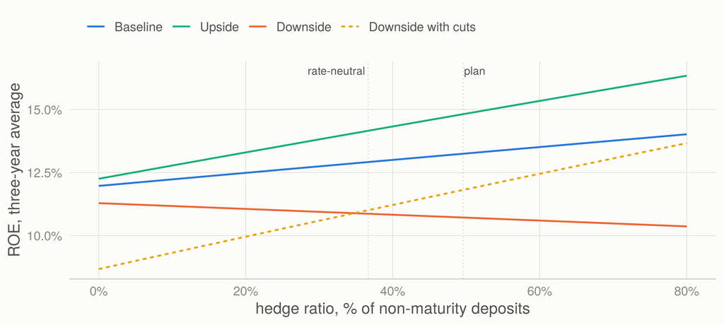

NGFB’s three-year average ROE against the structural hedge ratio, by scenario. Changes are made at the jump-off with 5-year swaps (receive fixed to add, pay fixed to offset); the existing book’s locked-in carry stays either way. Dotted lines: the plan’s ratio and the ratio at which first-year NII does not move with a parallel rate shift.

**Table view**

| Hedge ratio | Baseline | Upside | Downside | Downside with cuts | Probability-weighted |
| --- | --- | --- | --- | --- | --- |
| 0% | 11.97% | 12.25% | 11.29% | 8.67% | 11.82% |
| 5% | 12.10% | 12.52% | 11.23% | 9.00% | 11.92% |
| 10% | 12.23% | 12.78% | 11.17% | 9.32% | 12.02% |
| 15% | 12.36% | 13.04% | 11.11% | 9.64% | 12.12% |
| 20% | 12.49% | 13.30% | 11.06% | 9.96% | 12.22% |
| 25% | 12.62% | 13.56% | 11.00% | 10.27% | 12.32% |
| 30% | 12.75% | 13.81% | 10.94% | 10.59% | 12.42% |
| 35% | 12.87% | 14.07% | 10.88% | 10.90% | 12.52% |
| 40% | 13.00% | 14.33% | 10.83% | 11.22% | 12.61% |
| 45% | 13.13% | 14.58% | 10.77% | 11.53% | 12.71% |
| 50% | 13.26% | 14.84% | 10.71% | 11.84% | 12.81% |
| 55% | 13.38% | 15.09% | 10.65% | 12.15% | 12.91% |
| 60% | 13.51% | 15.34% | 10.60% | 12.45% | 13.00% |
| 65% | 13.64% | 15.59% | 10.54% | 12.76% | 13.10% |
| 70% | 13.76% | 15.84% | 10.48% | 13.06% | 13.19% |
| 75% | 13.89% | 16.09% | 10.42% | 13.36% | 13.29% |
| 80% | 14.02% | 16.34% | 10.36% | 13.66% | 13.39% |

A receive-fixed swap earns its fixed rate and pays the floating benchmark (JIBAR, and from 2027 compounded ZARONIA plus 16.19 bp), so more hedge pays in every scenario in which the benchmark falls below the swap rate it was struck at, and costs in every scenario in which it rises above it. ROE is therefore linear in the hedge ratio, and the best ratio is a corner: as much hedge as policy allows if the view is the baseline (+77 bps at 80% of non-maturity deposits), the upside (+153 bps) or a downturn with cuts (+186 bps), and none if the view is the stagflationary downside (+57 bps at 0%). At the judgemental weights more hedge wins (+59 bps at 80%), because the 5-year swap at the jump-off (7.49%) priced the SARB’s 2026 increases but not the baseline’s point of cuts by 2028. That is a bet on the bank’s rate view against the market’s, and it should be sized as one, not as a structural decision: the ratio that leaves first-year NII unchanged by a parallel move is 37%, and the ROE range across the three weighted scenarios is narrowest with no hedge at all (1.0 pp against 4.1 pp at 50%).

## 14.3 Reinvestment tenor: the term premium

Change in ROE when maturing hedge tranches are reinvested at each tenor instead of five years, and the receive-fixed book’s PV01 at the end of the horizon (the value change for a 1 bp parallel move).

| Tenor | Baseline | Upside | Downside | Downside with cuts | Book PV01 after three years | PV01 against the plan |
| --- | --- | --- | --- | --- | --- | --- |
| 3 years | -21 bps | -20 bps | -22 bps | -21 bps | R46 m per bp | -43% |
| 5 years | +0 bps | +0 bps | +0 bps | +0 bps | R80 m per bp | +0% |
| 7 years | +28 bps | +27 bps | +29 bps | +28 bps | R109 m per bp | +37% |
| 10 years | +69 bps | +67 bps | +72 bps | +70 bps | R145 m per bp | +83% |

One twentieth of the hedge matures every quarter, so within three years three-fifths of the book is reinvested. At ten years instead of five each reinvested tranche earns the swap curve’s term premium, about 1.0 pp a year more over 2023–2026, which is worth +69 bps of ROE in every scenario alike. It is not free: the book’s PV01 rises by 83%, so the economic value of equity becomes more sensitive to rates and the IRRBB limits bind sooner, and the bank locks today’s rates in for longer. Seven years is the halfway house (+28 bps, +37% PV01).

## 14.4 HQLA duration: the term and fiscal premia

A quarter of the earning HQLA (R73 bn) moved from Treasury bills into 10-year government bonds at the jump-off. The carry runs through NII; at fair value through OCI the price change along each scenario’s 10-year yield runs through CET1 (modified duration of the bond’s remaining life, after tax). Held at amortised cost there is no OCI effect, but the economic exposure is the same.

| Scenario | ROE | Net income, 3 years | 10-year yield, change over the horizon | CET1 through OCI: worst quarter | CET1 through OCI: end |
| --- | --- | --- | --- | --- | --- |
| Baseline | +104 bps | +R4.1 bn | +0.27 pp | -12 bps | -12 bps |
| Upside | +139 bps | +R5.5 bn | +0.01 pp | +9 bps | +9 bps |
| Downside | +53 bps | +R2.0 bn | +0.27 pp | -111 bps | -49 bps |
| Downside with cuts | +157 bps | +R6.0 bn | +0.15 pp | -34 bps | -17 bps |

## 14.5 Asset-swapped bonds: the fiscal premium without the duration

**What it is.** A ten-year bond held for liquidity earns two premia over bills: the *term premium*, the reward for interest-rate risk, and the *fiscal premium* South African government bonds pay over the swap curve, the reward for sovereign and supply risk. An asset swap separates them. NGFB buys a 5-year government bond for the buffer and, against it, pays fixed on a 5-year swap of the same notional: the swap’s fixed leg passes the bond’s coupon on, its floating leg pays the benchmark back. What is left is a floating-rate asset that yields the benchmark plus the bond’s yield over the swap rate – the *bond–swap spread*, $bs = y^{\text{bond}}_{5} - s_{5}$. Against the Treasury bills it replaces, each rand earns

$$\text{carry} = \underbrace{y^{\text{bond}}_{5} - s_{5}}_{\text{bond–swap spread, locked at purchase}} + \underbrace{\left(f_t - y^{\text{bill}}_t\right)}_{\text{bills' discount to the benchmark}} ,$$

with $f_t$ the floating benchmark (3-month JIBAR, then compounded ZARONIA plus 16.19 bp). In the jump-off quarter the 5-year bond yielded 8.15% against a 5-year swap of 7.49%, a spread of 0.67 pp; bills yield about 0.15 pp less than the benchmark. So the pickup is about 0.8 pp a year, and none of it depends on where the policy rate goes.

**What it does to the risk measures.**

- *Economic value of equity.* None: the swap carries the bond’s interest-rate sensitivity away, so the position adds nothing to the EVE budget – which is why it matters when the levers are chosen together.
- *Spread.* What is left is credit-spread risk in the banking book: if the fiscal premium widens, the bond falls against the swap. With the bond at fair value through OCI and the swap designated as a fair-value hedge of its rate risk, the rate parts offset in profit and loss and the spread part sits in the OCI reserve, and so in CET1; a sale recycles it to profit or loss. The book’s spread PV01 is R29.5 m per basis point: a 100 bps widening at the jump-off – more than 3 times the largest widening since the swap data begin in late 2023 – would cost 35 bps of CET1 after tax.
- *Liquidity.* A government bond is Level 1 like a bill, so buying it does not move the LCR; but HQLA count at market value, so a widening lowers the buffer. A rate-driven fall in the bond’s price does not, because the cleared swap pays it back daily as cash variation margin.

**How the spread moves with the macro picture.** A scenario carries the 10-year yield and the benchmark but no swap curve that prices the policy path (its swap rates are the benchmark plus constant spreads), so the spread is modelled. Both curves price the expected policy path, so a policy-driven move should leave their difference alone; the spread should take a share of the rest of the long bond’s move – the fiscal premium and global yields:

$$\Delta bs_t = \kappa \left[\Delta y^{\text{gov}}_{10,t} - \beta\, \Delta f_t\right].$$

The 10-year yield moves by $\beta$ = 0.15 for each point of the benchmark (three-year changes since 2005, HAC *t* = 2.8): the long end barely follows the policy rate. And the 5-year bond–swap spread takes $\kappa$ = 0.26 of the 10-year’s remaining move (monthly levels, October 2023 to September 2026, *t* = 5.3, $R^2$ = 0.76): about a quarter of a fiscal or global move in the long bond shows up in the spread, and the rest moves the swap curve with it. Month-on-month changes give a smaller 0.11, short-run noise that does not accumulate; for a book held for years the level relationship is the relevant one, and the larger number is the more prudent for risk. The scenarios’ own swap curve would have loaded every change in the government curve’s slope onto the spread – a five-point policy cut would have widened it by up to five points, which is not what spreads do. The model misses the most recent months, when swap rates rose faster than bond yields as the market began to price the SARB’s hikes, and the spread compressed further than the long bond’s level implies.

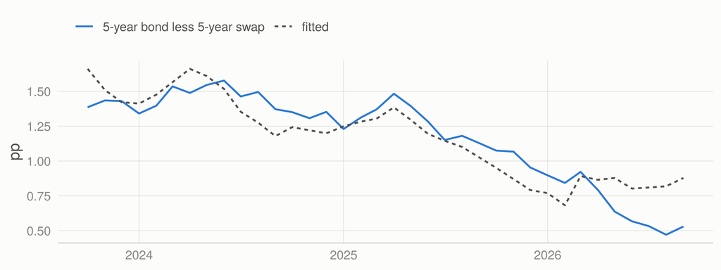

The 5-year bond–swap spread, monthly, against the spread model’s fit: a share κ of the 10-year yield net of β times the benchmark. The spread compressed from about 1.4 pp in late 2023 to under 0.7 pp as the long bond rallied.

**Table view**

| Month | Bond-swap spread (pp) | Fitted (pp) | 10-year yield (%) | 3-month JIBAR (%) |
| --- | --- | --- | --- | --- |
| 2023-10 | 1.39 | 1.66 | 12.04 | 8.35 |
| 2023-11 | 1.43 | 1.51 | 11.47 | 8.36 |
| 2023-12 | 1.43 | 1.42 | 11.14 | 8.39 |
| 2024-01 | 1.34 | 1.41 | 11.11 | 8.40 |
| 2024-02 | 1.40 | 1.48 | 11.34 | 8.37 |
| 2024-03 | 1.54 | 1.57 | 11.68 | 8.35 |
| 2024-04 | 1.49 | 1.66 | 12.04 | 8.35 |
| 2024-05 | 1.55 | 1.61 | 11.84 | 8.35 |
| 2024-06 | 1.58 | 1.52 | 11.50 | 8.35 |
| 2024-07 | 1.46 | 1.35 | 10.87 | 8.32 |
| 2024-08 | 1.50 | 1.28 | 10.57 | 8.25 |
| 2024-09 | 1.37 | 1.18 | 10.19 | 8.17 |
| 2024-10 | 1.35 | 1.24 | 10.41 | 8.03 |
| 2024-11 | 1.31 | 1.22 | 10.31 | 7.91 |
| 2024-12 | 1.35 | 1.20 | 10.21 | 7.78 |
| 2025-01 | 1.23 | 1.25 | 10.39 | 7.70 |
| 2025-02 | 1.31 | 1.28 | 10.49 | 7.56 |
| 2025-03 | 1.37 | 1.30 | 10.58 | 7.56 |
| 2025-04 | 1.48 | 1.38 | 10.88 | 7.54 |
| 2025-05 | 1.39 | 1.30 | 10.53 | 7.47 |
| 2025-06 | 1.28 | 1.19 | 10.13 | 7.32 |
| 2025-07 | 1.15 | 1.14 | 9.93 | 7.24 |
| 2025-08 | 1.18 | 1.10 | 9.73 | 7.02 |
| 2025-09 | 1.13 | 1.03 | 9.44 | 7.01 |
| 2025-10 | 1.07 | 0.95 | 9.16 | 6.99 |
| 2025-11 | 1.07 | 0.87 | 8.84 | 6.88 |
| 2025-12 | 0.95 | 0.79 | 8.53 | 6.77 |
| 2026-01 | 0.90 | 0.77 | 8.44 | 6.73 |
| 2026-02 | 0.84 | 0.68 | 8.10 | 6.67 |
| 2026-03 | 0.92 | 0.89 | 8.89 | 6.70 |
| 2026-04 | 0.79 | 0.87 | 8.80 | 6.77 |
| 2026-05 | 0.64 | 0.88 | 8.86 | 6.80 |
| 2026-06 | 0.57 | 0.80 | 8.60 | 6.99 |
| 2026-07 | 0.53 | 0.81 | 8.63 | 7.01 |
| 2026-08 | 0.47 | 0.82 | 8.66 | 7.00 |
| 2026-09 | 0.53 | 0.88 | 8.90 | 7.08 |

A quarter of the earning HQLA (R73 bn) moved from Treasury bills into 5-year government bonds at the jump-off, each with a pay-fixed 5-year swap against it, the spread locked at 0.67 pp. The carry runs through NII; the spread’s mark-to-market through the OCI reserve and CET1. Against the plan.

| Scenario | ROE | NII, 3 years | Net income, 3 years | Spread at its widest | Spread at the end | CET1 through OCI: worst quarter |
| --- | --- | --- | --- | --- | --- | --- |
| Baseline | +38 bps | +R1.9 bn | +R1.5 bn | 0.78 pp | 0.78 pp | -2 bps |
| Upside | +37 bps | +R1.9 bn | +R1.4 bn | 0.66 pp | 0.66 pp | +0 bps |
| Downside | +39 bps | +R1.9 bn | +R1.5 bn | 1.21 pp | 1.01 pp | -16 bps |
| Downside with cuts | +38 bps | +R1.8 bn | +R1.4 bn | 0.89 pp | 0.85 pp | -6 bps |

**What it earns.** A quarter of the buffer (R73 bn) in asset-swapped bonds adds 37 bps to 39 bps of ROE in every scenario, about R1.5 bn of net income over three years, because its income does not depend on the policy path. The stagflationary downside’s sovereign stress widens the spread to 1.21 pp at its worst, which costs 16 bps of CET1 through OCI – about a seventh of the ten-year book’s 111 bps, for 40% of its return. The ten-year book earns more because it also collects the term premium, and the term premium is paid for interest-rate risk the asset swap does not take.

**The macro link.** The lever is a view on the fiscal premium, not on the policy rate. Its rule (R6, Strategy lab) holds none below a 0.5 pp spread, a quarter of earning HQLA at 1 pp and half at 1.5 pp or more: it buys the premium after sovereign stress has widened it and lets it go as it compresses. Today’s spread is at the tight end of its range – 0.67 pp against 1.17 pp on average since late 2023, after the long bond’s 2024–26 rally – so the rule would start small.

**What else it risks.** The spread can widen more than the model’s quarter of a fiscal move (2015 and March 2020 were sharp); the bond and the swap can diverge for reasons other than the fiscal premium (a bond trading special in repo, a maturity mismatch); an asset swap is harder to unwind in a stress than a bill; and it adds to the bank’s single largest credit exposure, the sovereign.

## 14.6 The size of the buffer: what surplus liquidity costs

Treasury bills released from the buffer at the jump-off to repay wholesale funding, sized to the LCR proxy shown (the plan starts at 191%, its lowest quarter 182%). Change in ROE against the plan; lowest LCR and NSFR across the four scenarios. Fees, costs and non-credit RWA are unchanged: bills held or sold do not change the cost base.

| LCR at the jump-off | Bills released | Share of wholesale funding repaid | Baseline | Upside | Downside | Net income, weighted, 3 years | Lowest LCR | Lowest NSFR |
| --- | --- | --- | --- | --- | --- | --- | --- | --- |
| 180% | R28.9 bn | 34% | +26 bps | +26 bps | +27 bps | +R1.0 bn | 171% | 128% |
| 170% | R54.3 bn | 64% | +49 bps | +48 bps | +51 bps | +R1.9 bn | 162% | 127% |
| 160% | R78.3 bn | 92% | +71 bps | +69 bps | +74 bps | +R2.7 bn | 152% | 125% |

**What it is.** NGFB’s buffer is larger than its rules require: its LCR proxy starts at 191% against the 150% the sector publishes and the 120% NGFB sets as its own floor. The buffer sits in Treasury bills, and at the margin it is funded with wholesale funding, so every rand of surplus earns the bill rate and costs the wholesale rate. Over the baseline that negative carry averages 1.32 pp a year: about R13 m before tax for each R1 bn of surplus. Releasing bills and repaying wholesale funding with them saves it. In the engine the released bills leave the HQLA line, the wholesale balance falls by the same amount, and the line loses the bills’ full yield on them; fee income, operating costs and non-credit RWA stay as they were.

**What it earns.** Cutting the LCR to 180%, 170% or 160% at the jump-off releases R29 bn, R54 bn or R78 bn and adds +26 bps, +49 bps or +71 bps of baseline ROE – about nine basis points per R10 bn, the same in every scenario because the saving is a spread, not a rate view. The lowest LCR across the scenarios is then 152%, still well above the floor, and the NSFR 125%. The binding limit is not a ratio but the wholesale book itself: at 160% NGFB repays 92% of its wholesale funding, and releasing more would leave bills with nothing dear to repay.

**The macro link.** Liquidity is insurance, and insurance is worth most before a stress. The buffer’s rule (R7, Strategy lab) holds an LCR of 170% in calm quarters and rebuilds it to 185% after a quarter in which GDP contracted or the rand lost more than 15% over the year – the signals that came before the funding stresses of 2008, 2015–16 and 2020.

**What else it risks.** The engine does not stress run-offs, funding spreads or the price a forced seller of assets gets, so it shows the release’s saving but not what the surplus buys: room to absorb a deposit run without selling, and a wholesale programme that stays in the market. Repaying wholesale funding also shortens the bank’s market presence, which is costly to rebuild, and lowers the NSFR, because wholesale funding counts as half stable. The release is a size decision to take against the bank’s own liquidity stress test, not against the LCR alone.

## 14.7 Capital and deposit pricing

Capital, the equity hedge, deposit pricing and the levers combined. CET1 trough: lowest quarter across the weighted scenarios, before any OCI effect of the HQLA bonds.

| Lever | Setting | Baseline | Downside | Probability-weighted | Net income, weighted | CET1 trough |
| --- | --- | --- | --- | --- | --- | --- |
| Payout | 30% of earnings | -30 bps | -14 bps | -28 bps | +R0.7 bn | 12.82% |
| Payout | 50% of earnings | +0 bps | +0 bps | +0 bps | +R0.0 bn | 12.43% |
| Payout | 70% of earnings | +32 bps | +15 bps | +30 bps | -R0.7 bn | 11.63% |
| Distribution | Capital above a 12.5% CET1 returned at the jump-off | +33 bps | +17 bps | +30 bps | -R1.0 bn | 11.87% |
| Equity hedge | Half of equity, 5 years | +19 bps | -9 bps | +15 bps | +R0.6 bn | 12.41% |
| Deposit pricing | 10% less of rises, 10% more of cuts | +20 bps | +50 bps | +36 bps | +R1.4 bn | 12.51% |
| Combined | Ten-year reinvestment, HQLA duration and the distribution | +213 bps | +147 bps | +202 bps | +R5.4 bn | 11.97% |

- **Capital.** NGFB starts at a CET1 ratio of 13.1% and builds capital through the horizon at a 50% payout. Returning the R4.9 bn above a 12.5% target at the jump-off adds +30 bps of ROE (net income falls by less than equity), and a 70% payout adds +30 bps with the CET1 trough at 11.6%, close to the 11.5% floor. Payout is the natural macro-contingent lever: more in the upside, less going into the downside.
- **A hedge of equity**, half of it received fixed for five years, is worth +15 bps at the weights (-9 bps in the downside): it is the same rate bet as a higher hedge ratio, on a smaller notional.
- **Deposit pricing.** Passing 10% less of each policy-rate rise and 10% more of each cut to non-maturity deposit rates than the sector does adds +36 bps at the weights. It is an upper bound: the share models do not price the deposits it would lose.

**Together**, ten-year reinvestment, a quarter of HQLA in ten-year bonds and the capital distribution add +202 bps of ROE at the scenario weights (+147 bps in the downside), taking the baseline from 13.2% to 15.4%. Before any mark-to-market the CET1 ratio stays above the floor in every scenario (trough 12.0%). Held at fair value through OCI, the bonds’ price fall at the downside’s peak would take it to about 10.9%, below the 11.5% floor: the three levers fit together only with the bonds at amortised cost, or with a smaller distribution. Each of them takes a risk the engine’s three-year ROE does not price – duration in the hedge book, the fiscal premium in the buffer, and a thinner capital cushion – which is why they are presented as levers to size, not as free money.

## 14.8 A playbook by view

The setting of each lever that maximises NGFB’s three-year ROE if each scenario were known to arrive, and at the judgemental weights. The engine’s ROE does not price duration, fiscal, liquidity or capital-cushion risk; the last column says how to size each.

| Lever | Baseline | Upside | Downside | Downside with cuts | Robust (weighted) |
| --- | --- | --- | --- | --- | --- |
| Hedge ratio | 80% | 80% | 0% | 80% | structural: near the rate-neutral 37%; above it only as a sized rate view |
| Reinvestment tenor | 10 years | 10 years | 10 years | 10 years | 10 years |
| 10-year bonds in HQLA | a quarter of HQLA | a quarter of HQLA | a quarter of HQLA | a quarter of HQLA | sized to the view on the long bond and the CET1 room |
| Asset-swapped bonds | a quarter of HQLA | a quarter of HQLA | a quarter of HQLA | a quarter of HQLA | sized to the view on the fiscal premium and the spread-risk appetite |
| Size of the buffer | LCR 160% | LCR 160% | LCR 160% | LCR 160% | as small as the bank’s own liquidity stress test allows |
| Payout | 70% of earnings | 70% of earnings | 70% of earnings | 70% of earnings | as high as the CET1 floor allows going into a downturn |

The pattern is the one the positioning chapter found for the balance-sheet mix: what the view changes is above all the *rate* position. The hedge ratio flips with the SARB’s response, while the term-premium levers (reinvestment tenor and ten-year bonds) pay in every scenario and are limited by risk appetite rather than by the view. So do the two new levers, more cleanly still: the asset swap and a smaller buffer collect spreads – the fiscal premium, the gap between wholesale funding and bills – that do not depend on the policy path at all, and their limits are spread risk and liquidity, not the outlook.

# 15 Strategy lab: positioning across sixty macro histories

The scenarios ask *what if X happens*. A positioning decision also has to survive what nobody wrote down, and the most honest set of those outcomes a South African bank has is its own history. The lab replays every complete twelve-quarter macro episode since 2008 – 61 overlapping windows, from 2008Q2-2011Q1 to 2023Q2-2026Q1 – from today’s starting point, and runs each through the whole chain: the sector models, NGFB’s share dynamics and the engine. Rates, the long bond, inflation and unemployment move by the change they made in the episode; GDP, house prices, the rand and equities grow as they grew, compounded from today’s levels, so that an episode starting in the base-effect quarters of 2020–21 does not shift its whole path. It is historical simulation, the market-risk workhorse, applied to a balance sheet: no distribution is assumed, but only history’s episodes can occur, consecutive windows share eleven of their twelve quarters, and the sample holds one global financial crisis and one pandemic.

Each strategy is judged as an ALCO would judge it: its average ROE across the episodes, its downside (the 5th percentile), how often it beats the plan, and the risks the three-year ROE does not price – the CET1 trough with any bonds held at fair value, and the change in the economic value of the hedge and bond books for a 200 bps rise, the yardstick of the IRRBB outlier test. Bonds bought for the buffer are held at fair value through OCI, as banks usually hold their liquidity portfolios: their carry runs through NII, a sale’s realised gain or loss through profit (IFRS 9 recycles it from OCI), the unrealised mark-to-market through the OCI reserve and so CET1, and, because Level 1 assets count at market value, through the LCR. The rules’ parameters were set in advance as round numbers, not fitted to the episodes: fitted on the same sixty paths, any rule would look better than it is.

The strategies. Every rule acts on what was known at the end of the previous quarter.

[output not shown]

## 15.1 Sixty macro histories

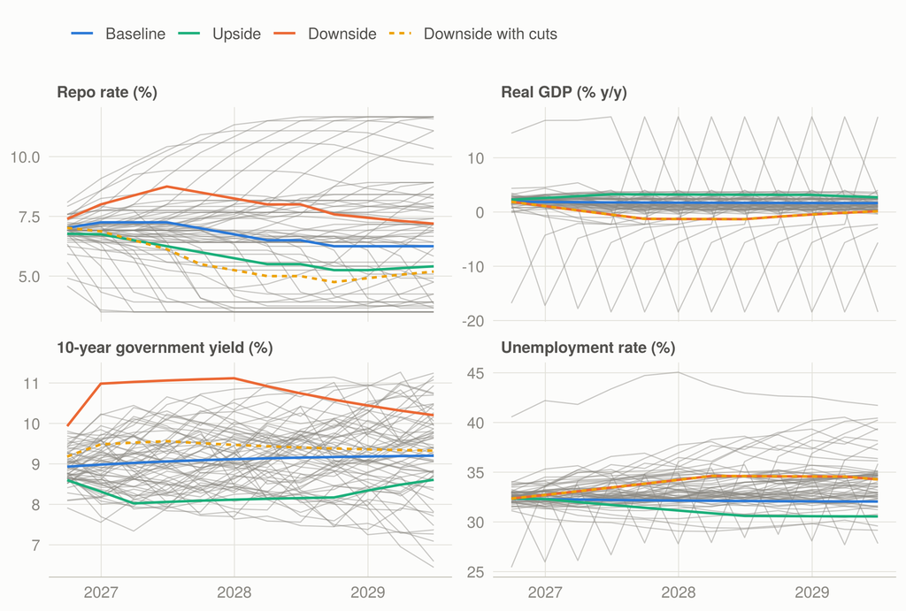

The macro episodes replayed from the jump-off (grey: each a 12-quarter window of South African history since 2008, applied to today’s starting point) and the scenarios (colour).

**Table view: the episodes in numbers**

| Statistic | Repo rate, average change from the jump-off (pp) | Real GDP growth, average (%) | Real GDP growth, trough (%) | Unemployment, change over the episode (pp) | 10-year yield, change over the episode (pp) |
| --- | --- | --- | --- | --- | --- |
| Minimum | -3.3 | -1.8 | -18.4 | -4.6 | -2.4 |
| 25th percentile | -1.3 | 1.0 | -1.0 | 0.2 | -0.1 |
| Median | -0.2 | 1.3 | 0.3 | 1.6 | 0.5 |
| 75th percentile | 0.9 | 1.9 | 0.8 | 2.5 | 1.1 |
| Maximum | 3.5 | 6.7 | 2.2 | 9.3 | 2.4 |

The episodes span far more than the three scenarios. The policy rate averages anywhere from 3.3 points below today’s to 3.5 above (26 episodes with higher rates on average, 27 with lower, 8 broadly flat), real GDP growth averages between -1.8% and 6.7%, and the deepest quarter is the pandemic’s -18%. The 3.5% floor on the policy rate binds in 5 episodes, those that replay the 2008–09 cuts from today’s lower starting point, and the zero floor on inflation in 7.

## 15.2 The plan across the histories

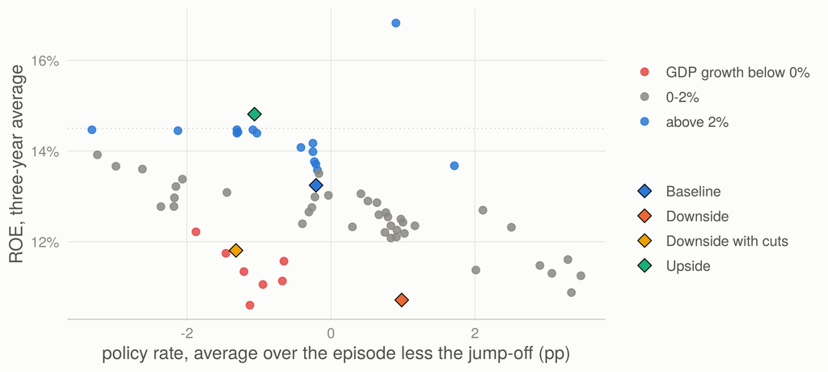

NGFB’s plan across the episodes: three-year average ROE against the episode’s average policy rate relative to the jump-off, coloured by average real GDP growth. Diamonds: the scenarios. Dotted: the 14.5% cost of equity.

**Table view: the plan in each episode**

| Episode | Repo, average change (pp) | GDP growth, average (%) | Plan ROE | CET1 trough (fair value) |
| --- | --- | --- | --- | --- |
| 2008Q2-2011Q1 | -2.06 | 1.4 | 13.4% | 12.7% |
| 2008Q3-2011Q2 | -2.62 | 1.3 | 13.6% | 12.8% |
| 2008Q4-2011Q3 | -2.99 | 1.4 | 13.7% | 12.8% |
| 2009Q1-2011Q4 | -3.24 | 1.8 | 13.9% | 12.9% |
| 2009Q2-2012Q1 | -3.32 | 2.5 | 14.5% | 12.8% |
| 2009Q3-2012Q2 | -2.12 | 2.9 | 14.4% | 12.9% |
| 2009Q4-2012Q3 | -1.31 | 3.0 | 14.4% | 12.9% |
| 2010Q1-2012Q4 | -1.31 | 3.0 | 14.5% | 12.9% |
| 2010Q2-2013Q1 | -1.29 | 2.8 | 14.4% | 12.9% |
| 2010Q3-2013Q2 | -1.08 | 2.7 | 14.5% | 12.8% |
| 2010Q4-2013Q3 | -1.03 | 2.6 | 14.4% | 12.6% |
| 2011Q1-2013Q4 | -0.42 | 2.5 | 14.1% | 12.7% |
| 2011Q2-2014Q1 | -0.25 | 2.3 | 14.2% | 12.6% |
| 2011Q3-2014Q2 | -0.25 | 2.2 | 14.0% | 12.5% |
| 2011Q4-2014Q3 | -0.23 | 2.2 | 13.8% | 12.4% |
| 2012Q1-2014Q4 | -0.21 | 2.1 | 13.7% | 12.4% |
| 2012Q2-2015Q1 | -0.19 | 2.1 | 13.6% | 12.4% |
| 2012Q3-2015Q2 | -0.17 | 1.9 | 13.5% | 12.4% |
| 2012Q4-2015Q3 | 0.42 | 1.9 | 13.1% | 12.2% |
| 2013Q1-2015Q4 | 0.51 | 1.8 | 12.9% | 12.3% |
| 2013Q2-2016Q1 | 0.67 | 1.5 | 12.6% | 12.3% |
| 2013Q3-2016Q2 | 0.83 | 1.4 | 12.4% | 12.2% |
| 2013Q4-2016Q3 | 1.00 | 1.3 | 12.4% | 12.4% |
| 2014Q1-2016Q4 | 1.17 | 1.2 | 12.4% | 12.4% |
| 2014Q2-2017Q1 | 0.79 | 1.3 | 12.5% | 12.5% |
| 2014Q3-2017Q2 | 0.92 | 1.2 | 12.3% | 12.6% |
| 2014Q4-2017Q3 | 0.75 | 1.2 | 12.2% | 12.6% |
| 2015Q1-2017Q4 | 0.83 | 1.0 | 12.1% | 12.5% |
| 2015Q2-2018Q1 | 0.91 | 0.9 | 12.1% | 12.5% |
| 2015Q3-2018Q2 | 0.97 | 1.3 | 12.5% | 12.6% |
| 2015Q4-2018Q3 | 0.76 | 1.3 | 12.6% | 12.6% |
| 2016Q1-2018Q4 | 0.64 | 1.3 | 12.9% | 12.7% |
| 2016Q2-2019Q1 | -0.03 | 1.3 | 13.0% | 12.8% |
| 2016Q3-2019Q2 | -0.22 | 1.3 | 13.0% | 12.8% |
| 2016Q4-2019Q3 | -0.26 | 1.3 | 12.8% | 12.8% |
| 2017Q1-2019Q4 | -0.31 | 1.3 | 12.7% | 12.8% |
| 2017Q2-2020Q1 | -0.40 | 1.1 | 12.4% | 12.8% |
| 2017Q3-2020Q2 | -0.65 | -0.6 | 11.6% | 12.7% |
| 2017Q4-2020Q3 | -0.67 | -1.1 | 11.1% | 12.7% |
| 2018Q1-2020Q4 | -0.94 | -1.5 | 11.1% | 12.8% |
| 2018Q2-2021Q1 | -1.12 | -1.8 | 10.6% | 12.6% |
| 2018Q3-2021Q2 | -1.21 | -0.3 | 11.3% | 12.6% |
| 2018Q4-2021Q3 | -1.46 | -0.5 | 11.7% | 12.6% |
| 2019Q1-2021Q4 | -1.87 | -0.4 | 12.2% | 12.5% |
| 2019Q2-2022Q1 | -2.18 | 0.1 | 12.8% | 12.6% |
| 2019Q3-2022Q2 | -2.36 | 0.0 | 12.8% | 12.6% |
| 2019Q4-2022Q3 | -2.17 | 0.3 | 13.0% | 12.5% |
| 2020Q1-2022Q4 | -2.15 | 0.4 | 13.2% | 12.5% |
| 2020Q2-2023Q1 | -1.44 | 0.4 | 13.1% | 12.4% |
| 2020Q3-2023Q2 | 0.90 | 6.7 | 16.8% | 12.8% |
| 2020Q4-2023Q3 | 1.72 | 2.4 | 13.7% | 12.4% |
| 2021Q1-2023Q4 | 2.11 | 1.6 | 12.7% | 12.3% |
| 2021Q2-2024Q1 | 2.51 | 1.5 | 12.3% | 12.4% |
| 2021Q3-2024Q2 | 2.90 | 1.1 | 11.5% | 12.4% |
| 2021Q4-2024Q3 | 3.29 | 1.7 | 11.6% | 12.3% |
| 2022Q1-2024Q4 | 3.47 | 1.2 | 11.3% | 12.4% |
| 2022Q2-2025Q1 | 3.34 | 0.7 | 10.9% | 12.5% |
| 2022Q3-2025Q2 | 3.07 | 1.1 | 11.3% | 12.5% |
| 2022Q4-2025Q3 | 2.01 | 0.6 | 11.4% | 12.5% |
| 2023Q1-2025Q4 | 1.02 | 1.3 | 12.2% | 12.6% |
| 2023Q2-2026Q1 | 0.30 | 1.2 | 12.3% | 12.7% |

NGFB’s plan averages 12.8% across the episodes, a little below the baseline, between 10.6% (2018Q2-2021Q1, through the pandemic) and 16.8% (2020Q3-2023Q2, the rebound from it), with a 5th percentile of 11.1%. It earns the 14.5% cost of equity in 1 of the 61 histories. Two macro numbers explain almost all of the spread ($R^2$ = 0.95 across the episodes): each point of average GDP growth adds 81 bps of ROE, and each point by which the policy rate averages above today’s costs 35 bps, the liability sensitivity the hedge gives NGFB. Unemployment adds nothing once growth is known, because the engine has no unemployment channel (What didn’t work). The regression is descriptive: overlapping windows make its precision look better than it is.

In symbols, the regression across the episodes is

$$\overline{\text{ROE}}_e \;\approx\; a \;+\; b_{\text{gdp}}\,\bar g_e \;+\; b_{\text{repo}}\,\overline{\Delta r}_e ,$$

with $\bar g_e$ the episode’s average GDP growth and $\overline{\Delta r}_e$ the amount by which its policy rate averages above today’s.

Every strategy below is judged the way an ALCO would judge it: its average ROE across the episodes, its bad case (the 5th percentile), how often it beats the plan, and two risks the three-year ROE does not price. The first is the CET1 trough with any bonds at fair value, so that the OCI reserve counts. The second is interest-rate risk, measured the way the IRRBB outlier test measures it (BCBS 2016), as the change in the economic value of the hedge and bond books for a 200 bp rise:

$$\frac{\Delta \text{EVE}}{\text{CET1}} \;=\; \frac{200 \times \text{PV01}}{\text{CET1}} ,$$

where PV01 is the change in the books’ value for a one basis point parallel move.

## 15.3 Static positioning: the hedge frontier

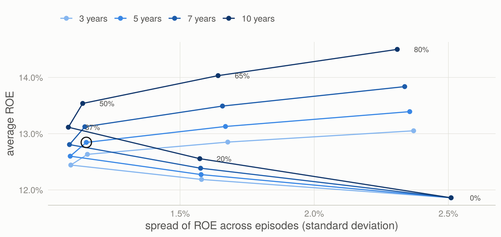

Static positioning of the structural hedge across the episodes: average ROE against its spread (standard deviation across episodes), for each hedge ratio (labels) and reinvestment tenor (lines). The plan is ringed. Changes are made at the jump-off with 5-year swaps at the market rate; maturing tranches are reinvested at the tenor shown.

**Table view: every static hedge setting**

| Hedge ratio | Tenor | Average ROE | Spread (sd) | 5th percentile | vs plan, average | EVE change for +200 bps vs plan (% of CET1) | Efficient |
| --- | --- | --- | --- | --- | --- | --- | --- |
| 0% | 3 years | 11.86% | 2.51 pp | 8.1% | -98 bps | +15.4% |  |
| 0% | 5 years | 11.86% | 2.51 pp | 8.1% | -98 bps | +15.4% |  |
| 0% | 7 years | 11.86% | 2.51 pp | 8.1% | -98 bps | +15.4% |  |
| 0% | 10 years | 11.86% | 2.51 pp | 8.1% | -98 bps | +15.4% |  |
| 20% | 3 years | 12.19% | 1.58 pp | 9.5% | -66 bps | +11.8% |  |
| 20% | 5 years | 12.27% | 1.58 pp | 9.6% | -57 bps | +9.1% |  |
| 20% | 7 years | 12.39% | 1.58 pp | 9.7% | -46 bps | +6.8% |  |
| 20% | 10 years | 12.56% | 1.57 pp | 9.9% | -29 bps | +4.0% |  |
| 37% | 3 years | 12.44% | 1.09 pp | 10.4% | -40 bps | +8.8% |  |
| 37% | 5 years | 12.60% | 1.09 pp | 10.6% | -25 bps | +4.0% |  |
| 37% | 7 years | 12.81% | 1.09 pp | 10.8% | -4 bps | -0.2% |  |
| 37% | 10 years | 13.11% | 1.08 pp | 11.1% | +27 bps | -5.3% | yes |
| 50% | 3 years | 12.63% | 1.15 pp | 10.9% | -21 bps | +6.5% |  |
| 50% | 5 years | 12.85% | 1.15 pp | 11.1% | +0 bps | +0.0% |  |
| 50% | 7 years | 13.12% | 1.15 pp | 11.4% | +28 bps | -5.6% |  |
| 50% | 10 years | 13.54% | 1.14 pp | 11.8% | +69 bps | -12.4% | yes |
| 65% | 3 years | 12.85% | 1.68 pp | 9.8% | +1 bps | +3.8% |  |
| 65% | 5 years | 13.13% | 1.67 pp | 10.1% | +28 bps | -4.7% |  |
| 65% | 7 years | 13.49% | 1.66 pp | 10.5% | +65 bps | -12.0% |  |
| 65% | 10 years | 14.03% | 1.64 pp | 11.1% | +119 bps | -20.9% | yes |
| 80% | 3 years | 13.05% | 2.37 pp | 8.4% | +21 bps | +1.2% |  |
| 80% | 5 years | 13.39% | 2.36 pp | 8.8% | +55 bps | -9.3% |  |
| 80% | 7 years | 13.84% | 2.34 pp | 9.3% | +99 bps | -18.1% |  |
| 80% | 10 years | 14.50% | 2.31 pp | 10.0% | +165 bps | -28.9% | yes |

Three things stand out.

- **ROE varies least near the rate-neutral ratio.** The spread across the episodes is smallest at 37% at 10 years (1.08 pp, against the plan’s 1.15 pp); both more and less receive-fixed widen it, because the hedge then dominates or the endowment does.
- **Longer reinvestment pays at every ratio, whichever way rates go.** At the plan’s ratio, reinvesting at ten years instead of five adds +69 bps on average and beats the plan in every episode (+70 bps when rates rise, +69 bps when they fall): it is the swap curve’s term premium, which the constant term spreads hold at its 2023–2026 level in every episode, so a flatter curve would pay less. Every efficient static setting reinvests at ten years. The cost is outside the ROE: a 200 bps rise would take a further 12.4% of CET1 off the books’ value.
- **More hedge is a rate view.** Receiving fixed on 80% of deposits at five years adds +55 bps on average, but -100 bps when rates rise and +199 bps when they fall, with a 5th percentile of -266 bps. Its average is positive because the extra swaps are struck at the jump-off’s 5-year rate (7.49%), above the floating rate the episodes imply from here on average – the same bet More levers found in the scenarios.

## 15.4 Rules that read the macro picture

Change in NGFB’s three-year average ROE against the plan across the 61 episodes, with the risk each strategy adds. CET1 trough: the lowest quarter in any episode, with bonds bought for HQLA at fair value. EVE: the change in the value of the hedge and bond books for a 200 bps parallel rise, against the plan’s, at the end of the horizon (the deposits’ own behavioural duration is the same under every strategy). Plan: 12.2% in the worst episode, 0% of episodes below the 11.5% floor.

| Type | Strategy | Average | 5th percentile | Beats the plan | NII, 3 years, average | CET1 trough, worst episode | Episodes below the CET1 floor | EVE for +200 bps vs plan (% of CET1) |
| --- | --- | --- | --- | --- | --- | --- | --- | --- |
| Rule | R1 hedge ratio with the policy rate | -2 bps | -168 bps | 62% | +R0.0 bn | 12.0% | 0% | -1.1% |
| Rule | R2 reinvestment tenor with the policy rate | +44 bps | -4 bps | 92% | +R2.1 bn | 12.3% | 0% | -6.3% |
| Rule | R3 HQLA duration with the curve’s slope | +138 bps | -70 bps | 87% | +R6.9 bn | 11.9% | 0% | -6.9% |
| Rule | R4 payout with growth and capital | +10 bps | +1 bps | 97% | -R0.3 bn | 12.3% | 0% | -0.2% |
| Rule | R5 unsecured growth with the labour market | -2 bps | -12 bps | 31% | +R0.2 bn | 12.0% | 0% | 0.0% |
| Rule | R6 asset swap with the bond-swap spread | +24 bps | +9 bps | 100% | +R1.0 bn | 12.3% | 0% | +0.1% |
| Rule | R7 liquidity buffer with stress | +40 bps | +32 bps | 100% | +R2.0 bn | 12.3% | 0% | +0.1% |
| Rule | All seven rules | +290 bps | -33 bps | 93% | +R13.1 bn | 11.5% | 0% | -20.4% |
| Static | 65% at 5 years | +28 bps | -134 bps | 61% | +R1.4 bn | 12.1% | 0% | -4.7% |
| Static | 50% at 10 years | +69 bps | +67 bps | 100% | +R3.4 bn | 12.3% | 0% | -12.4% |
| Static | 25% of HQLA in 10-year bonds | +99 bps | -47 bps | 90% | +R4.9 bn | 11.4% | 2% | -6.9% |
| Static | 50% of HQLA in 10-year bonds | +196 bps | -95 bps | 90% | +R9.9 bn | 10.4% | 25% | -13.7% |
| Static | 25% of HQLA in asset-swapped 5-year bonds | +38 bps | +37 bps | 100% | +R1.9 bn | 12.3% | 0% | +0.1% |
| Static | Buffer at an LCR of 170% | +49 bps | +48 bps | 100% | +R2.4 bn | 12.3% | 0% | +0.1% |
| Static | 70% payout | +29 bps | +10 bps | 100% | -R0.9 bn | 11.3% | 13% | -1.2% |
| Bound | Best static hedge ratio with hindsight | +165 bps | +29 bps | 100% | +R8.2 bn | 12.2% | 0% | +0.7% |

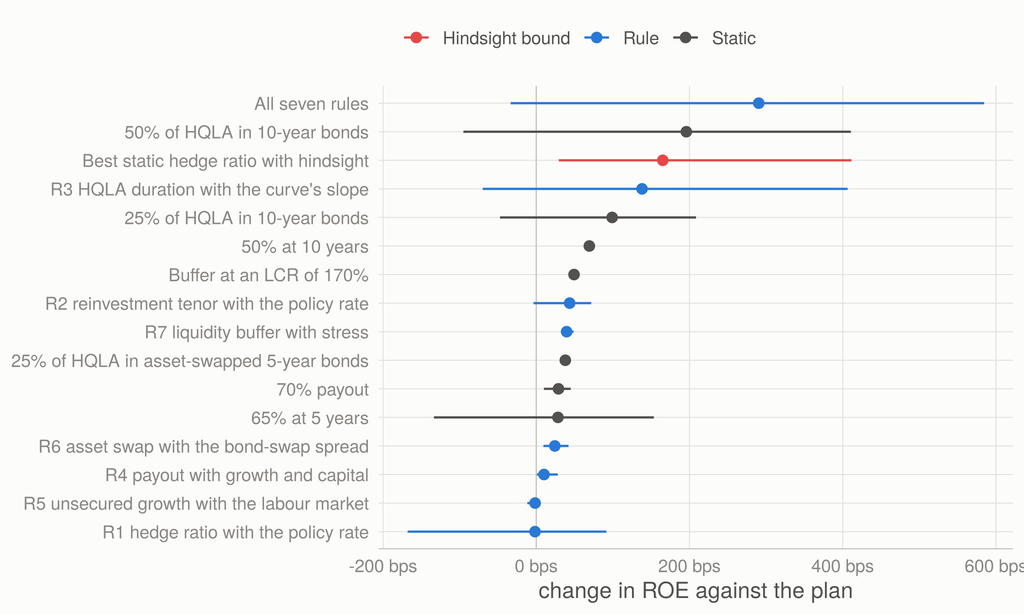

Change in ROE against the plan across the episodes: the average (dot) and the 5th to 95th percentile (line).

**Table view**

| Strategy | Type | Average | 5th percentile | 95th percentile |
| --- | --- | --- | --- | --- |
| 25% of HQLA in 10-year bonds | Static | +99 bps | -47 bps | +209 bps |
| 25% of HQLA in asset-swapped 5-year bonds | Static | +38 bps | +37 bps | +40 bps |
| 50% at 10 years | Static | +69 bps | +67 bps | +72 bps |
| 50% of HQLA in 10-year bonds | Static | +196 bps | -95 bps | +411 bps |
| 65% at 5 years | Static | +28 bps | -134 bps | +154 bps |
| 70% payout | Static | +29 bps | +10 bps | +45 bps |
| All seven rules | Rule | +290 bps | -33 bps | +585 bps |
| Best static hedge ratio with hindsight | Hindsight bound | +165 bps | +29 bps | +411 bps |
| Buffer at an LCR of 170% | Static | +49 bps | +48 bps | +52 bps |
| R1 hedge ratio with the policy rate | Rule | -2 bps | -168 bps | +92 bps |
| R2 reinvestment tenor with the policy rate | Rule | +44 bps | -4 bps | +72 bps |
| R3 HQLA duration with the curve’s slope | Rule | +138 bps | -70 bps | +406 bps |
| R4 payout with growth and capital | Rule | +10 bps | +1 bps | +28 bps |
| R5 unsecured growth with the labour market | Rule | -2 bps | -12 bps | +6 bps |
| R6 asset swap with the bond-swap spread | Rule | +24 bps | +9 bps | +42 bps |
| R7 liquidity buffer with stress | Rule | +40 bps | +32 bps | +49 bps |

- **R1, the hedge ratio keyed on the level of rates, adds nothing.** On average -2 bps, with a 5th percentile of -168 bps: it gains when a high rate is followed by cuts and loses when rates keep rising, and in history the two came about equally often. The prize is real – choosing the right static ratio for each episode with hindsight adds +165 bps – but the level of the policy rate does not reveal it.
- **R2, the reinvestment tenor keyed on rates, pays less than always going long.** +44 bps on average against +69 bps for ten years throughout: each quarter spent at three or five years gives up term premium the timing does not win back.
- **R3, HQLA duration keyed on the curve’s slope, earns the most of any single rule, but not in every episode.** It adds +138 bps on average against +99 bps for a fixed quarter of HQLA in bonds, with a better CET1 trough at fair value (11.9% against 11.4%) at the same EVE risk (6.9% of CET1 for a 200 bps rise). A steep curve pays more carry and tends to flatten as long yields fall, so buying duration when the slope is high and holding less when it is low collects the bond’s excess return when it is largest – the term-premium evidence of Fama and Bliss and of Campbell and Shiller, here in South African data. But the rule trades its book, and under IFRS 9 a bond sold out of a fair-value-through-OCI book takes its accumulated gain or loss into profit. A curve flattens most often because the SARB is hiking, when long yields rise too, so R3 sells at a loss in hiking cycles: its realised losses average R1,176 m before tax over the episodes in which rates rose, against gains of R845 m where they fell. It adds +10 bps when rates rise against +273 bps when they fall, beats the plan in 87% of the episodes, and its 5th percentile is -70 bps. Today’s slope, 1.93 pp, is below its median, so the rule would start at 19% of HQLA, not a quarter.
- **R4, payout keyed on growth and capital, adds a little and protects capital.** +10 bps on average with a CET1 trough of 12.3%, above the plan’s 12.2%; a flat 70% payout adds +29 bps but takes 13% of the episodes below the 11.5% floor. Paying more when the economy grows and capital is ample, and less otherwise, keeps capital where the downturns are.
- **R5, unsecured lending keyed on the labour market, does nothing here** (-2 bps). The engine applies the sector’s loss rate to the whole book, with no vintages, so the timing of origination cannot pay; a bank with its own vintage loss curves should run this test on them.
- **R6, the asset swap keyed on the bond–swap spread, and R7, the buffer keyed on stress, beat the plan in every episode, and take no rate risk.** A static quarter of HQLA in asset-swapped bonds adds +38 bps (5th percentile +37 bps), and R6 +24 bps: the rule holds little while the spread is as tight as it is today and buys only where an episode’s fiscal stress widens it. Releasing bills to an LCR of 170% adds +49 bps in every episode; R7, which rebuilds the buffer to 185% after a stress signal (27% of the episodes’ quarters), adds +40 bps. The 10 bps between them is what the insurance costs; what it buys – not having to sell assets or pay up for funding in a run – is not in the engine, which does not stress run-offs or funding spreads.
- **All seven together** add +290 bps on average and beat the plan in 93% of the episodes, which lifts the share of histories in which NGFB earns its cost of equity from 2% to 72%. Most of it is duration – ten-year reinvestment when rates are high and bonds when the curve is steep – and so is most of the risk: a 200 bps rise would take a further 20% of CET1 off the books’ value, and the CET1 trough at fair value falls to 11.51%, just above the 11.5% floor. Seven rules stacked without a risk budget use more of the bank’s risk capacity than anyone set out to give them, which is what the risk-budgeted optimiser is for.

## 15.5 Rising and falling rates

Average change in ROE against the plan by the direction of the policy rate over the episode: rising (average more than 25 bps above the jump-off, 26 episodes), falling (more than 25 bps below, 27) and flat (8).

| Strategy | Rates rise | Rates fall | Rates flat |
| --- | --- | --- | --- |
| R1 hedge ratio with the policy rate | -56 bps | +45 bps | +17 bps |
| R2 reinvestment tenor with the policy rate | +68 bps | +20 bps | +41 bps |
| R3 HQLA duration with the curve’s slope | +10 bps | +273 bps | +100 bps |
| R4 payout with growth and capital | +7 bps | +12 bps | +14 bps |
| R6 asset swap with the bond-swap spread | +26 bps | +26 bps | +11 bps |
| R7 liquidity buffer with stress | +42 bps | +38 bps | +39 bps |
| All seven rules | +156 bps | +434 bps | +242 bps |
| 65% at 5 years | -50 bps | +102 bps | +35 bps |
| 50% at 10 years | +70 bps | +69 bps | +68 bps |
| 25% of HQLA in 10-year bonds | +30 bps | +164 bps | +104 bps |
| 50% of HQLA in 10-year bonds | +59 bps | +324 bps | +206 bps |
| 25% of HQLA in asset-swapped 5-year bonds | +39 bps | +37 bps | +37 bps |
| Buffer at an LCR of 170% | +50 bps | +48 bps | +49 bps |
| 70% payout | +21 bps | +35 bps | +34 bps |
| Best static hedge ratio with hindsight | +160 bps | +199 bps | +68 bps |

The hedge ratio, static or keyed on rates, is a bet on the direction of rates: it wins when they fall and loses when they rise. The tenor and the slope rule earn in both directions, the slope rule most when rates fall and the bonds rally.

## 15.6 If the swap curve priced the path

The hedge strategies when swap rates price half of the coming policy path (each tenor moved by half the gap between the average benchmark over its life and today’s), against the constant term spreads the scenarios use. Average change in ROE against the plan, priced the same way.

| Strategy | Constant term spreads | Curve prices half the path | Beats the plan |
| --- | --- | --- | --- |
| R1 hedge ratio with the policy rate | -2 bps | +4 bps | 66% |
| R2 reinvestment tenor with the policy rate | +44 bps | +43 bps | 90% |
| 80% at 5 years | +55 bps | +58 bps | 66% |
| 65% at 5 years | +28 bps | +30 bps | 66% |
| 20% at 5 years | -57 bps | -59 bps | 34% |
| 0% at 5 years | -98 bps | -102 bps | 34% |
| Best static hedge ratio with hindsight | +165 bps | +145 bps | 100% |

## 15.7 What the lab says about positioning

1. **Lock in the term premium; do not time the rate cycle.** Reinvesting the hedge at ten years paid in every episode; keying the hedge ratio on the level of rates paid in none on average. The ratio is a structural decision, best near the rate-neutral 37% where earnings vary least, and a higher ratio is a sized rate view, not a default.
2. **Run HQLA duration off the curve’s slope, and expect to give some back in hiking cycles.** It is the rule that adds most on its own, with a better capital trough than a fixed bond holding; its realised losses when the SARB hikes are the price of the trading.
3. **Collect the spreads that need no rate view.** Asset-swapped bonds (the fiscal premium) and a smaller buffer (the wholesale–bill spread) beat the plan in every episode with no EVE cost; their limits are spread risk and the bank’s own liquidity stress test.
4. **Make the payout state-contingent.** A little more ROE and a higher capital trough than a fixed ratio.
5. **Size the risk explicitly.** The rules that pay most are duration, and together they need an EVE budget of about a fifth of CET1 for a 200 bps rise and leave little room above the CET1 floor. Choosing the levers together, under limits, is the next chapter.
6. **Expect little from credit timing in this engine** – and test it on vintage loss data before concluding it does not pay.

# 16 Choosing the levers together: a risk-budgeted optimiser

The lab tests one strategy at a time. An ALCO sets the levers together, and under limits: a risk appetite that bounds how bad earnings may get, how low capital and liquidity may fall, and how much interest-rate risk the banking book may carry. Stacked without such limits, the lab’s seven rules added +290 bps but used 20% of CET1 of EVE sensitivity and took the CET1 trough to 11.51%. This chapter asks the question the other way round: *given a risk budget, which combination of the levers earns NGFB the most across the sixty macro histories, and how does each lever’s contribution depend on the macro path?*

## 16.1 The problem

The objective is NGFB’s three-year average ROE, averaged across the 61 episodes (each history weighted equally). A combination $x$ sets six decisions: the hedge ratio and the reinvestment tenor (run together, because they interact), the share of earning HQLA in ten-year bonds, the share in asset-swapped five-year bonds, the size of the buffer, and the payout. Each can be fixed today or follow its macro rule:

$$\max_{x}\; \frac{1}{61}\sum_{e} \overline{\text{ROE}}_e(x)$$

subject to, in every quarter $t$ of every episode $e$,

The risk budget. The IRRBB outlier test flags a bank whose economic value falls by more than 15% of Tier 1 capital in the worst of six prescribed shocks; with no behavioural model of the deposits’ own value, the budget here bounds the change from the plan’s position, and 5% of CET1 – a third of that threshold – is the central budget.

| Limit | Condition | Why |
| --- | --- | --- |
| Tail | 5th percentile of $\overline{\text{ROE}}_e(x)$ across episodes $\geq$ the plan’s (11.1%) | a higher average bought with a worse bad case is a bet, not positioning |
| Capital | CET1 with the bonds’ OCI reserve $\geq$ 11.5% | the management floor of the positioning chapter, at fair value |
| Liquidity | LCR with HQLA at market value $\geq$ 120%; NSFR $\geq$ 110% | management floors above the 100% minima (the NSFR floor is an assumption) |
| Interest-rate risk | $\lvert \Delta\text{EVE}_{e,t}(x) - \Delta\text{EVE}_{e,t}(\text{plan}) \rvert \leq B$ of CET1 for a 200 bps parallel shock | the plan is taken as the bank’s accepted position; $B$ bounds how far strategy moves it, either way |
| Liquidity book | ten-year bonds + asset swaps + released bills $\leq$ 90% of earning HQLA | some bills stay for day-to-day liquidity management |

The levers and their settings: 25,200 combinations, 18,900 of them within the cap on the liquidity book. Shares of HQLA are of the jump-off’s earning HQLA. R5 is left out: it does nothing in this engine.

| Lever | Settings | Options |
| --- | --- | --- |
| Hedge ratio | 0%, 20%, 37%, 50%, 65%, 80%, or R1 | 7 |
| Reinvestment tenor | 3 years, 5 years, 7 years, 10 years, or R2 | 5 |
| 10-year bonds | 0%, 12.5%, 25%, 37.5%, 50%, or R3 | 6 |
| Asset-swapped bonds | 0%, 12.5%, 25%, 37.5%, 50%, or R6 | 6 |
| Size of the buffer | the plan’s (LCR 191%), LCR 180%, LCR 170%, LCR 160%, or R7 | 5 |
| Payout | 30%, 50%, 70%, or R4 | 4 |

## 16.2 How it is solved

[output not shown]

1. **Each setting on its own.** Every setting of every lever runs through the engine with everything else at the plan, on every path – the 61 episodes, the three scenarios and the downside with cuts: 52 runs per path. Each run keeps, quarter by quarter, net income, RWA, the bond books’ OCI reserve, the PV01 of the hedge and bond books, the LCR and the NSFR.
2. **A surrogate for every combination.** A combination’s changes against the plan are added quarter by quarter: the levers act on different parts of the balance sheet (the hedge on NII, the bond books on NII and OCI, the buffer on HQLA and wholesale funding). The exception is the payout, which acts on every rand the other levers add, so equity is rolled forward with the combination’s own payout – a fixed ratio, or R4 reading the combination’s own CET1 – and ROE, CET1 and the EVE ratio are computed from it, with the funding plug’s interest following the equity actually retained. The surrogate reproduces every single setting’s run exactly; on every combination run exactly below it is within 0.03 bp of ROE.
3. **Every combination, not a search.** All 25,200 combinations are scored on all episodes and quarters, minima and percentiles taken after adding, and the best that meets the limits is taken at each EVE budget. There is no optimisation heuristic to get stuck: the frontier is exact for the grid.
4. **Exact runs.** Every chosen combination is run through the engine on every path, and the limits are checked on those runs.
5. **Out of sample.** The optimum chosen on the first 25 episodes is scored on the last 25, and the reverse; the 11 episodes in between share quarters with both halves and are left out.

Step 2 in symbols: a combination’s change in net income is the sum of its settings’ changes, and equity is rolled forward with the combination’s own payout,

$$\Delta\text{NI}_{e,t}(x) \;\approx\; \sum_{k} \Delta\text{NI}_{e,t}(x_k), \qquad E_{e,t}(x) \;=\; E_{e,t-1}(x) \;+\; \big(1-\pi_{e,t}(x)\big)\,\text{NI}_{e,t}(x) ,$$

where $\pi_{e,t}(x)$ is the payout ratio: a fixed number, or rule R4 reading the combination’s own CET1 ratio. Running every combination through the engine on every path would mean about 1.6 million engine runs, the strategic-planning equivalent of a queue at Home Affairs; the surrogate needs 52 per path.

## 16.3 The frontier

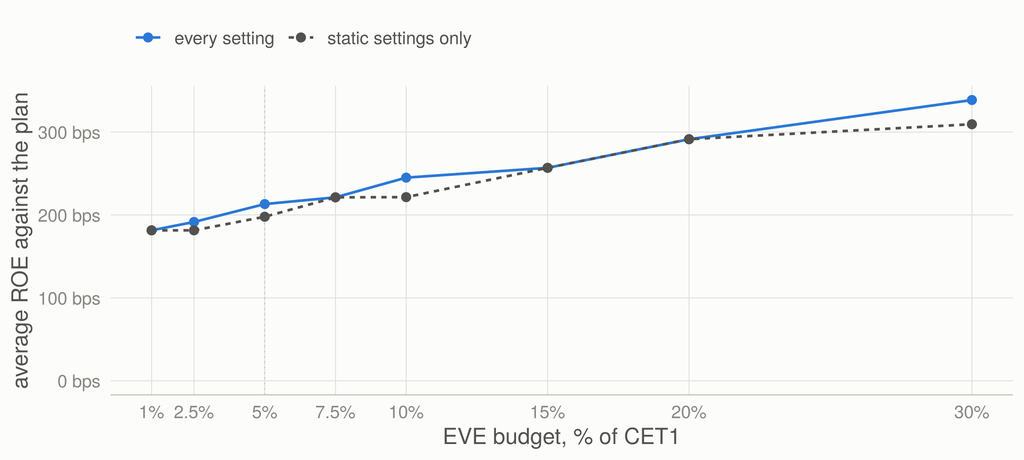

The risk-budgeted frontier: the best change in NGFB’s average ROE across the episodes that meets every limit, at each EVE budget (the largest change in the hedge and bond books’ economic value for a ±200 bps shock against the plan’s, as a share of CET1). With every setting (rules allowed) and with static settings only. Dotted: the central budget.

**Table view: the best combination at each budget**

| Budget | Settings | Hedge ratio | Tenor | 10-year bonds | Asset swap | Buffer | Payout | ROE vs plan | 5th percentile vs plan | CET1 trough | EVE used |
| --- | --- | --- | --- | --- | --- | --- | --- | --- | --- | --- | --- |
| 1.0% | every setting | 20% | 7 years | 25% | 37.5% | LCR 160% | 50% | +181 bps | +142 bps | 11.68% | 0.7% |
| 2.5% | every setting | 37% | 5 years | 12.5% | 50% | LCR 160% | R4 | +192 bps | +175 bps | 11.73% | 1.0% |
| 5.0% | every setting | 37% | 7 years | 12.5% | 50% | LCR 160% | R4 | +213 bps | +197 bps | 11.73% | 4.6% |
| 7.5% | every setting | 37% | 7 years | 25% | 37.5% | LCR 160% | 50% | +221 bps | +222 bps | 11.61% | 7.0% |
| 10.0% | every setting | 37% | 10 years | 12.5% | 50% | LCR 160% | R4 | +245 bps | +229 bps | 11.74% | 10.0% |
| 15.0% | every setting | 50% | 10 years | 0% | 50% | LCR 160% | 70% | +257 bps | +250 bps | 11.51% | 14.4% |
| 20.0% | every setting | 50% | 10 years | 25% | 37.5% | LCR 160% | 50% | +291 bps | +197 bps | 11.51% | 19.8% |
| 30.0% | every setting | 65% | 10 years | 12.5% | 50% | LCR 160% | R4 | +339 bps | +123 bps | 11.75% | 27.1% |
| 1.0% | static only | 20% | 7 years | 25% | 37.5% | LCR 160% | 50% | +181 bps | +142 bps | 11.68% | 0.7% |
| 2.5% | static only | 20% | 7 years | 25% | 37.5% | LCR 160% | 50% | +181 bps | +142 bps | 11.68% | 0.7% |
| 5.0% | static only | 20% | 10 years | 25% | 37.5% | LCR 160% | 50% | +198 bps | +159 bps | 11.68% | 3.0% |
| 7.5% | static only | 37% | 7 years | 25% | 37.5% | LCR 160% | 50% | +221 bps | +222 bps | 11.61% | 7.0% |
| 10.0% | static only | 50% | 7 years | 12.5% | 50% | LCR 160% | 50% | +222 bps | +197 bps | 11.93% | 9.0% |
| 15.0% | static only | 50% | 10 years | 0% | 50% | LCR 160% | 70% | +257 bps | +250 bps | 11.51% | 14.4% |
| 20.0% | static only | 50% | 10 years | 25% | 37.5% | LCR 160% | 50% | +291 bps | +197 bps | 11.51% | 19.8% |
| 30.0% | static only | 65% | 10 years | 12.5% | 50% | LCR 160% | 50% | +309 bps | +119 bps | 11.81% | 25.4% |

Most of the gain needs almost no EVE budget. With 1% of CET1 the best combination already adds +181 bps; at the central 5% it adds +213 bps, and the next five points of budget add 32 bps more. The reason is that the largest levers are spreads, not duration: the asset swap and the smaller buffer take no interest-rate risk at all. Beyond 10% of CET1 the frontier buys ROE with duration – ten-year reinvestment and a hedge ratio back at or above the plan’s – and the tail starts to give: at 30% the average gain is +339 bps but the 5th percentile gains only +123 bps, against +229 bps at 10%. Static settings alone come within 15 bps of the frontier at the central budget.

## 16.4 The risk-budgeted portfolio

The best combination at an EVE budget of 5% of CET1, with every setting allowed and with static settings only.

| Lever | Plan | Risk-budgeted | Static settings only |
| --- | --- | --- | --- |
| Hedge ratio | 49.6% of non-maturity deposits | 37% of non-maturity deposits | 20% of non-maturity deposits |
| Reinvestment tenor | 5 years | 7 years | 10 years |
| 10-year bonds in HQLA | none | 12.5% of earning HQLA | 25% of earning HQLA |
| Asset-swapped bonds in HQLA | none | 50% of earning HQLA | 37.5% of earning HQLA |
| Size of the buffer | LCR 191% | LCR 160% | LCR 160% |
| Payout | 50% | R4: 70% while GDP grows and CET1 is above 12.5%, 30% otherwise | 50% |

The portfolios across the 61 episodes, run exactly through the engine. Lowest and largest: across every quarter of every episode.

| Measure | Plan | Risk-budgeted | Static settings only |
| --- | --- | --- | --- |
| Average ROE across the episodes | 12.85% | 14.98% | 14.82% |
| against the plan |  | +213 bps | +198 bps |
| 5th percentile of ROE | 11.14% | 13.11% | 12.73% |
| Episodes beating the plan |  | 100% | 100% |
| NII over three years, average | R139.3 bn | R148.2 bn | R149.2 bn |
| CET1 at fair value, lowest quarter | 12.21% | 11.73% | 11.68% |
| LCR at market value, lowest quarter | 180% | 149% | 148% |
| EVE change for ±200 bps, largest (% of CET1) | 0.0% | 4.6% | 3.0% |
| Earning HQLA out of bills, largest | 0% | 89% | 89% |

At a budget of 5% of CET1 the optimiser keeps the hedge at the rate-neutral 37% of non-maturity deposits instead of the plan’s 49.6%, reinvests maturing tranches at 7 years, holds 12.5% of earning HQLA in ten-year bonds and 50% in asset-swapped five-year bonds, releases bills to an LCR of 160%, and pays out by R4. Across the episodes NGFB’s ROE rises from 12.8% to 15.0% on average, the 5th percentile from 11.1% to 13.1%, and the portfolio beats the plan in every episode.

What the risk-budgeted portfolio uses of each limit: exact runs, the lowest or largest value in any quarter of any episode.

| Limit | Portfolio | Floor or budget | Binds |
| --- | --- | --- | --- |
| Tail: 5th percentile of ROE, margin over the plan’s | +198 bps | +0 bps |  |
| CET1 at fair value, lowest quarter | 11.73% | 11.50% |  |
| LCR at market value, lowest quarter | 149% | 120% |  |
| NSFR, lowest quarter | 125% | 110% |  |
| EVE change for ±200 bps against the plan, largest | 4.6% | 5.0% | yes |
| Earning HQLA out of bills, largest | 89% | 90% | yes |

Two limits bind. The EVE budget is nearly used up (4.6% of the 5%), and so is the cap on the liquidity book (89% of earning HQLA out of bills against 90%). CET1 keeps 23 bps above its floor at the worst quarter of the worst episode. The LCR and NSFR floors never bind for any combination: the buffer’s release is limited first by the wholesale funding it can repay. Across all 25,200 combinations, the EVE budget rules out 92%, the CET1 floor 58%, the tail 46% and the cap on the liquidity book 25%.

**In the scenarios** the same portfolio lifts NGFB’s ROE in every one:

The risk-budgeted portfolio in the scenarios, run exactly, against the plan.

| Scenario | Plan ROE | Risk-budgeted ROE | Change | Net income, 3 years | NII, 3 years | CET1 trough at fair value | Lowest LCR |
| --- | --- | --- | --- | --- | --- | --- | --- |
| Baseline | 13.2% | 15.3% | +208 bps | +R6.7 bn | +R8.6 bn | 12.65% → 12.36% | 185% → 154% |
| Upside | 14.8% | 16.8% | +199 bps | +R6.1 bn | +R7.9 bn | 12.65% → 12.49% | 184% → 154% |
| Downside | 10.7% | 12.8% | +212 bps | +R7.9 bn | +R10.1 bn | 12.43% → 11.60% | 186% → 153% |
| Downside with cuts | 11.8% | 13.5% | +166 bps | +R6.3 bn | +R8.0 bn | 12.70% → 12.25% | 182% → 152% |

The downside is where it is tightest: its CET1 trough at fair value falls from 12.43% to 11.60%, because R4 pays 70% of the higher earnings before the contraction arrives and the bond books lose value in the sovereign stress.

## 16.5 Where the ROE comes from, and how it moves with the macro picture

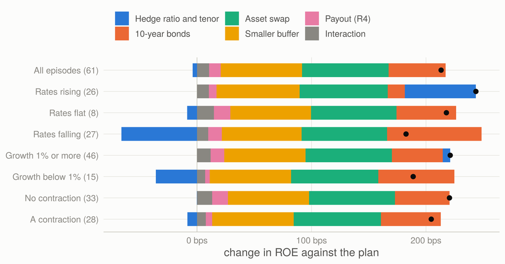

The risk-budgeted portfolio’s change in ROE against the plan by lever, averaged over the episodes in each macro regime: the policy rate’s average over the episode against the jump-off (rising or falling by more than 25 bps), average GDP growth, and whether the episode holds a contraction. Interaction: what the exact run adds beyond the levers’ separate effects (mostly R4 paying out the other levers’ earnings). Dots: the total.

**Table view: contributions by regime**

| Regime | Episodes | Hedge ratio and tenor | 10-year bonds | Asset swap | Smaller buffer | Payout (R4) | Interaction | Total | Static-only portfolio, total |
| --- | --- | --- | --- | --- | --- | --- | --- | --- | --- |
| All episodes | 61 | -4 bps | +50 bps | +76 bps | +71 bps | +10 bps | +11 bps | +213 bps | +198 bps |
| Rates rising | 26 | +62 bps | +15 bps | +77 bps | +73 bps | +7 bps | +10 bps | +244 bps | +278 bps |
| Rates flat | 8 | -9 bps | +52 bps | +75 bps | +70 bps | +14 bps | +15 bps | +218 bps | +191 bps |
| Rates falling | 27 | -66 bps | +83 bps | +75 bps | +70 bps | +12 bps | +10 bps | +183 bps | +122 bps |
| Growth 1% or more | 46 | +7 bps | +44 bps | +75 bps | +71 bps | +12 bps | +12 bps | +221 bps | +210 bps |
| Growth below 1% | 15 | -36 bps | +66 bps | +76 bps | +71 bps | +4 bps | +7 bps | +189 bps | +159 bps |
| No contraction | 33 | +0 bps | +48 bps | +75 bps | +71 bps | +14 bps | +13 bps | +220 bps | +201 bps |
| A contraction | 28 | -8 bps | +52 bps | +76 bps | +71 bps | +6 bps | +8 bps | +205 bps | +194 bps |

The portfolio has a rate-neutral core and a macro-sensitive edge.

- **The core is the two spread trades.** The asset swap adds +76 bps and the smaller buffer +71 bps, and both add the same whether rates rise or fall, growth is strong or weak, or the episode holds a contraction: one collects the fiscal premium and the other the gap between wholesale funding and bills, and neither depends on the policy path. Together they are 69% of the gain, and they use no EVE budget.
- **The edge is where duration sits.** The plan holds its duration in the receive-fixed hedge. The optimiser moves part of it into government bonds: it cuts the hedge to the rate-neutral ratio and holds ten-year bonds and longer reinvestment instead, at a similar EVE, because a ten-year bond earns the fiscal premium on top of the term premium a swap earns. The two then offset each other across the rate cycle: the smaller hedge gains +62 bps when rates rise and loses 66 bps when they fall; the bonds add +83 bps when rates fall and +15 bps when they rise. The portfolio as a whole adds +244 bps when rates rise and +183 bps when they fall, against +278 bps and +122 bps for the static-only optimum, which leans on a 20% hedge and long duration and so is a much larger bet on rising rates.
- **The payout is the one macro rule kept.** R4 adds +10 bps directly and, through the interaction, another +11 bps, by paying out more of the other levers’ earnings in good times. It adds least where growth is weak (+4 bps), which is the point: it keeps capital where the downturns are.

**Why the other rules are not chosen.** No budget picks R1, R2, R3, R6 or R7. Under binding limits a rule earns its place only if its signal predicts the premium it collects better than a fixed setting that uses the same room. R1 and R2 time the rate cycle, which the lab found does not pay. R3 earned the most of any single rule in the lab, but it trades its book: its realised losses in hiking cycles count against the tail limit, and its duration – and so the EVE budget it uses – peaks when the curve is steepest, so within a budget a fixed holding does better. R6 holds less than a fixed 50% while the spread is as tight as today’s, and R7 holds more liquidity than a fixed 160% in stress quarters – both cost income under a cap that binds. The rules’ value lies in what this engine does not price: R7’s liquidity in a run, R6’s sizing to spread risk. They belong in the ALCO’s playbook as risk triggers rather than as return engines.

## 16.6 Which levers carry the result

The best combination at an EVE budget of 5% of CET1 when the levers are restricted. Exact runs.

| Variant | Hedge ratio | Tenor | 10-year bonds | Asset swap | Buffer | Payout | ROE vs plan | 5th percentile vs plan | CET1 trough | EVE used | HQLA out of bills |
| --- | --- | --- | --- | --- | --- | --- | --- | --- | --- | --- | --- |
| Every setting | 37% | 7 years | 12.5% | 50% | LCR 160% | R4 | +213 bps | +198 bps | 11.73% | 4.6% | 89% |
| Static settings only | 20% | 10 years | 25% | 37.5% | LCR 160% | 50% | +198 bps | +159 bps | 11.68% | 3.0% | 89% |
| Hedge and payout only | 50% | 5 years | 0% | 0% | plan | R4 | +10 bps | +9 bps | 12.30% | 1.0% | 0% |
| Liquidity book only | 50% | 5 years | 0% | 50% | LCR 160% | 50% | +146 bps | +148 bps | 12.38% | 0.4% | 77% |
| Asset swap at most 25%, LCR at least 170% | 20% | 10 years | 25% | 25% | LCR 170% | 50% | +158 bps | +118 bps | 11.71% | 3.1% | 69% |
| Liquidity book capped at 70% of HQLA | 37% | 7 years | 12.5% | 25% | LCR 160% | R4 | +173 bps | +157 bps | 11.83% | 4.7% | 64% |
| Liquidity book capped at 50% of HQLA | 20% | 10 years | 25% | 0% | LCR 170% | R4 | +138 bps | +96 bps | 11.51% | 4.1% | 44% |

- **The liquidity book carries the result.** With the hedge and payout left at the plan, the liquidity book alone adds +146 bps; with the liquidity book left in bills, the hedge and the payout together add only +10 bps within the budget.
- **The answer rests on the cap and the spread appetite.** The optimiser takes the spread trades to the limits it is given, because the engine prices neither the asset swap’s spread risk beyond the modelled spread nor the liquidity a smaller buffer gives up. With the asset swap at most a quarter of HQLA and the LCR no lower than 170% the gain is +158 bps; with the liquidity book capped at 70% or 50% of earning HQLA it is +173 bps or +138 bps. Those limits are the bank’s to set – against its credit-spread risk appetite and its own liquidity stress test – and the table says what each is worth.

## 16.7 Exact runs and out of sample

Choosing on one half of the episodes and scoring on the other, at an EVE budget of 5% of CET1 (surrogate; the 11 episodes between the halves are left out). Change in average ROE against the plan in each half.

| Chosen on | Scored on | Settings | Choice | ROE vs plan, where chosen | ROE vs plan, out of sample | Best possible out of sample | Limits met out of sample |
| --- | --- | --- | --- | --- | --- | --- | --- |
| first 25 episodes | last 25 episodes | every setting | 37% · 7 years · 12.5% · 50% · LCR 160% · R4 | +203 bps | +217 bps | +220 bps | yes |
| first 25 episodes | last 25 episodes | static only | 50% · 3 years · 12.5% · 50% · LCR 160% · 50% | +186 bps | +166 bps | +220 bps | yes |
| last 25 episodes | first 25 episodes | every setting | 20% · 10 years · 25% · 37.5% · LCR 160% · 50% | +220 bps | +165 bps | +203 bps | yes |
| last 25 episodes | first 25 episodes | static only | 20% · 10 years · 25% · 37.5% · LCR 160% · 50% | +220 bps | +165 bps | +186 bps | yes |

The surrogate is within 0.03 bp of the exact engine on every chosen combination, and every one meets its limits when run exactly. Out of sample, the portfolio chosen on the first 25 episodes is the full sample’s, and on the last 25 it adds +217 bps against a best possible +220 bps. Chosen on the last 25 (episodes starting 2017Q2 to 2023Q2, which hold the 2021–23 hiking cycle), the optimiser prefers a 20% hedge reinvested at ten years with 25% of HQLA in ten-year bonds – less receive-fixed, more bonds – and on the first 25 (starting 2008Q2 to 2014Q2, which hold the 2008–09 cuts) that choice adds +165 bps against a best possible +203 bps. The rate-neutral core transfers between periods; how much duration to hold, and where, depends on the rate cycles in the sample, which is why the budget for it should be set explicitly rather than read off history.

## 16.8 Using the balance sheet itself: repo-funded carry

Before settling on the levers above, I went back through the optimiser’s options looking for an approach it had missed, something that would squeeze more NII or ROE out of the same strategy. Most candidates failed, for reasons worth recording:

- **Issuing Additional Tier 1 or Tier 2 capital** would cheapen the total capital stack, but what binds in the downside is the CET1 floor, which neither instrument counts towards.
- **Pricing deposits harder** is already among the further levers as an upper bound (+36 bps), and without a measured volume response it cannot be sized honestly.
- **Terming out wholesale funding** for the NSFR needs a term premium on bank paper that public data do not publish.
- **Repo-ing the HQLA bonds** to release cash is economically the same trade as shrinking the buffer, which the optimiser already has.
- **Redeploying HQLA into lending** is ruled out at the margin by the positioning chapter: the plan is optimal under the baseline, and the static case for more lending is a franchise question.
- **Holding the bonds at amortised cost** instead of fair value changes reported CET1 volatility, not the economics, and HQLA count at market value in the LCR either way.
- **Options on rates** need a ZAR volatility surface that is not public.
- **A one-off capital distribution** competes with R4 for the same capital room, and inside the budget R4 uses it better.

One candidate survived.

Every lever so far rearranges the balance sheet NGFB already has: a rand of bills becomes a rand of bonds, a rand of bills repays a rand of wholesale funding, a rand of profit is paid out or kept. The one resource none of them uses is the size of the balance sheet itself. A bank can buy more government bonds than its liquidity buffer needs, asset-swap them exactly as in Asset-swapped bonds, and fund them in repo against the bonds themselves. That is how South African banks hold much of their sovereign book, and it is the lever this optimiser was missing.

**What it earns.** Funded in repo rather than by displacing bills, each rand earns the bond–swap spread plus the floating leg less the repo rate: $bs + f_t - (r^{\text{repo}}_t + s^{\text{repo}})$, with $s^{\text{repo}}$ = 10 bp, the spread NGFB already pays on its repo funding. At the jump-off that is 0.58 pp a year, about 0.23 pp less than the same bond inside the buffer, because the bills it would replace yield below the policy rate while repo costs above it. It needs no HQLA (the bonds are encumbered, and secured funding against Level 1 collateral carries no LCR outflow), no EVE budget (the swap removes the rate risk) and almost no RWA (rand claims on the sovereign); it adds 5% of its size to required stable funding and all of it to the leverage exposure.

Per rand and per year,

$$\text{carry}_t \;=\; bs \;+\; f_t \;-\; \big(r^{\text{repo}}_t + s^{\text{repo}}\big) ,$$

against $bs + f_t - y^{\text{bill}}_t$ for the same asset-swapped bond inside the buffer, where it replaces a Treasury bill rather than repo funding.

**What limits it.** Three limits are added for this section: the leverage ratio (CET1 over on-balance-sheet assets, a conservative stand-in for Tier 1) must stay at or above 5% – South Africa’s minimum is 4%, and a D-SIB holds a further buffer of half its higher-loss-absorbency requirement from July 2025 – the CET1 floor must hold in the named scenarios as well as the episodes, and the book’s credit-spread risk is measured: what a 100 bps widening of the bond–swap spread would take off the bond books, after tax, as a share of CET1.

$$\text{spread risk} \;=\; \frac{100 \times \text{spread PV01} \times (1-\tau)}{\text{CET1}} ,$$

where the spread PV01 is the change in the bond books’ value for a one basis point widening of the bond–swap spread with the swap curve unchanged.

The central portfolio with a repo-funded carry book of asset-swapped 5-year government bonds added at the jump-off (exact runs; averages across the 61 episodes; the leverage ratio is the lowest quarter across the episodes and the named scenarios). Every other lever stays where the central portfolio has it.

| Carry book | ROE vs plan | vs the central portfolio | NII, 3 years, vs the central portfolio | 100 bps spread widening (% of CET1) | CET1 trough, episodes | CET1 trough, downside | Leverage ratio, lowest | Every limit met |
| --- | --- | --- | --- | --- | --- | --- | --- | --- |
| none | +213 bps | +0 bps | +R0.0 bn | 7.6% | 11.73% | 11.60% | 5.95% | yes |
| R25bn | +223 bps | +10 bps | +R0.4 bn | 8.5% | 11.70% | 11.56% | 5.85% | yes |
| R50bn | +233 bps | +20 bps | +R0.9 bn | 9.4% | 11.66% | 11.52% | 5.76% | yes |
| R75bn | +242 bps | +29 bps | +R1.3 bn | 10.4% | 11.63% | 11.47% | 5.67% | no |
| R100bn | +252 bps | +39 bps | +R1.8 bn | 11.3% | 11.59% | 11.43% | 5.58% | no |

Each R25 bn of carry book adds about 10 bps of ROE (R0.4 bn of NII over three years) and 0.9 points of CET1 to the loss from a 100 bps spread widening. It earns that in every macro regime alike, as the asset swap in the buffer does: the R100 bn book adds +38 bps when rates rise, +37 bps when they fall and +38 bps in episodes with a contraction.

None of the limits the optimiser had so far stops it. Even with R100 bn added the leverage ratio is 5.6% at its lowest, and across the episodes the CET1 floor would not bind until well beyond the largest book tested. History does hold spread widenings as large as the downside’s (0.64 pp at the worst, in the episode that replays 2020, against 0.54 pp), but not at the same time as a deep contraction and rising rates: 2020’s came with 300 bps of cuts, 2015–16’s with hikes but no deep recession, so the carry book’s loss never landed on capital already thinned by credit losses and a hedge losing money. The stagflationary downside combines all three, and that is what binds: at R75 bn its CET1 trough falls to 11.47%, below the 11.5% floor. The largest book that keeps every limit in every episode and every scenario is R50bn, which lifts the central portfolio by +20 bps to +233 bps against the plan, at the cost of raising the 100 bps spread loss from 7.6% to 9.4% of CET1.

The lesson for the risk budget is the more useful one. A limit set only on EVE, capital in replayed history and liquidity barely sees a position whose risk is the sovereign spread; the carry book walks through all three, and only a scenario built around a fiscal shock stops it. It needs its own limit – a credit-spread budget in the banking book (CSRBB) – and every point of CET1 put into that budget buys about 11 bps of ROE. Whether that is a good price is a question about the sovereign, not about NGFB: the carry is the fiscal premium, and a bank that earns more of it is more exposed to the event the premium pays for. Selling insurance is a lovely business until the claim comes in.